# Part 1-A:

Comparing the **Average Growth Rate** of various states and their **Total GDP**

Importing the relevant libraries and Reading in the data

```python
import pandas as pd
import numpy as np
import matplotlib.pyplot as plt
import seaborn as sns
```

#### Instructions for loading in the data:

All the relevant datasets have been put in the zip file named **"GDP_Assignment_Savan.zip"**.  
Please extract the same in your system in the folder of your choosing. Then follow the below instructions.

```python
import os
# This command will gove you the working directory of your system.
os.getcwd()

# Please change the path as per the hierarchy in your system:

# os.chdir('folder where the zip file has been extracted')

# In my case, the following folders were used.
# Please un-comment the above code and put in the names as per your system.
```

```
'/home/savan/Upgrad/March 2019 Cohort/GDP Assignment'
```

```python
# Reading in the dataset:
state_wise_GDP = pd.read_csv('State-wise GDP.csv')
```

Now that we have loaded the dataset, let us see how it looks like, what are all the columns, what is its shape and what datatypes are present and so on.

```python
# Shape:
state_wise_GDP.shape   # (11, 36)

# Column names and Value types:
state_wise_GDP.info()

# Overall strcuture:
state_wise_GDP
```

```
<class 'pandas.core.frame.DataFrame'>
RangeIndex: 11 entries, 0 to 10
Data columns (total 36 columns):
Items  Description           11 non-null object
Duration                     11 non-null object
Andhra Pradesh               11 non-null float64
Arunachal Pradesh            9 non-null float64
Assam                        9 non-null float64
Bihar                        9 non-null float64
Chhattisgarh                 11 non-null float64
Goa                          9 non-null float64
Gujarat                      9 non-null float64
Haryana                      11 non-null float64
Himachal Pradesh             7 non-null float64
Jammu & Kashmir              9 non-null float64
Jharkhand                    9 non-null float64
Karnataka                    9 non-null float64
Kerala                       9 non-null float64
Madhya Pradesh               11 non-null float64
Maharashtra                  7 non-null float64
Manipur                      7 non-null float64
Meghalaya                    11 non-null float64
Mizoram                      7 non-null float64
Nagaland                     7 non-null float64
Odisha                       11 non-null float64
Punjab                       7 non-null float64
Rajasthan                    7 non-null float64
Sikkim                       9 non-null float64
Tamil Nadu                   11 non-null float64
Telangana                    11 non-null float64
Tripura                      7 non-null float64
Uttar Pradesh                9 non-null float64
Uttarakhand                  9 non-null float64
West Bengal1                 0 non-null float64
Andaman & Nicobar Islands    7 non-null float64
Chandigarh                   9 non-null float64
Delhi                        11 non-null float64
Puducherry                   11 non-null float64
All_India GDP                11 non-null float64
dtypes: float64(34), object(2)
memory usage: 3.2+ KB
```

|  | Items Description | Duration | Andhra Pradesh | Arunachal Pradesh | Assam | Bihar | Chhattisgarh | Goa | Gujarat | Haryana | ... | Telangana | Tripura | Uttar Pradesh | Uttarakhand | West Bengal1 | Andaman & Nicobar Islands | Chandigarh | Delhi | Puducherry | All_India GDP |
| --- | --- | --- | --- | --- | --- | --- | --- | --- | --- | --- | --- | --- | --- | --- | --- | --- | --- | --- | --- | --- | --- |
| 0 | GSDP - CURRENT PRICES (` in Crore) | 2011-12 | 379402.00 | 11063.00 | 143175.00 | 247144.00 | 158074.00 | 42367.00 | 615606.00 | 297539.00 | ... | 359433.00 | 19208.00 | 724049.00 | 115523.00 | NaN | 3979.00 | 18768.00 | 343767.00 | 16818.00 | 8736039.00 |
| 1 | GSDP - CURRENT PRICES (` in Crore) | 2012-13 | 411404.00 | 12547.00 | 156864.00 | 282368.00 | 177511.00 | 38120.00 | 724495.00 | 347032.00 | ... | 401493.00 | 21663.00 | 822903.00 | 131835.00 | NaN | 4421.00 | 21609.00 | 391238.00 | 18875.00 | 9946636.00 |
| 2 | GSDP - CURRENT PRICES (` in Crore) | 2013-14 | 464272.00 | 14602.00 | 177745.00 | 317101.00 | 206690.00 | 35921.00 | 807623.00 | 400662.00 | ... | 452186.00 | 25593.00 | 944146.00 | 149817.00 | NaN | 5159.00 | 24787.00 | 443783.00 | 21870.00 | 11236635.00 |
| 3 | GSDP - CURRENT PRICES (` in Crore) | 2014-15 | 526468.00 | 16761.00 | 198098.00 | 373920.00 | 234982.00 | 40633.00 | 895027.00 | 437462.00 | ... | 511178.00 | 29667.00 | 1043371.00 | 161985.00 | NaN | 5721.00 | 27844.00 | 492424.00 | 24089.00 | 12433749.00 |
| 4 | GSDP - CURRENT PRICES (` in Crore) | 2015-16 | 609934.00 | 18784.00 | 224234.00 | 413503.00 | 260776.00 | 45002.00 | 994316.00 | 485184.00 | ... | 575631.00 | NaN | 1153795.00 | 184091.00 | NaN | NaN | 30304.00 | 551963.00 | 26533.00 | 13675331.00 |
| 5 | GSDP - CURRENT PRICES (` in Crore) | 2016-17 | 699307.00 | NaN | NaN | NaN | 290140.00 | NaN | NaN | 547396.00 | ... | 654294.00 | NaN | NaN | NaN | NaN | NaN | NaN | 622385.00 | 29557.00 | 15251028.00 |
| 6 | (% Growth over previous year) | 2012-13 | 8.43 | 13.41 | 9.56 | 14.25 | 12.30 | -10.02 | 17.69 | 16.63 | ... | 11.70 | 12.78 | 13.65 | 14.12 | NaN | 11.13 | 15.14 | 13.81 | 12.23 | 13.86 |
| 7 | (% Growth over previous year) | 2013-14 | 12.85 | 16.38 | 13.31 | 12.30 | 16.44 | -5.77 | 11.47 | 15.45 | ... | 12.63 | 18.14 | 14.73 | 13.64 | NaN | 16.68 | 14.71 | 13.43 | 15.87 | 12.97 |
| 8 | (% Growth over previous year) | 2014-15 | 13.40 | 14.79 | 11.45 | 17.92 | 13.69 | 13.12 | 10.82 | 9.18 | ... | 13.05 | 15.92 | 10.51 | 8.12 | NaN | 10.89 | 12.33 | 10.96 | 10.14 | 10.65 |
| 9 | (% Growth over previous year) | 2015-16 | 15.85 | 12.07 | 13.19 | 10.59 | 10.98 | 10.75 | 11.09 | 10.91 | ... | 12.61 | NaN | 10.58 | 13.65 | NaN | NaN | 8.84 | 12.09 | 10.15 | 9.99 |
| 10 | (% Growth over previous year) | 2016-17 | 14.65 | NaN | NaN | NaN | 11.26 | NaN | NaN | 12.82 | ... | 13.67 | NaN | NaN | NaN | NaN | NaN | NaN | 12.76 | 11.40 | 11.52 |

11 rows × 36 columns

The DataFrame has 36 columns which includes all the States and Union Territories of India. The observations consist of the **Total GDP** and the **Percentage Growth** for each year.

It is always a good idea to take a look at the missing values in the DataFrame so that the irrelevant and unhelpful rows and columns can be dropped.  
Finding the % of Missing data **Row-Wise**

```python
state_wise_GDP.isnull().sum(axis=1) / state_wise_GDP.shape[1] * 100
```

```
0      2.777778
1      2.777778
2      2.777778
3      2.777778
4     27.777778
5     63.888889
6      2.777778
7      2.777778
8      2.777778
9     27.777778
10    63.888889
dtype: float64
```

We can see that row index 5 and 10 have missing values pegged around **64%**.  
These rows correspond to the Data for each state in the year 2016-17.  
These are precisely the rows that we've been asked to drop in the Assessment Description.

```python
# Dropping the rows:
state_wise_GDP = state_wise_GDP[~state_wise_GDP.index.isin([5,10])]
state_wise_GDP
```

|  | Items Description | Duration | Andhra Pradesh | Arunachal Pradesh | Assam | Bihar | Chhattisgarh | Goa | Gujarat | Haryana | ... | Telangana | Tripura | Uttar Pradesh | Uttarakhand | West Bengal1 | Andaman & Nicobar Islands | Chandigarh | Delhi | Puducherry | All_India GDP |
| --- | --- | --- | --- | --- | --- | --- | --- | --- | --- | --- | --- | --- | --- | --- | --- | --- | --- | --- | --- | --- | --- |
| 0 | GSDP - CURRENT PRICES (` in Crore) | 2011-12 | 379402.00 | 11063.00 | 143175.00 | 247144.00 | 158074.00 | 42367.00 | 615606.00 | 297539.00 | ... | 359433.00 | 19208.00 | 724049.00 | 115523.00 | NaN | 3979.00 | 18768.00 | 343767.00 | 16818.00 | 8736039.00 |
| 1 | GSDP - CURRENT PRICES (` in Crore) | 2012-13 | 411404.00 | 12547.00 | 156864.00 | 282368.00 | 177511.00 | 38120.00 | 724495.00 | 347032.00 | ... | 401493.00 | 21663.00 | 822903.00 | 131835.00 | NaN | 4421.00 | 21609.00 | 391238.00 | 18875.00 | 9946636.00 |
| 2 | GSDP - CURRENT PRICES (` in Crore) | 2013-14 | 464272.00 | 14602.00 | 177745.00 | 317101.00 | 206690.00 | 35921.00 | 807623.00 | 400662.00 | ... | 452186.00 | 25593.00 | 944146.00 | 149817.00 | NaN | 5159.00 | 24787.00 | 443783.00 | 21870.00 | 11236635.00 |
| 3 | GSDP - CURRENT PRICES (` in Crore) | 2014-15 | 526468.00 | 16761.00 | 198098.00 | 373920.00 | 234982.00 | 40633.00 | 895027.00 | 437462.00 | ... | 511178.00 | 29667.00 | 1043371.00 | 161985.00 | NaN | 5721.00 | 27844.00 | 492424.00 | 24089.00 | 12433749.00 |
| 4 | GSDP - CURRENT PRICES (` in Crore) | 2015-16 | 609934.00 | 18784.00 | 224234.00 | 413503.00 | 260776.00 | 45002.00 | 994316.00 | 485184.00 | ... | 575631.00 | NaN | 1153795.00 | 184091.00 | NaN | NaN | 30304.00 | 551963.00 | 26533.00 | 13675331.00 |
| 6 | (% Growth over previous year) | 2012-13 | 8.43 | 13.41 | 9.56 | 14.25 | 12.30 | -10.02 | 17.69 | 16.63 | ... | 11.70 | 12.78 | 13.65 | 14.12 | NaN | 11.13 | 15.14 | 13.81 | 12.23 | 13.86 |
| 7 | (% Growth over previous year) | 2013-14 | 12.85 | 16.38 | 13.31 | 12.30 | 16.44 | -5.77 | 11.47 | 15.45 | ... | 12.63 | 18.14 | 14.73 | 13.64 | NaN | 16.68 | 14.71 | 13.43 | 15.87 | 12.97 |
| 8 | (% Growth over previous year) | 2014-15 | 13.40 | 14.79 | 11.45 | 17.92 | 13.69 | 13.12 | 10.82 | 9.18 | ... | 13.05 | 15.92 | 10.51 | 8.12 | NaN | 10.89 | 12.33 | 10.96 | 10.14 | 10.65 |
| 9 | (% Growth over previous year) | 2015-16 | 15.85 | 12.07 | 13.19 | 10.59 | 10.98 | 10.75 | 11.09 | 10.91 | ... | 12.61 | NaN | 10.58 | 13.65 | NaN | NaN | 8.84 | 12.09 | 10.15 | 9.99 |

9 rows × 36 columns

Now that the rows have been dropped, let us check the % of missing values in the **columns** i.e for each State and UT.

```python
state_wise_GDP.isnull().sum(axis=0) / state_wise_GDP.shape[0] * 100
```

```
Items  Description             0.000000
Duration                       0.000000
Andhra Pradesh                 0.000000
Arunachal Pradesh              0.000000
Assam                          0.000000
Bihar                          0.000000
Chhattisgarh                   0.000000
Goa                            0.000000
Gujarat                        0.000000
Haryana                        0.000000
Himachal Pradesh              22.222222
Jammu & Kashmir                0.000000
Jharkhand                      0.000000
Karnataka                      0.000000
Kerala                         0.000000
Madhya Pradesh                 0.000000
Maharashtra                   22.222222
Manipur                       22.222222
Meghalaya                      0.000000
Mizoram                       22.222222
Nagaland                      22.222222
Odisha                         0.000000
Punjab                        22.222222
Rajasthan                     22.222222
Sikkim                         0.000000
Tamil Nadu                     0.000000
Telangana                      0.000000
Tripura                       22.222222
Uttar Pradesh                  0.000000
Uttarakhand                    0.000000
West Bengal1                 100.000000
Andaman & Nicobar Islands     22.222222
Chandigarh                     0.000000
Delhi                          0.000000
Puducherry                     0.000000
All_India GDP                  0.000000
dtype: float64
```

We can see that multiple states have about **22%** of their data tagged as missing.  
However for West Bengal, the entire column is empty and hence we can safely exclude this from our DataFrame.

```python
# Dropping the column 'West Bengal1':
state_wise_GDP.drop('West Bengal1', axis='columns', inplace = True)
state_wise_GDP
```

|  | Items Description | Duration | Andhra Pradesh | Arunachal Pradesh | Assam | Bihar | Chhattisgarh | Goa | Gujarat | Haryana | ... | Tamil Nadu | Telangana | Tripura | Uttar Pradesh | Uttarakhand | Andaman & Nicobar Islands | Chandigarh | Delhi | Puducherry | All_India GDP |
| --- | --- | --- | --- | --- | --- | --- | --- | --- | --- | --- | --- | --- | --- | --- | --- | --- | --- | --- | --- | --- | --- |
| 0 | GSDP - CURRENT PRICES (` in Crore) | 2011-12 | 379402.00 | 11063.00 | 143175.00 | 247144.00 | 158074.00 | 42367.00 | 615606.00 | 297539.00 | ... | 751485.00 | 359433.00 | 19208.00 | 724049.00 | 115523.00 | 3979.00 | 18768.00 | 343767.00 | 16818.00 | 8736039.00 |
| 1 | GSDP - CURRENT PRICES (` in Crore) | 2012-13 | 411404.00 | 12547.00 | 156864.00 | 282368.00 | 177511.00 | 38120.00 | 724495.00 | 347032.00 | ... | 855481.00 | 401493.00 | 21663.00 | 822903.00 | 131835.00 | 4421.00 | 21609.00 | 391238.00 | 18875.00 | 9946636.00 |
| 2 | GSDP - CURRENT PRICES (` in Crore) | 2013-14 | 464272.00 | 14602.00 | 177745.00 | 317101.00 | 206690.00 | 35921.00 | 807623.00 | 400662.00 | ... | 971090.00 | 452186.00 | 25593.00 | 944146.00 | 149817.00 | 5159.00 | 24787.00 | 443783.00 | 21870.00 | 11236635.00 |
| 3 | GSDP - CURRENT PRICES (` in Crore) | 2014-15 | 526468.00 | 16761.00 | 198098.00 | 373920.00 | 234982.00 | 40633.00 | 895027.00 | 437462.00 | ... | 1092564.00 | 511178.00 | 29667.00 | 1043371.00 | 161985.00 | 5721.00 | 27844.00 | 492424.00 | 24089.00 | 12433749.00 |
| 4 | GSDP - CURRENT PRICES (` in Crore) | 2015-16 | 609934.00 | 18784.00 | 224234.00 | 413503.00 | 260776.00 | 45002.00 | 994316.00 | 485184.00 | ... | 1212668.00 | 575631.00 | NaN | 1153795.00 | 184091.00 | NaN | 30304.00 | 551963.00 | 26533.00 | 13675331.00 |
| 6 | (% Growth over previous year) | 2012-13 | 8.43 | 13.41 | 9.56 | 14.25 | 12.30 | -10.02 | 17.69 | 16.63 | ... | 13.84 | 11.70 | 12.78 | 13.65 | 14.12 | 11.13 | 15.14 | 13.81 | 12.23 | 13.86 |
| 7 | (% Growth over previous year) | 2013-14 | 12.85 | 16.38 | 13.31 | 12.30 | 16.44 | -5.77 | 11.47 | 15.45 | ... | 13.51 | 12.63 | 18.14 | 14.73 | 13.64 | 16.68 | 14.71 | 13.43 | 15.87 | 12.97 |
| 8 | (% Growth over previous year) | 2014-15 | 13.40 | 14.79 | 11.45 | 17.92 | 13.69 | 13.12 | 10.82 | 9.18 | ... | 12.51 | 13.05 | 15.92 | 10.51 | 8.12 | 10.89 | 12.33 | 10.96 | 10.14 | 10.65 |
| 9 | (% Growth over previous year) | 2015-16 | 15.85 | 12.07 | 13.19 | 10.59 | 10.98 | 10.75 | 11.09 | 10.91 | ... | 10.99 | 12.61 | NaN | 10.58 | 13.65 | NaN | 8.84 | 12.09 | 10.15 | 9.99 |

9 rows × 35 columns

### Average Growth of States over the duration 2013-14, 2014-15 and 2015-16

Let us take a look at all the years present in the DataFrame

```python
# The 'Duration' column contains all the years:
state_wise_GDP.Duration.value_counts()
```

```
2012-13    2
2013-14    2
2014-15    2
2015-16    2
2011-12    1
Name: Duration, dtype: int64
```

Let us also take a look at the different items in the DataFrame

```python
state_wise_GDP['Items  Description'].value_counts()
```

```
GSDP - CURRENT PRICES (` in Crore)    5
(% Growth over previous year)         4
Name: Items  Description, dtype: int64
```

We can see that we have data from **2011 to 2016** in the DataFrame.  
Also the data is divided amongst two items i.e **GDP in Crores** and **% Growth**  
Since we only need % Growth for some specific years, let us filter the DataFrame accordingly.

```python
state_wise_GDP_growth = state_wise_GDP[(state_wise_GDP['Items  Description']=='(% Growth over previous year)')
                                       &
                                       (state_wise_GDP['Duration'].isin(['2013-14', '2014-15', '2015-16']))]

state_wise_GDP_growth
```

|  | Items Description | Duration | Andhra Pradesh | Arunachal Pradesh | Assam | Bihar | Chhattisgarh | Goa | Gujarat | Haryana | ... | Tamil Nadu | Telangana | Tripura | Uttar Pradesh | Uttarakhand | Andaman & Nicobar Islands | Chandigarh | Delhi | Puducherry | All_India GDP |
| --- | --- | --- | --- | --- | --- | --- | --- | --- | --- | --- | --- | --- | --- | --- | --- | --- | --- | --- | --- | --- | --- |
| 7 | (% Growth over previous year) | 2013-14 | 12.85 | 16.38 | 13.31 | 12.30 | 16.44 | -5.77 | 11.47 | 15.45 | ... | 13.51 | 12.63 | 18.14 | 14.73 | 13.64 | 16.68 | 14.71 | 13.43 | 15.87 | 12.97 |
| 8 | (% Growth over previous year) | 2014-15 | 13.40 | 14.79 | 11.45 | 17.92 | 13.69 | 13.12 | 10.82 | 9.18 | ... | 12.51 | 13.05 | 15.92 | 10.51 | 8.12 | 10.89 | 12.33 | 10.96 | 10.14 | 10.65 |
| 9 | (% Growth over previous year) | 2015-16 | 15.85 | 12.07 | 13.19 | 10.59 | 10.98 | 10.75 | 11.09 | 10.91 | ... | 10.99 | 12.61 | NaN | 10.58 | 13.65 | NaN | 8.84 | 12.09 | 10.15 | 9.99 |

3 rows × 35 columns

Now we have a DataFrame that contains the **% Growth** of all the states for the years **2013-2016**.  
Let us find the average growth rate for all the states over the concerned duration.

```python
# Since 'Items  Description' is the column that has a common value for all the rows, let us group it by the same.
state_wise_GDP_growth = state_wise_GDP_growth.groupby('Items  Description').mean()
state_wise_GDP_growth
```

| Items Description | Andhra Pradesh | Arunachal Pradesh | Assam | Bihar | Chhattisgarh | Goa | Gujarat | Haryana | Himachal Pradesh | Jammu & Kashmir | ... | Tamil Nadu | Telangana | Tripura | Uttar Pradesh | Uttarakhand | Andaman & Nicobar Islands | Chandigarh | Delhi | Puducherry | All_India GDP |
| --- | --- | --- | --- | --- | --- | --- | --- | --- | --- | --- | --- | --- | --- | --- | --- | --- | --- | --- | --- | --- | --- |
| (% Growth over previous year) | 14.033333 | 14.413333 | 12.65 | 13.603333 | 13.703333 | 6.033333 | 11.126667 | 11.846667 | 12.28 | 10.9 | ... | 12.336667 | 12.763333 | 17.03 | 11.94 | 11.803333 | 13.785 | 11.96 | 12.16 | 12.053333 | 11.203333 |

1 rows × 33 columns

Let us reset the index so that the DataFrame can become usable

```python
state_wise_GDP_growth = state_wise_GDP_growth.reset_index()
state_wise_GDP_growth
```

|  | Items Description | Andhra Pradesh | Arunachal Pradesh | Assam | Bihar | Chhattisgarh | Goa | Gujarat | Haryana | Himachal Pradesh | ... | Tamil Nadu | Telangana | Tripura | Uttar Pradesh | Uttarakhand | Andaman & Nicobar Islands | Chandigarh | Delhi | Puducherry | All_India GDP |
| --- | --- | --- | --- | --- | --- | --- | --- | --- | --- | --- | --- | --- | --- | --- | --- | --- | --- | --- | --- | --- | --- |
| 0 | (% Growth over previous year) | 14.033333 | 14.413333 | 12.65 | 13.603333 | 13.703333 | 6.033333 | 11.126667 | 11.846667 | 12.28 | ... | 12.336667 | 12.763333 | 17.03 | 11.94 | 11.803333 | 13.785 | 11.96 | 12.16 | 12.053333 | 11.203333 |

1 rows × 34 columns

We finally have the data we wanted to plot the **% Growth rate** for each state.  
But as of now the data has one column for each state, or it is in Wide-Format, which makes it unfit for plotting.  
We need to convert the DataFrame to Long-Format

```python
state_wise_GDP_growth = pd.melt(state_wise_GDP_growth, id_vars=['Items  Description'],
                                var_name = 'State', value_name = 'Value')
state_wise_GDP_growth
```

|  | Items Description | State | Value |
| --- | --- | --- | --- |
| 0 | (% Growth over previous year) | Andhra Pradesh | 14.033333 |
| 1 | (% Growth over previous year) | Arunachal Pradesh | 14.413333 |
| 2 | (% Growth over previous year) | Assam | 12.650000 |
| 3 | (% Growth over previous year) | Bihar | 13.603333 |
| 4 | (% Growth over previous year) | Chhattisgarh | 13.703333 |
| 5 | (% Growth over previous year) | Goa | 6.033333 |
| 6 | (% Growth over previous year) | Gujarat | 11.126667 |
| 7 | (% Growth over previous year) | Haryana | 11.846667 |
| 8 | (% Growth over previous year) | Himachal Pradesh | 12.280000 |
| 9 | (% Growth over previous year) | Jammu & Kashmir | 10.900000 |
| 10 | (% Growth over previous year) | Jharkhand | 11.500000 |
| 11 | (% Growth over previous year) | Karnataka | 14.120000 |
| 12 | (% Growth over previous year) | Kerala | 12.583333 |
| 13 | (% Growth over previous year) | Madhya Pradesh | 12.626667 |
| 14 | (% Growth over previous year) | Maharashtra | 11.260000 |
| 15 | (% Growth over previous year) | Manipur | 14.610000 |
| 16 | (% Growth over previous year) | Meghalaya | 6.953333 |
| 17 | (% Growth over previous year) | Mizoram | 17.700000 |
| 18 | (% Growth over previous year) | Nagaland | 16.415000 |
| 19 | (% Growth over previous year) | Odisha | 9.836667 |
| 20 | (% Growth over previous year) | Punjab | 11.185000 |
| 21 | (% Growth over previous year) | Rajasthan | 11.320000 |
| 22 | (% Growth over previous year) | Sikkim | 10.486667 |
| 23 | (% Growth over previous year) | Tamil Nadu | 12.336667 |
| 24 | (% Growth over previous year) | Telangana | 12.763333 |
| 25 | (% Growth over previous year) | Tripura | 17.030000 |
| 26 | (% Growth over previous year) | Uttar Pradesh | 11.940000 |
| 27 | (% Growth over previous year) | Uttarakhand | 11.803333 |
| 28 | (% Growth over previous year) | Andaman & Nicobar Islands | 13.785000 |
| 29 | (% Growth over previous year) | Chandigarh | 11.960000 |
| 30 | (% Growth over previous year) | Delhi | 12.160000 |
| 31 | (% Growth over previous year) | Puducherry | 12.053333 |
| 32 | (% Growth over previous year) | All_India GDP | 11.203333 |

This data can easily be plotted now. But first let us sort the data according to the 'Value' column so that we can have a plot that is more readable and easy to consume.

```python
state_wise_GDP_growth = state_wise_GDP_growth.sort_values('Value')
state_wise_GDP_growth
```

|  | Items Description | State | Value |
| --- | --- | --- | --- |
| 5 | (% Growth over previous year) | Goa | 6.033333 |
| 16 | (% Growth over previous year) | Meghalaya | 6.953333 |
| 19 | (% Growth over previous year) | Odisha | 9.836667 |
| 22 | (% Growth over previous year) | Sikkim | 10.486667 |
| 9 | (% Growth over previous year) | Jammu & Kashmir | 10.900000 |
| 6 | (% Growth over previous year) | Gujarat | 11.126667 |
| 20 | (% Growth over previous year) | Punjab | 11.185000 |
| 32 | (% Growth over previous year) | All_India GDP | 11.203333 |
| 14 | (% Growth over previous year) | Maharashtra | 11.260000 |
| 21 | (% Growth over previous year) | Rajasthan | 11.320000 |
| 10 | (% Growth over previous year) | Jharkhand | 11.500000 |
| 27 | (% Growth over previous year) | Uttarakhand | 11.803333 |
| 7 | (% Growth over previous year) | Haryana | 11.846667 |
| 26 | (% Growth over previous year) | Uttar Pradesh | 11.940000 |
| 29 | (% Growth over previous year) | Chandigarh | 11.960000 |
| 31 | (% Growth over previous year) | Puducherry | 12.053333 |
| 30 | (% Growth over previous year) | Delhi | 12.160000 |
| 8 | (% Growth over previous year) | Himachal Pradesh | 12.280000 |
| 23 | (% Growth over previous year) | Tamil Nadu | 12.336667 |
| 12 | (% Growth over previous year) | Kerala | 12.583333 |
| 13 | (% Growth over previous year) | Madhya Pradesh | 12.626667 |
| 2 | (% Growth over previous year) | Assam | 12.650000 |
| 24 | (% Growth over previous year) | Telangana | 12.763333 |
| 3 | (% Growth over previous year) | Bihar | 13.603333 |
| 4 | (% Growth over previous year) | Chhattisgarh | 13.703333 |
| 28 | (% Growth over previous year) | Andaman & Nicobar Islands | 13.785000 |
| 0 | (% Growth over previous year) | Andhra Pradesh | 14.033333 |
| 11 | (% Growth over previous year) | Karnataka | 14.120000 |
| 1 | (% Growth over previous year) | Arunachal Pradesh | 14.413333 |
| 15 | (% Growth over previous year) | Manipur | 14.610000 |
| 18 | (% Growth over previous year) | Nagaland | 16.415000 |
| 25 | (% Growth over previous year) | Tripura | 17.030000 |
| 17 | (% Growth over previous year) | Mizoram | 17.700000 |

Taking a look at the newly obtained DataFrame, we see that the indices are out of order because of the sorting.  
We'll need proper indexing in order to slice and dice the data in the future, let us therefore **reset the index**.

```python
state_wise_GDP_growth = state_wise_GDP_growth.reset_index(drop = True)
state_wise_GDP_growth
```

|  | Items Description | State | Value |
| --- | --- | --- | --- |
| 0 | (% Growth over previous year) | Goa | 6.033333 |
| 1 | (% Growth over previous year) | Meghalaya | 6.953333 |
| 2 | (% Growth over previous year) | Odisha | 9.836667 |
| 3 | (% Growth over previous year) | Sikkim | 10.486667 |
| 4 | (% Growth over previous year) | Jammu & Kashmir | 10.900000 |
| 5 | (% Growth over previous year) | Gujarat | 11.126667 |
| 6 | (% Growth over previous year) | Punjab | 11.185000 |
| 7 | (% Growth over previous year) | All_India GDP | 11.203333 |
| 8 | (% Growth over previous year) | Maharashtra | 11.260000 |
| 9 | (% Growth over previous year) | Rajasthan | 11.320000 |
| 10 | (% Growth over previous year) | Jharkhand | 11.500000 |
| 11 | (% Growth over previous year) | Uttarakhand | 11.803333 |
| 12 | (% Growth over previous year) | Haryana | 11.846667 |
| 13 | (% Growth over previous year) | Uttar Pradesh | 11.940000 |
| 14 | (% Growth over previous year) | Chandigarh | 11.960000 |
| 15 | (% Growth over previous year) | Puducherry | 12.053333 |
| 16 | (% Growth over previous year) | Delhi | 12.160000 |
| 17 | (% Growth over previous year) | Himachal Pradesh | 12.280000 |
| 18 | (% Growth over previous year) | Tamil Nadu | 12.336667 |
| 19 | (% Growth over previous year) | Kerala | 12.583333 |
| 20 | (% Growth over previous year) | Madhya Pradesh | 12.626667 |
| 21 | (% Growth over previous year) | Assam | 12.650000 |
| 22 | (% Growth over previous year) | Telangana | 12.763333 |
| 23 | (% Growth over previous year) | Bihar | 13.603333 |
| 24 | (% Growth over previous year) | Chhattisgarh | 13.703333 |
| 25 | (% Growth over previous year) | Andaman & Nicobar Islands | 13.785000 |
| 26 | (% Growth over previous year) | Andhra Pradesh | 14.033333 |
| 27 | (% Growth over previous year) | Karnataka | 14.120000 |
| 28 | (% Growth over previous year) | Arunachal Pradesh | 14.413333 |
| 29 | (% Growth over previous year) | Manipur | 14.610000 |
| 30 | (% Growth over previous year) | Nagaland | 16.415000 |
| 31 | (% Growth over previous year) | Tripura | 17.030000 |
| 32 | (% Growth over previous year) | Mizoram | 17.700000 |

Now that everything is ready, let us begin plotting

```
Text(0.5,1,'Average % Growth Rate of Indian States in the years 2013-2016')
```

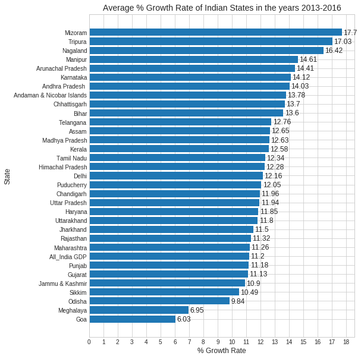

```python
# Defining the Figure size and the Plot Style:
plt.figure(figsize=(8,10))
plt.style.use('seaborn-whitegrid')

# Defining the elements of X and Y Axes:
x = state_wise_GDP_growth['State']
y = state_wise_GDP_growth['Value']

# We'll need a horizontal Barplot in order to accomodate the States' string length, a vertical plot
# would simply be unreadable.
plt.barh(x, y)

# Defining the ticks on the X-axis, this is done in order to annotate the plot later on.
plt.xticks([0,1,2,3,4,5,6,7,8,9,10,11,12,13,14,15,16,17,18])

# Defining the custom formatting for the text on the plot:
fonts = {'size' : 12}

# Annotating the plot, i.e putting '%' on top of each bar to make it more consumable.
for i in state_wise_GDP_growth['Value'].index:
    plt.annotate(str(state_wise_GDP_growth['Value'][i].round(2)), (state_wise_GDP_growth['Value'][i] + 0.10,i-0.25),
                **fonts)

# Labelling the axes and the plot:
plt.xlabel('% Growth Rate', **fonts)
plt.ylabel('State', **fonts)
fonts_1 = {'size' : 14}
plt.title('Average % Growth Rate of Indian States in the years 2013-2016', **fonts_1)
```

The top 5 states with the highest average GDP growth over the duration 2013-16 are all North-Eastern states which include:

1. Mizoram (17.7%)
2. Tripura(17%)
3. Nagaland(16.5%)
4. Manipur(14.5%)
5. Arunachal Pradesh(14.5%)  
   Their combined Average Growth is pegged around 16% which is significantly higher than the national average of 11.2%.

On the other hand, states including:

1. Goa (6%)
2. Meghalaya (7%)
3. Odisha (9.8%)
4. Sikkim (10.5%)
5. Jammu and Kashmir (11%)

are at the lower rung of the ladder. However it can be noted that in reality only 3 states have a GDP Growth considerably lower than the national average of 11%. These include Goa, Meghalaya, and Odisha.  
As seen above the top 5 fastest growing states are from the North-East region, however states like Meghalaya and Sikkim which are among the worst performers also belong to the same geographical region.

Average Growth Rate for my home state (**Madhya Pradesh**):  
It stands around **12.5%** which is better than the national average of **11%**. Since it is primarily an agro-based economy with 30% forest cover, the agricultural policies implemented at that time by the then CM could be one of the reasons behind high growth.

The private investments in upcoming metropolitan cities like Indore in sectors such as Pharma and the IT could have a major role in the high growth rate.

The Simhasth Kumbh mela in Ujjain held in 2016 might also be responsible for giving the small and medium businesses such as local travel companies, skilled handicraft workers and local hotel owners a major boost in their annual turnover for that year resulting in a higher growth rate.

### Total GDP of all States (GSDP):

```python
state_wise_GDP
```

|  | Items Description | Duration | Andhra Pradesh | Arunachal Pradesh | Assam | Bihar | Chhattisgarh | Goa | Gujarat | Haryana | ... | Tamil Nadu | Telangana | Tripura | Uttar Pradesh | Uttarakhand | Andaman & Nicobar Islands | Chandigarh | Delhi | Puducherry | All_India GDP |
| --- | --- | --- | --- | --- | --- | --- | --- | --- | --- | --- | --- | --- | --- | --- | --- | --- | --- | --- | --- | --- | --- |
| 0 | GSDP - CURRENT PRICES (` in Crore) | 2011-12 | 379402.00 | 11063.00 | 143175.00 | 247144.00 | 158074.00 | 42367.00 | 615606.00 | 297539.00 | ... | 751485.00 | 359433.00 | 19208.00 | 724049.00 | 115523.00 | 3979.00 | 18768.00 | 343767.00 | 16818.00 | 8736039.00 |
| 1 | GSDP - CURRENT PRICES (` in Crore) | 2012-13 | 411404.00 | 12547.00 | 156864.00 | 282368.00 | 177511.00 | 38120.00 | 724495.00 | 347032.00 | ... | 855481.00 | 401493.00 | 21663.00 | 822903.00 | 131835.00 | 4421.00 | 21609.00 | 391238.00 | 18875.00 | 9946636.00 |
| 2 | GSDP - CURRENT PRICES (` in Crore) | 2013-14 | 464272.00 | 14602.00 | 177745.00 | 317101.00 | 206690.00 | 35921.00 | 807623.00 | 400662.00 | ... | 971090.00 | 452186.00 | 25593.00 | 944146.00 | 149817.00 | 5159.00 | 24787.00 | 443783.00 | 21870.00 | 11236635.00 |
| 3 | GSDP - CURRENT PRICES (` in Crore) | 2014-15 | 526468.00 | 16761.00 | 198098.00 | 373920.00 | 234982.00 | 40633.00 | 895027.00 | 437462.00 | ... | 1092564.00 | 511178.00 | 29667.00 | 1043371.00 | 161985.00 | 5721.00 | 27844.00 | 492424.00 | 24089.00 | 12433749.00 |
| 4 | GSDP - CURRENT PRICES (` in Crore) | 2015-16 | 609934.00 | 18784.00 | 224234.00 | 413503.00 | 260776.00 | 45002.00 | 994316.00 | 485184.00 | ... | 1212668.00 | 575631.00 | NaN | 1153795.00 | 184091.00 | NaN | 30304.00 | 551963.00 | 26533.00 | 13675331.00 |
| 6 | (% Growth over previous year) | 2012-13 | 8.43 | 13.41 | 9.56 | 14.25 | 12.30 | -10.02 | 17.69 | 16.63 | ... | 13.84 | 11.70 | 12.78 | 13.65 | 14.12 | 11.13 | 15.14 | 13.81 | 12.23 | 13.86 |
| 7 | (% Growth over previous year) | 2013-14 | 12.85 | 16.38 | 13.31 | 12.30 | 16.44 | -5.77 | 11.47 | 15.45 | ... | 13.51 | 12.63 | 18.14 | 14.73 | 13.64 | 16.68 | 14.71 | 13.43 | 15.87 | 12.97 |
| 8 | (% Growth over previous year) | 2014-15 | 13.40 | 14.79 | 11.45 | 17.92 | 13.69 | 13.12 | 10.82 | 9.18 | ... | 12.51 | 13.05 | 15.92 | 10.51 | 8.12 | 10.89 | 12.33 | 10.96 | 10.14 | 10.65 |
| 9 | (% Growth over previous year) | 2015-16 | 15.85 | 12.07 | 13.19 | 10.59 | 10.98 | 10.75 | 11.09 | 10.91 | ... | 10.99 | 12.61 | NaN | 10.58 | 13.65 | NaN | 8.84 | 12.09 | 10.15 | 9.99 |

9 rows × 35 columns

Since we are only concerned with the Total GDP, let us filter out the unwanted rows pertaining to the Growth Rate from our DataFrame

```python
state_wise_total_GDP = state_wise_GDP[state_wise_GDP['Items  Description']=='GSDP - CURRENT PRICES (` in Crore)']
state_wise_total_GDP
```

|  | Items Description | Duration | Andhra Pradesh | Arunachal Pradesh | Assam | Bihar | Chhattisgarh | Goa | Gujarat | Haryana | ... | Tamil Nadu | Telangana | Tripura | Uttar Pradesh | Uttarakhand | Andaman & Nicobar Islands | Chandigarh | Delhi | Puducherry | All_India GDP |
| --- | --- | --- | --- | --- | --- | --- | --- | --- | --- | --- | --- | --- | --- | --- | --- | --- | --- | --- | --- | --- | --- |
| 0 | GSDP - CURRENT PRICES (` in Crore) | 2011-12 | 379402.0 | 11063.0 | 143175.0 | 247144.0 | 158074.0 | 42367.0 | 615606.0 | 297539.0 | ... | 751485.0 | 359433.0 | 19208.0 | 724049.0 | 115523.0 | 3979.0 | 18768.0 | 343767.0 | 16818.0 | 8736039.0 |
| 1 | GSDP - CURRENT PRICES (` in Crore) | 2012-13 | 411404.0 | 12547.0 | 156864.0 | 282368.0 | 177511.0 | 38120.0 | 724495.0 | 347032.0 | ... | 855481.0 | 401493.0 | 21663.0 | 822903.0 | 131835.0 | 4421.0 | 21609.0 | 391238.0 | 18875.0 | 9946636.0 |
| 2 | GSDP - CURRENT PRICES (` in Crore) | 2013-14 | 464272.0 | 14602.0 | 177745.0 | 317101.0 | 206690.0 | 35921.0 | 807623.0 | 400662.0 | ... | 971090.0 | 452186.0 | 25593.0 | 944146.0 | 149817.0 | 5159.0 | 24787.0 | 443783.0 | 21870.0 | 11236635.0 |
| 3 | GSDP - CURRENT PRICES (` in Crore) | 2014-15 | 526468.0 | 16761.0 | 198098.0 | 373920.0 | 234982.0 | 40633.0 | 895027.0 | 437462.0 | ... | 1092564.0 | 511178.0 | 29667.0 | 1043371.0 | 161985.0 | 5721.0 | 27844.0 | 492424.0 | 24089.0 | 12433749.0 |
| 4 | GSDP - CURRENT PRICES (` in Crore) | 2015-16 | 609934.0 | 18784.0 | 224234.0 | 413503.0 | 260776.0 | 45002.0 | 994316.0 | 485184.0 | ... | 1212668.0 | 575631.0 | NaN | 1153795.0 | 184091.0 | NaN | 30304.0 | 551963.0 | 26533.0 | 13675331.0 |

5 rows × 35 columns

Since the data is present for multiple years, it is better to have knowledge of any missing data for each of the years.

```python
state_wise_total_GDP.isnull().sum(axis = 1)
```

```
0    0
1    0
2    0
3    0
4    9
dtype: int64
```

It is clear that rows corresponding to the year 2011-2015 have no missing data, however over the duration 2015-16, we do not have data for 9 states which will significantly affect the analysis.

#### Calculating the Average GDP over the duration 2011-2015

```python
total_GDP_2011_15 = state_wise_total_GDP[state_wise_total_GDP['Duration'] != '2015-16']
total_GDP_2011_15
```

|  | Items Description | Duration | Andhra Pradesh | Arunachal Pradesh | Assam | Bihar | Chhattisgarh | Goa | Gujarat | Haryana | ... | Tamil Nadu | Telangana | Tripura | Uttar Pradesh | Uttarakhand | Andaman & Nicobar Islands | Chandigarh | Delhi | Puducherry | All_India GDP |
| --- | --- | --- | --- | --- | --- | --- | --- | --- | --- | --- | --- | --- | --- | --- | --- | --- | --- | --- | --- | --- | --- |
| 0 | GSDP - CURRENT PRICES (` in Crore) | 2011-12 | 379402.0 | 11063.0 | 143175.0 | 247144.0 | 158074.0 | 42367.0 | 615606.0 | 297539.0 | ... | 751485.0 | 359433.0 | 19208.0 | 724049.0 | 115523.0 | 3979.0 | 18768.0 | 343767.0 | 16818.0 | 8736039.0 |
| 1 | GSDP - CURRENT PRICES (` in Crore) | 2012-13 | 411404.0 | 12547.0 | 156864.0 | 282368.0 | 177511.0 | 38120.0 | 724495.0 | 347032.0 | ... | 855481.0 | 401493.0 | 21663.0 | 822903.0 | 131835.0 | 4421.0 | 21609.0 | 391238.0 | 18875.0 | 9946636.0 |
| 2 | GSDP - CURRENT PRICES (` in Crore) | 2013-14 | 464272.0 | 14602.0 | 177745.0 | 317101.0 | 206690.0 | 35921.0 | 807623.0 | 400662.0 | ... | 971090.0 | 452186.0 | 25593.0 | 944146.0 | 149817.0 | 5159.0 | 24787.0 | 443783.0 | 21870.0 | 11236635.0 |
| 3 | GSDP - CURRENT PRICES (` in Crore) | 2014-15 | 526468.0 | 16761.0 | 198098.0 | 373920.0 | 234982.0 | 40633.0 | 895027.0 | 437462.0 | ... | 1092564.0 | 511178.0 | 29667.0 | 1043371.0 | 161985.0 | 5721.0 | 27844.0 | 492424.0 | 24089.0 | 12433749.0 |

4 rows × 35 columns

Now that we have our DataFrame only for the years 2011-15, let us calculate the average

```python
total_GDP_2011_15 = total_GDP_2011_15.groupby('Items  Description').mean()
total_GDP_2011_15
```

| Items Description | Andhra Pradesh | Arunachal Pradesh | Assam | Bihar | Chhattisgarh | Goa | Gujarat | Haryana | Himachal Pradesh | Jammu & Kashmir | ... | Tamil Nadu | Telangana | Tripura | Uttar Pradesh | Uttarakhand | Andaman & Nicobar Islands | Chandigarh | Delhi | Puducherry | All_India GDP |
| --- | --- | --- | --- | --- | --- | --- | --- | --- | --- | --- | --- | --- | --- | --- | --- | --- | --- | --- | --- | --- | --- |
| GSDP - CURRENT PRICES (` in Crore) | 445386.5 | 13743.25 | 168970.5 | 305133.25 | 194314.25 | 39260.25 | 760687.75 | 370673.75 | 88668.25 | 90414.0 | ... | 917655.0 | 431072.5 | 24032.75 | 883617.25 | 139790.0 | 4820.0 | 23252.0 | 417803.0 | 20413.0 | 10588264.75 |

1 rows × 33 columns

```python
# Resetting the index to make the DataFrame usable:
total_GDP_2011_15 = total_GDP_2011_15.reset_index()
total_GDP_2011_15
```

|  | Items Description | Andhra Pradesh | Arunachal Pradesh | Assam | Bihar | Chhattisgarh | Goa | Gujarat | Haryana | Himachal Pradesh | ... | Tamil Nadu | Telangana | Tripura | Uttar Pradesh | Uttarakhand | Andaman & Nicobar Islands | Chandigarh | Delhi | Puducherry | All_India GDP |
| --- | --- | --- | --- | --- | --- | --- | --- | --- | --- | --- | --- | --- | --- | --- | --- | --- | --- | --- | --- | --- | --- |
| 0 | GSDP - CURRENT PRICES (` in Crore) | 445386.5 | 13743.25 | 168970.5 | 305133.25 | 194314.25 | 39260.25 | 760687.75 | 370673.75 | 88668.25 | ... | 917655.0 | 431072.5 | 24032.75 | 883617.25 | 139790.0 | 4820.0 | 23252.0 | 417803.0 | 20413.0 | 10588264.75 |

1 rows × 34 columns

Converting the data to Long-Format so that it is easy to plot

```python
total_GDP_2011_15 = pd.melt(total_GDP_2011_15, id_vars = ['Items  Description'],
                            var_name = 'State', value_name = 'Value')
total_GDP_2011_15
```

|  | Items Description | State | Value |
| --- | --- | --- | --- |
| 0 | GSDP - CURRENT PRICES (` in Crore) | Andhra Pradesh | 445386.50 |
| 1 | GSDP - CURRENT PRICES (` in Crore) | Arunachal Pradesh | 13743.25 |
| 2 | GSDP - CURRENT PRICES (` in Crore) | Assam | 168970.50 |
| 3 | GSDP - CURRENT PRICES (` in Crore) | Bihar | 305133.25 |
| 4 | GSDP - CURRENT PRICES (` in Crore) | Chhattisgarh | 194314.25 |
| 5 | GSDP - CURRENT PRICES (` in Crore) | Goa | 39260.25 |
| 6 | GSDP - CURRENT PRICES (` in Crore) | Gujarat | 760687.75 |
| 7 | GSDP - CURRENT PRICES (` in Crore) | Haryana | 370673.75 |
| 8 | GSDP - CURRENT PRICES (` in Crore) | Himachal Pradesh | 88668.25 |
| 9 | GSDP - CURRENT PRICES (` in Crore) | Jammu & Kashmir | 90414.00 |
| 10 | GSDP - CURRENT PRICES (` in Crore) | Jharkhand | 182829.00 |
| 11 | GSDP - CURRENT PRICES (` in Crore) | Karnataka | 758788.00 |
| 12 | GSDP - CURRENT PRICES (` in Crore) | Kerala | 441851.00 |
| 13 | GSDP - CURRENT PRICES (` in Crore) | Madhya Pradesh | 404051.00 |
| 14 | GSDP - CURRENT PRICES (` in Crore) | Maharashtra | 1540265.25 |
| 15 | GSDP - CURRENT PRICES (` in Crore) | Manipur | 15226.00 |
| 16 | GSDP - CURRENT PRICES (` in Crore) | Meghalaya | 22284.00 |
| 17 | GSDP - CURRENT PRICES (` in Crore) | Mizoram | 9368.25 |
| 18 | GSDP - CURRENT PRICES (` in Crore) | Nagaland | 15121.00 |
| 19 | GSDP - CURRENT PRICES (` in Crore) | Odisha | 274956.75 |
| 20 | GSDP - CURRENT PRICES (` in Crore) | Punjab | 316771.75 |
| 21 | GSDP - CURRENT PRICES (` in Crore) | Rajasthan | 523091.00 |
| 22 | GSDP - CURRENT PRICES (` in Crore) | Sikkim | 13143.50 |
| 23 | GSDP - CURRENT PRICES (` in Crore) | Tamil Nadu | 917655.00 |
| 24 | GSDP - CURRENT PRICES (` in Crore) | Telangana | 431072.50 |
| 25 | GSDP - CURRENT PRICES (` in Crore) | Tripura | 24032.75 |
| 26 | GSDP - CURRENT PRICES (` in Crore) | Uttar Pradesh | 883617.25 |
| 27 | GSDP - CURRENT PRICES (` in Crore) | Uttarakhand | 139790.00 |
| 28 | GSDP - CURRENT PRICES (` in Crore) | Andaman & Nicobar Islands | 4820.00 |
| 29 | GSDP - CURRENT PRICES (` in Crore) | Chandigarh | 23252.00 |
| 30 | GSDP - CURRENT PRICES (` in Crore) | Delhi | 417803.00 |
| 31 | GSDP - CURRENT PRICES (` in Crore) | Puducherry | 20413.00 |
| 32 | GSDP - CURRENT PRICES (` in Crore) | All_India GDP | 10588264.75 |

```python
# Sorting the Values:
total_GDP_2011_15 = total_GDP_2011_15.sort_values('Value')

# Resetting the index:
total_GDP_2011_15 = total_GDP_2011_15.reset_index(drop = True)
total_GDP_2011_15
```

|  | Items Description | State | Value |
| --- | --- | --- | --- |
| 0 | GSDP - CURRENT PRICES (` in Crore) | Andaman & Nicobar Islands | 4820.00 |
| 1 | GSDP - CURRENT PRICES (` in Crore) | Mizoram | 9368.25 |
| 2 | GSDP - CURRENT PRICES (` in Crore) | Sikkim | 13143.50 |
| 3 | GSDP - CURRENT PRICES (` in Crore) | Arunachal Pradesh | 13743.25 |
| 4 | GSDP - CURRENT PRICES (` in Crore) | Nagaland | 15121.00 |
| 5 | GSDP - CURRENT PRICES (` in Crore) | Manipur | 15226.00 |
| 6 | GSDP - CURRENT PRICES (` in Crore) | Puducherry | 20413.00 |
| 7 | GSDP - CURRENT PRICES (` in Crore) | Meghalaya | 22284.00 |
| 8 | GSDP - CURRENT PRICES (` in Crore) | Chandigarh | 23252.00 |
| 9 | GSDP - CURRENT PRICES (` in Crore) | Tripura | 24032.75 |
| 10 | GSDP - CURRENT PRICES (` in Crore) | Goa | 39260.25 |
| 11 | GSDP - CURRENT PRICES (` in Crore) | Himachal Pradesh | 88668.25 |
| 12 | GSDP - CURRENT PRICES (` in Crore) | Jammu & Kashmir | 90414.00 |
| 13 | GSDP - CURRENT PRICES (` in Crore) | Uttarakhand | 139790.00 |
| 14 | GSDP - CURRENT PRICES (` in Crore) | Assam | 168970.50 |
| 15 | GSDP - CURRENT PRICES (` in Crore) | Jharkhand | 182829.00 |
| 16 | GSDP - CURRENT PRICES (` in Crore) | Chhattisgarh | 194314.25 |
| 17 | GSDP - CURRENT PRICES (` in Crore) | Odisha | 274956.75 |
| 18 | GSDP - CURRENT PRICES (` in Crore) | Bihar | 305133.25 |
| 19 | GSDP - CURRENT PRICES (` in Crore) | Punjab | 316771.75 |
| 20 | GSDP - CURRENT PRICES (` in Crore) | Haryana | 370673.75 |
| 21 | GSDP - CURRENT PRICES (` in Crore) | Madhya Pradesh | 404051.00 |
| 22 | GSDP - CURRENT PRICES (` in Crore) | Delhi | 417803.00 |
| 23 | GSDP - CURRENT PRICES (` in Crore) | Telangana | 431072.50 |
| 24 | GSDP - CURRENT PRICES (` in Crore) | Kerala | 441851.00 |
| 25 | GSDP - CURRENT PRICES (` in Crore) | Andhra Pradesh | 445386.50 |
| 26 | GSDP - CURRENT PRICES (` in Crore) | Rajasthan | 523091.00 |
| 27 | GSDP - CURRENT PRICES (` in Crore) | Karnataka | 758788.00 |
| 28 | GSDP - CURRENT PRICES (` in Crore) | Gujarat | 760687.75 |
| 29 | GSDP - CURRENT PRICES (` in Crore) | Uttar Pradesh | 883617.25 |
| 30 | GSDP - CURRENT PRICES (` in Crore) | Tamil Nadu | 917655.00 |
| 31 | GSDP - CURRENT PRICES (` in Crore) | Maharashtra | 1540265.25 |
| 32 | GSDP - CURRENT PRICES (` in Crore) | All_India GDP | 10588264.75 |

Now the data is ready to be plotted.

```
Text(0.5,1,'Average volume of GDP over the duration 2011-15')
```

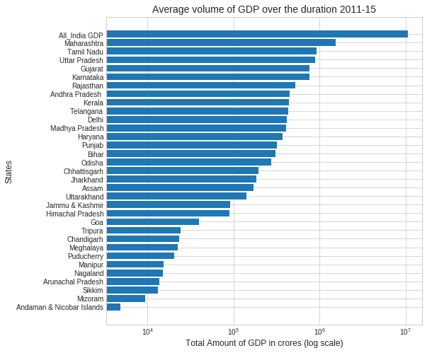

```python
# Setting the figure size:
plt.figure(figsize = (8,8))

# Defining axes:
x = total_GDP_2011_15['Value']
y = total_GDP_2011_15['State']
plt.barh(y,x)

# Since the spread of the data is high, X-axis can be taken on a log scale to make the plot more readable
plt.xscale('log')

# Defining the labels and the title of the plot:
fonts = {'size' : 12}
plt.xlabel('Total Amount of GDP in crores (log scale)', **fonts)
plt.ylabel('States', **fonts)

fonts_1 = {'size' : 14}
plt.title('Average volume of GDP over the duration 2011-15', **fonts_1)
```

The top performing states as far as the Average GDP is concerned come as no surprise. These include:

1. Maharshtra
2. Tamil Nadu
3. Uttar Pradesh
4. Gujarat
5. Karnataka

We can also conclude that the states which have shown the fastest growth rates are mostly the states with low volume of Total GDP and hence even a small change in it could lead to a higher growth rate.  
Whereas states like Maharashtra, Tamil Nadu, UP and Kerala have growth rates that go hand in hand with the National Average, which makes sense since these states are responsible for driving the national growth. Even a large growth in the Total GDP year on year would lead to a lesser growth rate for these states.

##### Total GDP of all the states for the year 2015-16:

```python
# Looking at the original DataFrame:
state_wise_GDP
```

|  | Items Description | Duration | Andhra Pradesh | Arunachal Pradesh | Assam | Bihar | Chhattisgarh | Goa | Gujarat | Haryana | ... | Tamil Nadu | Telangana | Tripura | Uttar Pradesh | Uttarakhand | Andaman & Nicobar Islands | Chandigarh | Delhi | Puducherry | All_India GDP |
| --- | --- | --- | --- | --- | --- | --- | --- | --- | --- | --- | --- | --- | --- | --- | --- | --- | --- | --- | --- | --- | --- |
| 0 | GSDP - CURRENT PRICES (` in Crore) | 2011-12 | 379402.00 | 11063.00 | 143175.00 | 247144.00 | 158074.00 | 42367.00 | 615606.00 | 297539.00 | ... | 751485.00 | 359433.00 | 19208.00 | 724049.00 | 115523.00 | 3979.00 | 18768.00 | 343767.00 | 16818.00 | 8736039.00 |
| 1 | GSDP - CURRENT PRICES (` in Crore) | 2012-13 | 411404.00 | 12547.00 | 156864.00 | 282368.00 | 177511.00 | 38120.00 | 724495.00 | 347032.00 | ... | 855481.00 | 401493.00 | 21663.00 | 822903.00 | 131835.00 | 4421.00 | 21609.00 | 391238.00 | 18875.00 | 9946636.00 |
| 2 | GSDP - CURRENT PRICES (` in Crore) | 2013-14 | 464272.00 | 14602.00 | 177745.00 | 317101.00 | 206690.00 | 35921.00 | 807623.00 | 400662.00 | ... | 971090.00 | 452186.00 | 25593.00 | 944146.00 | 149817.00 | 5159.00 | 24787.00 | 443783.00 | 21870.00 | 11236635.00 |
| 3 | GSDP - CURRENT PRICES (` in Crore) | 2014-15 | 526468.00 | 16761.00 | 198098.00 | 373920.00 | 234982.00 | 40633.00 | 895027.00 | 437462.00 | ... | 1092564.00 | 511178.00 | 29667.00 | 1043371.00 | 161985.00 | 5721.00 | 27844.00 | 492424.00 | 24089.00 | 12433749.00 |
| 4 | GSDP - CURRENT PRICES (` in Crore) | 2015-16 | 609934.00 | 18784.00 | 224234.00 | 413503.00 | 260776.00 | 45002.00 | 994316.00 | 485184.00 | ... | 1212668.00 | 575631.00 | NaN | 1153795.00 | 184091.00 | NaN | 30304.00 | 551963.00 | 26533.00 | 13675331.00 |
| 6 | (% Growth over previous year) | 2012-13 | 8.43 | 13.41 | 9.56 | 14.25 | 12.30 | -10.02 | 17.69 | 16.63 | ... | 13.84 | 11.70 | 12.78 | 13.65 | 14.12 | 11.13 | 15.14 | 13.81 | 12.23 | 13.86 |
| 7 | (% Growth over previous year) | 2013-14 | 12.85 | 16.38 | 13.31 | 12.30 | 16.44 | -5.77 | 11.47 | 15.45 | ... | 13.51 | 12.63 | 18.14 | 14.73 | 13.64 | 16.68 | 14.71 | 13.43 | 15.87 | 12.97 |
| 8 | (% Growth over previous year) | 2014-15 | 13.40 | 14.79 | 11.45 | 17.92 | 13.69 | 13.12 | 10.82 | 9.18 | ... | 12.51 | 13.05 | 15.92 | 10.51 | 8.12 | 10.89 | 12.33 | 10.96 | 10.14 | 10.65 |
| 9 | (% Growth over previous year) | 2015-16 | 15.85 | 12.07 | 13.19 | 10.59 | 10.98 | 10.75 | 11.09 | 10.91 | ... | 10.99 | 12.61 | NaN | 10.58 | 13.65 | NaN | 8.84 | 12.09 | 10.15 | 9.99 |

9 rows × 35 columns

```python
# Filtering the row for Total GDP for the year 2015-16:
total_GDP_2015_16 = state_wise_GDP[(state_wise_GDP['Items  Description']=='GSDP - CURRENT PRICES (` in Crore)')
                                  &
                                  (state_wise_GDP['Duration']=='2015-16')]

# Resetting the index:
total_GDP_2015_16 = total_GDP_2015_16.reset_index(drop = True)
total_GDP_2015_16
```

|  | Items Description | Duration | Andhra Pradesh | Arunachal Pradesh | Assam | Bihar | Chhattisgarh | Goa | Gujarat | Haryana | ... | Tamil Nadu | Telangana | Tripura | Uttar Pradesh | Uttarakhand | Andaman & Nicobar Islands | Chandigarh | Delhi | Puducherry | All_India GDP |
| --- | --- | --- | --- | --- | --- | --- | --- | --- | --- | --- | --- | --- | --- | --- | --- | --- | --- | --- | --- | --- | --- |
| 0 | GSDP - CURRENT PRICES (` in Crore) | 2015-16 | 609934.0 | 18784.0 | 224234.0 | 413503.0 | 260776.0 | 45002.0 | 994316.0 | 485184.0 | ... | 1212668.0 | 575631.0 | NaN | 1153795.0 | 184091.0 | NaN | 30304.0 | 551963.0 | 26533.0 | 13675331.0 |

1 rows × 35 columns

Again, let us convert the DataFrame to Long-Format:

```python
total_GDP_2015_16 = pd.melt(total_GDP_2015_16, id_vars = ['Items  Description'],
                            var_name = 'State', value_name = 'Value' )

total_GDP_2015_16
```

|  | Items Description | State | Value |
| --- | --- | --- | --- |
| 0 | GSDP - CURRENT PRICES (` in Crore) | Duration | 2015-16 |
| 1 | GSDP - CURRENT PRICES (` in Crore) | Andhra Pradesh | 609934 |
| 2 | GSDP - CURRENT PRICES (` in Crore) | Arunachal Pradesh | 18784 |
| 3 | GSDP - CURRENT PRICES (` in Crore) | Assam | 224234 |
| 4 | GSDP - CURRENT PRICES (` in Crore) | Bihar | 413503 |
| 5 | GSDP - CURRENT PRICES (` in Crore) | Chhattisgarh | 260776 |
| 6 | GSDP - CURRENT PRICES (` in Crore) | Goa | 45002 |
| 7 | GSDP - CURRENT PRICES (` in Crore) | Gujarat | 994316 |
| 8 | GSDP - CURRENT PRICES (` in Crore) | Haryana | 485184 |
| 9 | GSDP - CURRENT PRICES (` in Crore) | Himachal Pradesh | NaN |
| 10 | GSDP - CURRENT PRICES (` in Crore) | Jammu & Kashmir | 118387 |
| 11 | GSDP - CURRENT PRICES (` in Crore) | Jharkhand | 241955 |
| 12 | GSDP - CURRENT PRICES (` in Crore) | Karnataka | 1.02707e+06 |
| 13 | GSDP - CURRENT PRICES (` in Crore) | Kerala | 588337 |
| 14 | GSDP - CURRENT PRICES (` in Crore) | Madhya Pradesh | 543975 |
| 15 | GSDP - CURRENT PRICES (` in Crore) | Maharashtra | NaN |
| 16 | GSDP - CURRENT PRICES (` in Crore) | Manipur | NaN |
| 17 | GSDP - CURRENT PRICES (` in Crore) | Meghalaya | 26745 |
| 18 | GSDP - CURRENT PRICES (` in Crore) | Mizoram | NaN |
| 19 | GSDP - CURRENT PRICES (` in Crore) | Nagaland | NaN |
| 20 | GSDP - CURRENT PRICES (` in Crore) | Odisha | 341887 |
| 21 | GSDP - CURRENT PRICES (` in Crore) | Punjab | NaN |
| 22 | GSDP - CURRENT PRICES (` in Crore) | Rajasthan | NaN |
| 23 | GSDP - CURRENT PRICES (` in Crore) | Sikkim | 16637 |
| 24 | GSDP - CURRENT PRICES (` in Crore) | Tamil Nadu | 1.21267e+06 |
| 25 | GSDP - CURRENT PRICES (` in Crore) | Telangana | 575631 |
| 26 | GSDP - CURRENT PRICES (` in Crore) | Tripura | NaN |
| 27 | GSDP - CURRENT PRICES (` in Crore) | Uttar Pradesh | 1.1538e+06 |
| 28 | GSDP - CURRENT PRICES (` in Crore) | Uttarakhand | 184091 |
| 29 | GSDP - CURRENT PRICES (` in Crore) | Andaman & Nicobar Islands | NaN |
| 30 | GSDP - CURRENT PRICES (` in Crore) | Chandigarh | 30304 |
| 31 | GSDP - CURRENT PRICES (` in Crore) | Delhi | 551963 |
| 32 | GSDP - CURRENT PRICES (` in Crore) | Puducherry | 26533 |
| 33 | GSDP - CURRENT PRICES (` in Crore) | All_India GDP | 1.36753e+07 |

```python
# We can see that the 0th index contains the Duration as the State and Year as the Value
# which is undesirable, let us drop the first row:

total_GDP_2015_16 = total_GDP_2015_16[total_GDP_2015_16['State']!='Duration']
total_GDP_2015_16
```

|  | Items Description | State | Value |
| --- | --- | --- | --- |
| 1 | GSDP - CURRENT PRICES (` in Crore) | Andhra Pradesh | 609934 |
| 2 | GSDP - CURRENT PRICES (` in Crore) | Arunachal Pradesh | 18784 |
| 3 | GSDP - CURRENT PRICES (` in Crore) | Assam | 224234 |
| 4 | GSDP - CURRENT PRICES (` in Crore) | Bihar | 413503 |
| 5 | GSDP - CURRENT PRICES (` in Crore) | Chhattisgarh | 260776 |
| 6 | GSDP - CURRENT PRICES (` in Crore) | Goa | 45002 |
| 7 | GSDP - CURRENT PRICES (` in Crore) | Gujarat | 994316 |
| 8 | GSDP - CURRENT PRICES (` in Crore) | Haryana | 485184 |
| 9 | GSDP - CURRENT PRICES (` in Crore) | Himachal Pradesh | NaN |
| 10 | GSDP - CURRENT PRICES (` in Crore) | Jammu & Kashmir | 118387 |
| 11 | GSDP - CURRENT PRICES (` in Crore) | Jharkhand | 241955 |
| 12 | GSDP - CURRENT PRICES (` in Crore) | Karnataka | 1.02707e+06 |
| 13 | GSDP - CURRENT PRICES (` in Crore) | Kerala | 588337 |
| 14 | GSDP - CURRENT PRICES (` in Crore) | Madhya Pradesh | 543975 |
| 15 | GSDP - CURRENT PRICES (` in Crore) | Maharashtra | NaN |
| 16 | GSDP - CURRENT PRICES (` in Crore) | Manipur | NaN |
| 17 | GSDP - CURRENT PRICES (` in Crore) | Meghalaya | 26745 |
| 18 | GSDP - CURRENT PRICES (` in Crore) | Mizoram | NaN |
| 19 | GSDP - CURRENT PRICES (` in Crore) | Nagaland | NaN |
| 20 | GSDP - CURRENT PRICES (` in Crore) | Odisha | 341887 |
| 21 | GSDP - CURRENT PRICES (` in Crore) | Punjab | NaN |
| 22 | GSDP - CURRENT PRICES (` in Crore) | Rajasthan | NaN |
| 23 | GSDP - CURRENT PRICES (` in Crore) | Sikkim | 16637 |
| 24 | GSDP - CURRENT PRICES (` in Crore) | Tamil Nadu | 1.21267e+06 |
| 25 | GSDP - CURRENT PRICES (` in Crore) | Telangana | 575631 |
| 26 | GSDP - CURRENT PRICES (` in Crore) | Tripura | NaN |
| 27 | GSDP - CURRENT PRICES (` in Crore) | Uttar Pradesh | 1.1538e+06 |
| 28 | GSDP - CURRENT PRICES (` in Crore) | Uttarakhand | 184091 |
| 29 | GSDP - CURRENT PRICES (` in Crore) | Andaman & Nicobar Islands | NaN |
| 30 | GSDP - CURRENT PRICES (` in Crore) | Chandigarh | 30304 |
| 31 | GSDP - CURRENT PRICES (` in Crore) | Delhi | 551963 |
| 32 | GSDP - CURRENT PRICES (` in Crore) | Puducherry | 26533 |
| 33 | GSDP - CURRENT PRICES (` in Crore) | All_India GDP | 1.36753e+07 |

```python
# Sorting the Values:
total_GDP_2015_16 = total_GDP_2015_16.sort_values('Value')

# Resetting the index:
total_GDP_2015_16 = total_GDP_2015_16.reset_index(drop = True)

total_GDP_2015_16
```

|  | Items Description | State | Value |
| --- | --- | --- | --- |
| 0 | GSDP - CURRENT PRICES (` in Crore) | Sikkim | 16637 |
| 1 | GSDP - CURRENT PRICES (` in Crore) | Arunachal Pradesh | 18784 |
| 2 | GSDP - CURRENT PRICES (` in Crore) | Puducherry | 26533 |
| 3 | GSDP - CURRENT PRICES (` in Crore) | Meghalaya | 26745 |
| 4 | GSDP - CURRENT PRICES (` in Crore) | Chandigarh | 30304 |
| 5 | GSDP - CURRENT PRICES (` in Crore) | Goa | 45002 |
| 6 | GSDP - CURRENT PRICES (` in Crore) | Jammu & Kashmir | 118387 |
| 7 | GSDP - CURRENT PRICES (` in Crore) | Uttarakhand | 184091 |
| 8 | GSDP - CURRENT PRICES (` in Crore) | Assam | 224234 |
| 9 | GSDP - CURRENT PRICES (` in Crore) | Jharkhand | 241955 |
| 10 | GSDP - CURRENT PRICES (` in Crore) | Chhattisgarh | 260776 |
| 11 | GSDP - CURRENT PRICES (` in Crore) | Odisha | 341887 |
| 12 | GSDP - CURRENT PRICES (` in Crore) | Bihar | 413503 |
| 13 | GSDP - CURRENT PRICES (` in Crore) | Haryana | 485184 |
| 14 | GSDP - CURRENT PRICES (` in Crore) | Madhya Pradesh | 543975 |
| 15 | GSDP - CURRENT PRICES (` in Crore) | Delhi | 551963 |
| 16 | GSDP - CURRENT PRICES (` in Crore) | Telangana | 575631 |
| 17 | GSDP - CURRENT PRICES (` in Crore) | Kerala | 588337 |
| 18 | GSDP - CURRENT PRICES (` in Crore) | Andhra Pradesh | 609934 |
| 19 | GSDP - CURRENT PRICES (` in Crore) | Gujarat | 994316 |
| 20 | GSDP - CURRENT PRICES (` in Crore) | Karnataka | 1.02707e+06 |
| 21 | GSDP - CURRENT PRICES (` in Crore) | Uttar Pradesh | 1.1538e+06 |
| 22 | GSDP - CURRENT PRICES (` in Crore) | Tamil Nadu | 1.21267e+06 |
| 23 | GSDP - CURRENT PRICES (` in Crore) | All_India GDP | 1.36753e+07 |
| 24 | GSDP - CURRENT PRICES (` in Crore) | Himachal Pradesh | NaN |
| 25 | GSDP - CURRENT PRICES (` in Crore) | Maharashtra | NaN |
| 26 | GSDP - CURRENT PRICES (` in Crore) | Manipur | NaN |
| 27 | GSDP - CURRENT PRICES (` in Crore) | Mizoram | NaN |
| 28 | GSDP - CURRENT PRICES (` in Crore) | Nagaland | NaN |
| 29 | GSDP - CURRENT PRICES (` in Crore) | Punjab | NaN |
| 30 | GSDP - CURRENT PRICES (` in Crore) | Rajasthan | NaN |
| 31 | GSDP - CURRENT PRICES (` in Crore) | Tripura | NaN |
| 32 | GSDP - CURRENT PRICES (` in Crore) | Andaman & Nicobar Islands | NaN |

It can be seen that the data is missing for the following states:

1. Himachal Pradesh
2. Maharashtra
3. Manipur
4. Mizoram
5. Nagaland
6. Punjab
7. Rajasthan
8. Tripura
9. A&N Islands

It is a good thing that we took their Average GDP over the Duration 2011-2015, hence we can get a general idea of what their GDP could have been had the data been present.

```python
# Removing rows with NaN for the year 2015-16:
total_GDP_2015_16 = total_GDP_2015_16[total_GDP_2015_16['Value'].notnull()]
total_GDP_2015_16
```

|  | Items Description | State | Value |
| --- | --- | --- | --- |
| 0 | GSDP - CURRENT PRICES (` in Crore) | Sikkim | 16637 |
| 1 | GSDP - CURRENT PRICES (` in Crore) | Arunachal Pradesh | 18784 |
| 2 | GSDP - CURRENT PRICES (` in Crore) | Puducherry | 26533 |
| 3 | GSDP - CURRENT PRICES (` in Crore) | Meghalaya | 26745 |
| 4 | GSDP - CURRENT PRICES (` in Crore) | Chandigarh | 30304 |
| 5 | GSDP - CURRENT PRICES (` in Crore) | Goa | 45002 |
| 6 | GSDP - CURRENT PRICES (` in Crore) | Jammu & Kashmir | 118387 |
| 7 | GSDP - CURRENT PRICES (` in Crore) | Uttarakhand | 184091 |
| 8 | GSDP - CURRENT PRICES (` in Crore) | Assam | 224234 |
| 9 | GSDP - CURRENT PRICES (` in Crore) | Jharkhand | 241955 |
| 10 | GSDP - CURRENT PRICES (` in Crore) | Chhattisgarh | 260776 |
| 11 | GSDP - CURRENT PRICES (` in Crore) | Odisha | 341887 |
| 12 | GSDP - CURRENT PRICES (` in Crore) | Bihar | 413503 |
| 13 | GSDP - CURRENT PRICES (` in Crore) | Haryana | 485184 |
| 14 | GSDP - CURRENT PRICES (` in Crore) | Madhya Pradesh | 543975 |
| 15 | GSDP - CURRENT PRICES (` in Crore) | Delhi | 551963 |
| 16 | GSDP - CURRENT PRICES (` in Crore) | Telangana | 575631 |
| 17 | GSDP - CURRENT PRICES (` in Crore) | Kerala | 588337 |
| 18 | GSDP - CURRENT PRICES (` in Crore) | Andhra Pradesh | 609934 |
| 19 | GSDP - CURRENT PRICES (` in Crore) | Gujarat | 994316 |
| 20 | GSDP - CURRENT PRICES (` in Crore) | Karnataka | 1.02707e+06 |
| 21 | GSDP - CURRENT PRICES (` in Crore) | Uttar Pradesh | 1.1538e+06 |
| 22 | GSDP - CURRENT PRICES (` in Crore) | Tamil Nadu | 1.21267e+06 |
| 23 | GSDP - CURRENT PRICES (` in Crore) | All_India GDP | 1.36753e+07 |

```
Text(0.5,1,'Average GDP (2011-15)')
```

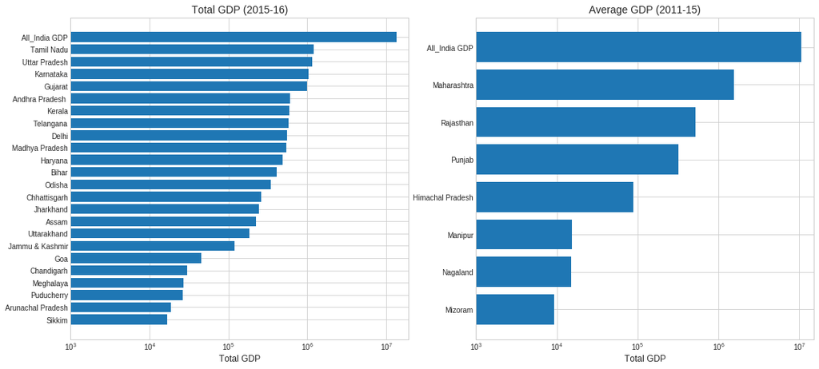

```python
plt.figure(figsize = (18,8))

# Total GDP over the Duration 2015-16:

# Making a subplot on a figure with 1 row and 2 columns:
plt.subplot(121)
x_1 = total_GDP_2015_16['Value']
y_1 = total_GDP_2015_16['State']
plt.barh(y_1, x_1)
plt.xscale('log')
plt.xticks([10**3, 10**4, 10**5, 10**6, 10**7])
fonts = {'size' : 12}
plt.xlabel('Total GDP', **fonts)
fonts_1 = {'size' : 14}
plt.title('Total GDP (2015-16)', **fonts_1)


# Average GDP of the specific states over the Duration 2011-15:
total_GDP_2011_15_small = total_GDP_2011_15[total_GDP_2011_15['State'].isin(['Himachal Pradesh', 'Maharashtra',
                                                                             'Manipur','Mizoram','Nagaland',
                                                                             'Punjab','Rajasthan','Tripura'
                                                                             'Andaman & Nicobar Islands',
                                                                            'All_India GDP'])]
total_GDP_2011_15_small = total_GDP_2011_15_small.sort_values('Value')

# Making a second subplot:
plt.subplot(122)
x_2 = total_GDP_2011_15_small['Value']
y_2 = total_GDP_2011_15_small['State']
plt.barh(y_2, x_2)
plt.xscale('log')
plt.xticks([10**3, 10**4, 10**5, 10**6, 10**7])
plt.xlabel('Total GDP', **fonts)
plt.title('Average GDP (2011-15)', **fonts_1)
```

For the year 2015-16, the results haven't changed much. From both the plots we can see that the top 5 and the bottom 5 states would have been the same.  
However the Total GDP of India has grown by 10% during this time. (source DataFrame: state_wise_GDP)

# Part 1-B

This part is more concerned with the GDP of each state and the **sectors and sub-sectors** that contribute to it. It also contains data on the **Per Capita GDP** which indicates the monetary value a person of the State generates in one year. This is in direct proportion to the Per Capita Income.  
Since this part is only concerned with the States, let us drop all the Union Territories from the DataFrame used for Part 1-A  
Since for most of the States, the data is present for the year **2014-15**, we'll be using the data corresponding to this year alone.

```python
# Dropping the columns corresponding to the UT's:
cols = ['Andaman & Nicobar Islands', 'Chandigarh', 'Delhi',
       'Puducherry']

state_wise_GDP.drop(cols, axis='columns', inplace = True)

# Filtering out the rows corresponding to years apart from 2014-15:
state_wise_GDP = state_wise_GDP[state_wise_GDP['Duration']=='2014-15']

state_wise_GDP
```

|  | Items Description | Duration | Andhra Pradesh | Arunachal Pradesh | Assam | Bihar | Chhattisgarh | Goa | Gujarat | Haryana | ... | Odisha | Punjab | Rajasthan | Sikkim | Tamil Nadu | Telangana | Tripura | Uttar Pradesh | Uttarakhand | All_India GDP |
| --- | --- | --- | --- | --- | --- | --- | --- | --- | --- | --- | --- | --- | --- | --- | --- | --- | --- | --- | --- | --- | --- |
| 3 | GSDP - CURRENT PRICES (` in Crore) | 2014-15 | 526468.0 | 16761.00 | 198098.00 | 373920.00 | 234982.00 | 40633.00 | 895027.00 | 437462.00 | ... | 321971.00 | 368011.00 | 612194.00 | 15209.00 | 1092564.00 | 511178.00 | 29667.00 | 1043371.00 | 161985.00 | 12433749.00 |
| 8 | (% Growth over previous year) | 2014-15 | 13.4 | 14.79 | 11.45 | 17.92 | 13.69 | 13.12 | 10.82 | 9.18 | ... | 10.37 | 9.95 | 11.37 | 9.72 | 12.51 | 13.05 | 15.92 | 10.51 | 8.12 | 10.65 |

2 rows × 31 columns

Loading the Datasets for the various states

```python
# Importing Data 1-B:
Andhra=pd.read_csv('NAD-Andhra_Pradesh-GSVA_cur_2016-17.csv')
Arunachal=pd.read_csv('NAD-Arunachal_Pradesh-GSVA_cur_2015-16.csv')
Assam = pd.read_csv('NAD-Assam-GSVA_cur_2015-16.csv')
Bihar = pd.read_csv('NAD-Bihar-GSVA_cur_2015-16.csv')
Chattis = pd.read_csv('NAD-Chhattisgarh-GSVA_cur_2016-17.csv')
Goa = pd.read_csv('NAD-Goa-GSVA_cur_2015-16.csv')
Guj = pd.read_csv('NAD-Gujarat-GSVA_cur_2015-16.csv')
Haryana = pd.read_csv('NAD-Haryana-GSVA_cur_2016-17.csv')
Himachal = pd.read_csv('NAD-Himachal_Pradesh-GSVA_cur_2014-15.csv')
Jharkhand = pd.read_csv('NAD-Jharkhand-GSVA_cur_2015-16.csv')
Karnataka = pd.read_csv('NAD-Karnataka-GSVA_cur_2015-16.csv')
Kerala = pd.read_csv('NAD-Kerala-GSVA_cur_2015-16.csv')
MP =  pd.read_csv('NAD-Madhya_Pradesh-GSVA_cur_2016-17.csv')
Manipur = pd.read_csv('NAD-Manipur-GSVA_cur_2014-15.csv')
Maha = pd.read_csv('NAD-Maharashtra-GSVA_cur_2014-15.csv')
Megh = pd.read_csv('NAD-Meghalaya-GSVA_cur_2016-17.csv')
Mizoram = pd.read_csv('NAD-Mizoram-GSVA_cur_2014-15.csv')
Nagaland = pd.read_csv('NAD-Nagaland-GSVA_cur_2014-15.csv')
Orissa = pd.read_csv('NAD-Odisha-GSVA_cur_2016-17.csv')
Punjab = pd.read_csv('NAD-Punjab-GSVA_cur_2014-15.csv')
Raj = pd.read_csv('NAD-Rajasthan-GSVA_cur_2014-15.csv')
Sikkim = pd.read_csv('NAD-Sikkim-GSVA_cur_2015-16.csv')
TN = pd.read_csv('NAD-Tamil_Nadu-GSVA_cur_2016-17.csv')
Telangana = pd.read_csv('NAD-Telangana-GSVA_cur_2016-17.csv')
Tripura = pd.read_csv('NAD-Tripura-GSVA_cur_2014-15.csv')
Uttarakhand = pd.read_csv('NAD-Uttarakhand-GSVA_cur_2015-16.csv')
UP = pd.read_csv('NAD-Uttar_Pradesh-GSVA_cur_2015-16.csv')
```

```python
# Understanding the structure of Data for any one state:
MP
```

|  | S.No. | Item | 2011-12 | 2012-13 | 2013-14 | 2014-15 | 2015-16 | 2016-17 |
| --- | --- | --- | --- | --- | --- | --- | --- | --- |
| 0 | 1 | Agriculture, forestry and fishing | 9107231 | 12640261 | 14859567 | 16235647 | 17861367 | 23308835 |
| 1 | 1.1 | Crops | 7333369 | 10540449 | 12457830 | 13216013 | 13958549 | 18661843 |
| 2 | 1.2 | Livestock | 897640 | 1129978 | 1363179 | 1932769 | 2745187 | 3375141 |
| 3 | 1.3 | Forestry and logging | 811315 | 892627 | 943162 | 965588 | 1018504 | 1091337 |
| 4 | 1.4 | Fishing and aquaculture | 64907 | 77207 | 95396 | 121277 | 139127 | 180514 |
| 5 | 2 | Mining and quarrying | 1171195 | 1260187 | 1548066 | 1618373 | 1686385 | 1924216 |
| 6 | Total | Primary | 10278426 | 13900448 | 16407633 | 17854020 | 19547752 | 25233051 |
| 7 | 3 | Manufacturing | 3828625 | 4171724 | 4018450 | 4368833 | 4730335 | 5175608 |
| 8 | 4 | Electricity, gas, water supply & other utility... | 903127 | 1011624 | 1161616 | 1272905 | 1520303 | 1679614 |
| 9 | 5 | Construction | 3495447 | 3499404 | 4080463 | 4403151 | 4772101 | 5186891 |
| 10 | Total | Secondary | 8227199 | 8682752 | 9260529 | 10044889 | 11022739 | 12042113 |
| 11 | 6 | Trade, repair, hotels and restaurants | 3378935 | 4128368 | 4714291 | 5357515 | 6237544 | 6914838 |
| 12 | 6.1 | Trade & repair services | 3149375 | 3873696 | 4427944 | 5053625 | 5901007 | 6556695 |
| 13 | 6.2 | Hotels & restaurants | 229560 | 254672 | 286347 | 303890 | 336537 | 358143 |
| 14 | 7 | Transport, storage, communication & services r... | 1831032 | 2199650 | 2505384 | 2865802 | 3329850 | 3806046 |
| 15 | 7.1 | Railways | 318912 | 436586 | 457608 | 498734 | 581300 | 617543 |
| 16 | 7.2 | Road transport | 949685 | 1096094 | 1209997 | 1369235 | 1538680 | 1705112 |
| 17 | 7.3 | Water transport | 0 | 0 | 0 | 0 | 0 | 0 |
| 18 | 7.4 | Air transport | 4209 | 8197 | 6141 | 26746 | 26745 | 54206 |
| 19 | 7.5 | Services incidental to transport | 25479 | 29362 | 32489 | 36694 | 41412 | 46101 |
| 20 | 7.6 | Storage | 18514 | 23059 | 26256 | 29012 | 33987 | 38059 |
| 21 | 7.7 | Communication & services related to broadcasting | 514233 | 606352 | 772893 | 905381 | 1107726 | 1345025 |
| 22 | 8 | Financial services | 1593654 | 1732129 | 1920614 | 1988794 | 2384124 | 2674933 |
| 23 | 9 | Real estate, ownership of dwelling & professio... | 1639308 | 1945857 | 2279709 | 2660123 | 3085987 | 3499140 |
| 24 | 10 | Public administration | 1629141 | 1907083 | 2164636 | 2497321 | 2873690 | 3221560 |
| 25 | 11 | Other services | 1791096 | 2145512 | 2359317 | 2747805 | 3200937 | 3511083 |
| 26 | Total | Tertiary | 11863166 | 14058599 | 15943951 | 18117360 | 21112132 | 23627600 |
| 27 | 12 | TOTAL GSVA at basic prices | 30368791 | 36641799 | 41612113 | 46016269 | 51682623 | 60902764 |
| 28 | 13 | Taxes on Products | 2983400 | 3717500 | 4087700 | 4284700 | 4960400 | 5570200 |
| 29 | 14 | Subsidies on products | 1796100 | 2266900 | 1926100 | 2102800 | 2245500 | 2424600 |
| 30 | 15 | Gross State Domestic Product | 31556091 | 38092399 | 43773713 | 48198169 | 54397523 | 64048364 |
| 31 | 16 | Population ('00) | 732470 | 743220 | 754120 | 765180 | 776410 | 787800 |
| 32 | 17 | Per Capita GSDP (Rs.) | 43082 | 51253 | 58046 | 62989 | 70063 | 81300 |

The DataFrame has rows corresponding to the different sectors that contribute to the GDP of that state.  
The columns are mainly durations over which the contribution by each sector to the state GDP has been recorded.

Since the analysis has to be conducted only for the year 2014-15, let us drop all the unwanted columns from the DataFrame.  
There are about 27 DataFrames for which this operation has to be done. If done manually it will be quite a daunting task. It is better to write a function that will repeat the same operation for all the 27 DataFrames.

```python
# Defining a function to drop columns from the DataFrame:
def del_columns(df):
    for i in df.columns:
        if i in ['2011-12', '2012-13', '2013-14', '2015-16', '2016-17']:
            df.drop(i, axis='columns', inplace = True)
```

```python
# Calling the function to drop the columns:
for i in [Andhra,Arunachal,Assam,Bihar,Chattis,
Goa,Guj,Haryana,Himachal,Jharkhand,Karnataka,Kerala,
MP,Manipur,Maha,Megh,Mizoram,Nagaland,
Orissa,Punjab,Raj,Sikkim,TN,Telangana,Tripura,Uttarakhand,UP]:
    del_columns(i)
```

```python
# Checking if the columns have been dropped.
# The DataFrames should now only contain the columns 'S.No.', 'Item' and '2014-15'
for i in [Andhra,Arunachal,Assam,Bihar,Chattis,
Goa,Guj,Haryana,Himachal,Jharkhand,Karnataka,Kerala,
MP,Manipur,Maha,Megh,Mizoram,Nagaland,
Orissa,Punjab,Raj,Sikkim,TN,Telangana,Tripura,Uttarakhand,UP]:
    print(i.columns)
```

```
Index(['S.No.', 'Item', '2014-15'], dtype='object')
Index(['S.No.', 'Item', '2014-15'], dtype='object')
Index(['S.No.', 'Item', '2014-15'], dtype='object')
Index(['S.No.', 'Item', '2014-15'], dtype='object')
Index(['S.No.', 'Item', '2014-15'], dtype='object')
Index(['S.No.', 'Item', '2014-15'], dtype='object')
Index(['S.No.', 'Item', '2014-15'], dtype='object')
Index(['S.No.', 'Item', '2014-15'], dtype='object')
Index(['S.No.', 'Item', '2014-15'], dtype='object')
Index(['S.No.', 'Item', '2014-15'], dtype='object')
Index(['S.No.', 'Item', '2014-15'], dtype='object')
Index(['S.No.', 'Item', '2014-15'], dtype='object')
Index(['S.No.', 'Item', '2014-15'], dtype='object')
Index(['S.No.', 'Item', '2014-15'], dtype='object')
Index(['S.No.', 'Item', '2014-15'], dtype='object')
Index(['S.No.', 'Item', '2014-15'], dtype='object')
Index(['S.No.', 'Item', '2014-15'], dtype='object')
Index(['S.No.', 'Item', '2014-15'], dtype='object')
Index(['S.No.', 'Item', '2014-15'], dtype='object')
Index(['S.No.', 'Item', '2014-15'], dtype='object')
Index(['S.No.', 'Item', '2014-15'], dtype='object')
Index(['S.No.', 'Item', '2014-15'], dtype='object')
Index(['S.No.', 'Item', '2014-15'], dtype='object')
Index(['S.No.', 'Item', '2014-15'], dtype='object')
Index(['S.No.', 'Item', '2014-15'], dtype='object')
Index(['S.No.', 'Item', '2014-15'], dtype='object')
Index(['S.No.', 'Item', '2014-15'], dtype='object')
```

All the DataFrames have become a lot cleaner and now they are ready to be merged into a single DataFrame. With the help of a little bit of hindsight, we can infer that since all the DataFrames have identical column names, it will become a bit of a mess while merging them together.  
A good solution is to add **State_Name** at the end of each column, that way they'll be easily identifiable.  
Let us give names to all the DataFrames, these names can then be called upon while changing the column names.

```python
# Naming the DataFrames:
Andhra.name = 'Andhra'
Arunachal.name = 'Arunachal'
Assam.name = 'Assam'
Bihar.name = 'Bihar'
Chattis.name = 'Chattis'
Goa.name = 'Goa'
Guj.name = 'Guj'
Haryana.name = 'Haryana'
Himachal.name = 'Himachal'
Jharkhand.name = 'Jharkhand'
Karnataka.name = 'Karnataka'
Kerala.name = 'Kerala'
MP.name = 'MP'
Manipur.name = 'Manipur'
Maha.name = 'Maha'
Megh.name = 'Megh'
Mizoram.name = 'Mizoram'
Nagaland.name = 'Nagaland'
Orissa.name = 'Orissa'
Punjab.name = 'Punjab'
Raj.name = 'Raj'
Sikkim.name = 'Sikkim'
TN.name = 'TN'
Telangana.name = 'Telangana'
Tripura.name = 'Tripura'
Uttarakhand.name = 'Uttarakhand'
UP.name = 'UP'
```

Let us now change the column names of each of the DataFrame.  
Again, since this is a repetetive task, it is better to write a function that will do it neatly.

```python
# Adding the '_State_Name' to each column:
for i in [Andhra,Arunachal,Assam,Bihar,Chattis,
Goa,Guj,Haryana,Himachal,Jharkhand,Karnataka,Kerala,
MP,Manipur,Maha,Megh,Mizoram,Nagaland,
Orissa,Punjab,Raj,Sikkim,TN,Telangana,Tripura,Uttarakhand,UP]:
    i.columns = i.columns.map(lambda x : str(x) + '_' + str(i.name) )
```

```python
# Checking the DataFrames:
for i in [Andhra,Arunachal,Assam,Bihar,Chattis,
Goa,Guj,Haryana,Himachal,Jharkhand,Karnataka,Kerala,
MP,Manipur,Maha,Megh,Mizoram,Nagaland,
Orissa,Punjab,Raj,Sikkim,TN,Telangana,Tripura,Uttarakhand,UP]:
    print(i.columns)
```

```
Index(['S.No._Andhra', 'Item_Andhra', '2014-15_Andhra'], dtype='object')
Index(['S.No._Arunachal', 'Item_Arunachal', '2014-15_Arunachal'], dtype='object')
Index(['S.No._Assam', 'Item_Assam', '2014-15_Assam'], dtype='object')
Index(['S.No._Bihar', 'Item_Bihar', '2014-15_Bihar'], dtype='object')
Index(['S.No._Chattis', 'Item_Chattis', '2014-15_Chattis'], dtype='object')
Index(['S.No._Goa', 'Item_Goa', '2014-15_Goa'], dtype='object')
Index(['S.No._Guj', 'Item_Guj', '2014-15_Guj'], dtype='object')
Index(['S.No._Haryana', 'Item_Haryana', '2014-15_Haryana'], dtype='object')
Index(['S.No._Himachal', 'Item_Himachal', '2014-15_Himachal'], dtype='object')
Index(['S.No._Jharkhand', 'Item_Jharkhand', '2014-15_Jharkhand'], dtype='object')
Index(['S.No._Karnataka', 'Item_Karnataka', '2014-15_Karnataka'], dtype='object')
Index(['S.No._Kerala', 'Item_Kerala', '2014-15_Kerala'], dtype='object')
Index(['S.No._MP', 'Item_MP', '2014-15_MP'], dtype='object')
Index(['S.No._Manipur', 'Item_Manipur', '2014-15_Manipur'], dtype='object')
Index(['S.No._Maha', 'Item_Maha', '2014-15_Maha'], dtype='object')
Index(['S.No._Megh', 'Item_Megh', '2014-15_Megh'], dtype='object')
Index(['S.No._Mizoram', 'Item_Mizoram', '2014-15_Mizoram'], dtype='object')
Index(['S.No._Nagaland', 'Item_Nagaland', '2014-15_Nagaland'], dtype='object')
Index(['S.No._Orissa', 'Item_Orissa', '2014-15_Orissa'], dtype='object')
Index(['S.No._Punjab', 'Item_Punjab', '2014-15_Punjab'], dtype='object')
Index(['S.No._Raj', 'Item_Raj', '2014-15_Raj'], dtype='object')
Index(['S.No._Sikkim', 'Item_Sikkim', '2014-15_Sikkim'], dtype='object')
Index(['S.No._TN', 'Item_TN', '2014-15_TN'], dtype='object')
Index(['S.No._Telangana', 'Item_Telangana', '2014-15_Telangana'], dtype='object')
Index(['S.No._Tripura', 'Item_Tripura', '2014-15_Tripura'], dtype='object')
Index(['S.No._Uttarakhand', 'Item_Uttarakhand', '2014-15_Uttarakhand'], dtype='object')
Index(['S.No._UP', 'Item_UP', '2014-15_UP'], dtype='object')
```

The DataFrames look good and they are now ready to be merged.  
Since the 'Item_State_Name' column is the only column with unique values, the joins will have to be done on it.  
However, on looking at DataFrames for some States, certain sectors have an asterisk at the end of the sector name, which will result in the failing of join condition.  
Let us remove the asterisk from those states

```python
# For the states 'Gujarat', 'Kerala', 'Tamil Nadu', 'Tripura' and 'Uttarakhand'
# the DataFrames will have to be cleaned further.

# Gujarat:
Guj
# Row with index = 19 has an asterisk at the end
Guj.iloc[19,1] = 'Services incidental to transport'
Guj
```

|  | S.No._Guj | Item_Guj | 2014-15_Guj |
| --- | --- | --- | --- |
| 0 | 1 | Agriculture, forestry and fishing | 13769969.00 |
| 1 | 1.1 | Crops | 9671086.00 |
| 2 | 1.2 | Livestock | 2698910.00 |
| 3 | 1.3 | Forestry and logging | 761616.00 |
| 4 | 1.4 | Fishing and aquaculture | 638357.00 |
| 5 | 2 | Mining and quarrying | 2117218.00 |
| 6 | Total | Primary | 15887187.00 |
| 7 | 3 | Manufacturing | 24087538.00 |
| 8 | 4 | Electricity, gas, water supply & other utility... | 3409983.00 |
| 9 | 5 | Construction | 5526017.00 |
| 10 | Total | Secondary | 33023538.00 |
| 11 | 6 | Trade, repair, hotels and restaurants | 10178713.00 |
| 12 | 6.1 | Trade & repair services | 10178713.00 |
| 13 | 6.2 | Hotels & restaurants | NaN |
| 14 | 7 | Transport, storage, communication & services r... | 4555910.00 |
| 15 | 7.1 | Railways | 511593.00 |
| 16 | 7.2 | Road transport | NaN |
| 17 | 7.3 | Water transport | NaN |
| 18 | 7.4 | Air transport | NaN |
| 19 | 7.5 | Services incidental to transport | 2744163.00 |
| 20 | 7.6 | Storage | 57634.00 |
| 21 | 7.7 | Communication & services related to broadcasting | 1242520.00 |
| 22 | 8 | Financial services | 4606644.00 |
| 23 | 9 | Real estate, ownership of dwelling & professio... | 5179502.00 |
| 24 | 10 | Public administration | 2576195.00 |
| 25 | 11 | Other services | 3123413.00 |
| 26 | Total | Tertiary | 30220377.00 |
| 27 | 12 | TOTAL GSVA at basic prices | 79131102.00 |
| 28 | 13 | Taxes on Products | 12353171.04 |
| 29 | 14 | Subsidies on products | 1981546.00 |
| 30 | 15 | Gross State Domestic Product | 89502727.00 |
| 31 | 16 | Population ('00) | 633590.00 |
| 32 | 17 | Per Capita GSDP (Rs.) | 141263.00 |

```python
# Kerala:
Kerala

# Row index 12 and 16 have an asterisk at the end.
Kerala.iloc[12,1] = 'Trade & repair services'
Kerala.iloc[16,1] = 'Road transport'

Kerala
```

|  | S.No._Kerala | Item_Kerala | 2014-15_Kerala |
| --- | --- | --- | --- |
| 0 | 1 | Agriculture, forestry and fishing | 5930617 |
| 1 | 1.1 | Crops | 3070386 |
| 2 | 1.2 | Livestock | 1656104 |
| 3 | 1.3 | Forestry and logging | 499808 |
| 4 | 1.4 | Fishing and aquaculture | 704319 |
| 5 | 2 | Mining and quarrying | 558824 |
| 6 | Total | Primary | 6489442 |
| 7 | 3 | Manufacturing | 4273567 |
| 8 | 4 | Electricity, gas, water supply & other utility... | 482470 |
| 9 | 5 | Construction | 7314003 |
| 10 | Total | Secondary | 12070040 |
| 11 | 6 | Trade, repair, hotels and restaurants | 8557345 |
| 12 | 6.1 | Trade & repair services | 7763847 |
| 13 | 6.2 | Hotels & restaurants | 793498 |
| 14 | 7 | Transport, storage, communication & services r... | 4020934 |
| 15 | 7.1 | Railways | 147897 |
| 16 | 7.2 | Road transport | 2761427 |
| 17 | 7.3 | Water transport | 26956 |
| 18 | 7.4 | Air transport | 125029 |
| 19 | 7.5 | Services incidental to transport | 71567 |
| 20 | 7.6 | Storage | 3290 |
| 21 | 7.7 | Communication & services related to broadcasting | 884767 |
| 22 | 8 | Financial services | 2010306 |
| 23 | 9 | Real estate, ownership of dwelling & professio... | 7287633 |
| 24 | 10 | Public administration | 2068915 |
| 25 | 11 | Other services | 5728645 |
| 26 | Total | Tertiary | 29673778 |
| 27 | 12 | TOTAL GSVA at basic prices | 48233259 |
| 28 | 13 | Taxes on Products | 5189352 |
| 29 | 14 | Subsidies on products | 822381 |
| 30 | 15 | Gross State Domestic Product | 52600230 |
| 31 | 16 | Population ('00) | 339843 |
| 32 | 17 | Per Capita GSDP (Rs.) | 154778 |

```python
# Tamil Nadu
TN
# Row index 19 has an asterisk at the end for the column 'Item'
TN.iloc[19,1] = 'Services incidental to transport'
TN
```

|  | S.No._TN | Item_TN | 2014-15_TN |
| --- | --- | --- | --- |
| 0 | 1 | Agriculture, forestry and fishing | 13064238 |
| 1 | 1.1 | Crops | 7297820 |
| 2 | 1.2 | Livestock | 4693361 |
| 3 | 1.3 | Forestry and logging | 392705 |
| 4 | 1.4 | Fishing and aquaculture | 680352 |
| 5 | 2 | Mining and quarrying | 265536 |
| 6 | Total | Primary | 13329774 |
| 7 | 3 | Manufacturing | 18914794 |
| 8 | 4 | Electricity, gas, water supply & other utility... | 1710379 |
| 9 | 5 | Construction | 12216718 |
| 10 | Total | Secondary | 32841892 |
| 11 | 6 | Trade, repair, hotels and restaurants | 12895842 |
| 12 | 6.1 | Trade & repair services | 11252588 |
| 13 | 6.2 | Hotels & restaurants | 1643253 |
| 14 | 7 | Transport, storage, communication & services r... | 7188320 |
| 15 | 7.1 | Railways | 468553 |
| 16 | 7.2 | Road transport | 3660994 |
| 17 | 7.3 | Water transport | 70414 |
| 18 | 7.4 | Air transport | 180836 |
| 19 | 7.5 | Services incidental to transport | 864407 |
| 20 | 7.6 | Storage | 39834 |
| 21 | 7.7 | Communication & services related to broadcasting | 1903283 |
| 22 | 8 | Financial services | 5598498 |
| 23 | 9 | Real estate, ownership of dwelling & professio... | 16830213 |
| 24 | 10 | Public administration | 3400800 |
| 25 | 11 | Other services | 7430115 |
| 26 | Total | Tertiary | 53343788 |
| 27 | 12 | TOTAL GSVA at basic prices | 99515453 |
| 28 | 13 | Taxes on Products | 12507325 |
| 29 | 14 | Subsidies on products | 2766405 |
| 30 | 15 | Gross State Domestic Product | 109256373 |
| 31 | 16 | Population ('00) | 745760 |
| 32 | 17 | Per Capita GSDP (Rs.) | 146503 |

```python
# Tripura:
Tripura
# Row index 19 has an asterisk at the end:
Tripura.iloc[19,1] = 'Services incidental to transport'
Tripura
```

|  | S.No._Tripura | Item_Tripura | 2014-15_Tripura |
| --- | --- | --- | --- |
| 0 | 1 | Agriculture, forestry and fishing | 799825.0 |
| 1 | 1.1 | Crops | 397591.0 |
| 2 | 1.2 | Livestock | 88176.0 |
| 3 | 1.3 | Forestry and logging | 145096.0 |
| 4 | 1.4 | Fishing and aquaculture | 168961.0 |
| 5 | 2 | Mining and quarrying | 142391.0 |
| 6 | Total | Primary | 942216.0 |
| 7 | 3 | Manufacturing | 228625.0 |
| 8 | 4 | Electricity, gas, water supply & other utility... | 77870.0 |
| 9 | 5 | Construction | 177899.0 |
| 10 | Total | Secondary | 484393.0 |
| 11 | 6 | Trade, repair, hotels and restaurants | 390423.0 |
| 12 | 6.1 | Trade & repair services | 390423.0 |
| 13 | 6.2 | Hotels & restaurants | NaN |
| 14 | 7 | Transport, storage, communication & services r... | 155956.0 |
| 15 | 7.1 | Railways | 305.0 |
| 16 | 7.2 | Road transport | NaN |
| 17 | 7.3 | Water transport | NaN |
| 18 | 7.4 | Air transport | NaN |
| 19 | 7.5 | Services incidental to transport | 88721.0 |
| 20 | 7.6 | Storage | 254.0 |
| 21 | 7.7 | Communication & services related to broadcasting | 66676.0 |
| 22 | 8 | Financial services | 86094.0 |
| 23 | 9 | Real estate, ownership of dwelling & professio... | 190704.0 |
| 24 | 10 | Public administration | 338244.0 |
| 25 | 11 | Other services | 323287.0 |
| 26 | Total | Tertiary | 1484709.0 |
| 27 | 12 | TOTAL GSVA at basic prices | 2911319.0 |
| 28 | 13 | Taxes on Products | 149345.0 |
| 29 | 14 | Subsidies on products | 94002.0 |
| 30 | 15 | Gross State Domestic Product | 2966662.0 |
| 31 | 16 | Population ('00) | 38350.0 |
| 32 | 17 | Per Capita GSDP (Rs.) | 77358.0 |

```python
#Uttarakhand
Uttarakhand

# Row with index=16 has an asterisk at the end.
Uttarakhand.iloc[16,1] = 'Road transport'
Uttarakhand
```

|  | S.No._Uttarakhand | Item_Uttarakhand | 2014-15_Uttarakhand |
| --- | --- | --- | --- |
| 0 | 1 | Agriculture, forestry and fishing | 1601423.0 |
| 1 | 1.1 | Crops | 866146.0 |
| 2 | 1.2 | Livestock | 391188.0 |
| 3 | 1.3 | Forestry and logging | 339293.0 |
| 4 | 1.4 | Fishing and aquaculture | 4796.0 |
| 5 | 2 | Mining and quarrying | 244549.0 |
| 6 | Total | Primary | 1845972.0 |
| 7 | 3 | Manufacturing | 5866252.0 |
| 8 | 4 | Electricity, gas, water supply & other utility... | 433880.0 |
| 9 | 5 | Construction | 1342733.0 |
| 10 | Total | Secondary | 7642865.0 |
| 11 | 6 | Trade, repair, hotels and restaurants | 1743106.0 |
| 12 | 6.1 | Trade & repair services | 1534073.0 |
| 13 | 6.2 | Hotels & restaurants | 209033.0 |
| 14 | 7 | Transport, storage, communication & services r... | 1066693.0 |
| 15 | 7.1 | Railways | 21295.0 |
| 16 | 7.2 | Road transport | 307147.0 |
| 17 | 7.3 | Water transport | NaN |
| 18 | 7.4 | Air transport | 3889.0 |
| 19 | 7.5 | Services incidental to transport | -76.0 |
| 20 | 7.6 | Storage | 660.0 |
| 21 | 7.7 | Communication & services related to broadcasting | 733778.0 |
| 22 | 8 | Financial services | 385030.0 |
| 23 | 9 | Real estate, ownership of dwelling & professio... | 831307.0 |
| 24 | 10 | Public administration | 579409.0 |
| 25 | 11 | Other services | 982430.0 |
| 26 | Total | Tertiary | 5587975.0 |
| 27 | 12 | TOTAL GSVA at basic prices | 15076812.0 |
| 28 | 13 | Taxes on Products | 1434856.0 |
| 29 | 14 | Subsidies on products | 313139.0 |
| 30 | 15 | Gross State Domestic Product | 16198529.0 |
| 31 | 16 | Population ('00) | 105820.0 |
| 32 | 17 | Per Capita GSDP (Rs.) | 153076.0 |

Now the DataFrames are in perfect shape to be merged

```python
# Merging the dataframes:
andhra_arun = Andhra.merge(Arunachal, left_on='Item_Andhra', right_on='Item_Arunachal', how='inner')
print(Andhra.shape)
print(andhra_arun.shape)

a_a_Assam = andhra_arun.merge(Assam, left_on='Item_Andhra', right_on='Item_Assam', how='inner')
print(a_a_Assam.shape)

a_a_a_bihar = a_a_Assam.merge(Bihar, left_on='Item_Andhra', right_on='Item_Bihar', how='inner')
print(a_a_a_bihar.shape)

bihar_ch = a_a_a_bihar.merge(Chattis, left_on='Item_Andhra', right_on='Item_Chattis', how='inner')
print(bihar_ch.shape)

ch_goa = bihar_ch.merge(Goa, left_on='Item_Andhra', right_on='Item_Goa', how='inner')
print(ch_goa.shape)

goa_guj = ch_goa.merge(Guj, left_on='Item_Andhra', right_on='Item_Guj', how='inner')
print(goa_guj.shape)

guj_haryana = goa_guj.merge(Haryana, left_on='Item_Andhra', right_on='Item_Haryana', how='inner')
print(guj_haryana.shape)

haryana_himach = guj_haryana.merge(Himachal, left_on='Item_Andhra', right_on='Item_Himachal', how='inner')
print(haryana_himach.shape)

himach_jha = haryana_himach.merge(Jharkhand, left_on='Item_Andhra', right_on='Item_Jharkhand', how='inner')
print(himach_jha.shape)

jha_karn = himach_jha.merge(Karnataka, left_on='Item_Andhra', right_on='Item_Karnataka', how='inner')
print(jha_karn.shape)

karn_kerala = jha_karn.merge(Kerala, left_on='Item_Andhra', right_on='Item_Kerala', how='inner')
print(karn_kerala.shape)

kerala_mp = karn_kerala.merge(MP, left_on='Item_Andhra', right_on='Item_MP', how='inner')
print(kerala_mp.shape)

mp_maha = kerala_mp.merge(Maha, left_on='Item_Andhra', right_on='Item_Maha', how='inner')
print(mp_maha.shape)

maha_megh = mp_maha.merge(Megh, left_on='Item_Andhra', right_on='Item_Megh', how='inner')
print(maha_megh.shape)

megh_mizo = maha_megh.merge(Mizoram, left_on='Item_Andhra', right_on='Item_Mizoram', how='inner')
print(megh_mizo.shape)

mizo_mani = megh_mizo.merge(Manipur, left_on='Item_Andhra', right_on='Item_Manipur', how='inner')
print(mizo_mani.shape)

mani_naga = mizo_mani.merge(Nagaland, left_on='Item_Andhra', right_on='Item_Nagaland', how='inner')
print(mani_naga.shape)

naga_ori = mani_naga.merge(Orissa, left_on='Item_Andhra', right_on='Item_Orissa', how='inner')
print(naga_ori.shape)

ori_pun = naga_ori.merge(Punjab, left_on='Item_Andhra', right_on='Item_Punjab', how='inner')
print(ori_pun.shape)

pun_raj = ori_pun.merge(Raj, left_on='Item_Andhra', right_on='Item_Raj', how='inner')
print(pun_raj.shape)

raj_sikk = pun_raj.merge(Sikkim, left_on='Item_Andhra', right_on='Item_Sikkim', how='inner')
print(raj_sikk.shape)

sikk_tn = raj_sikk.merge(TN, left_on='Item_Andhra', right_on='Item_TN', how='inner')
print(sikk_tn.shape)

tn_tel = sikk_tn.merge(Telangana, left_on='Item_Andhra', right_on='Item_Telangana', how='inner')
print(tn_tel.shape)

tel_tri = tn_tel.merge(Tripura, left_on='Item_Andhra', right_on='Item_Tripura', how='inner')
print(tel_tri.shape)

tri_uttarak = tel_tri.merge(Uttarakhand, left_on='Item_Andhra', right_on='Item_Uttarakhand', how='inner')
print(tri_uttarak.shape)

tri_uttarak = tel_tri.merge(Uttarakhand, left_on='Item_Andhra', right_on='Item_Uttarakhand', how='inner')
print(tri_uttarak.shape)

all_states_GSDP = tri_uttarak.merge(UP, left_on='Item_Andhra', right_on='Item_UP', how='inner')
print(all_states_GSDP.shape)
```

```
(33, 3)
(33, 6)
(33, 9)
(33, 12)
(33, 15)
(33, 18)
(33, 21)
(33, 24)
(33, 27)
(33, 30)
(33, 33)
(33, 36)
(33, 39)
(33, 42)
(33, 45)
(33, 48)
(33, 51)
(33, 54)
(33, 57)
(33, 60)
(33, 63)
(33, 66)
(33, 69)
(33, 72)
(33, 75)
(33, 78)
(33, 78)
(33, 81)
```

As we can see from the shape of the final DataFrame (33,81), we have 33 rows as the original DataFrames but the columns have increased from 3 to 81 which makes sense as we have data for 27 states (27 x 3 = 81)

Let us take a look at the columns of the new DataFrame

```python
all_states_GSDP.columns
```

```
Index(['S.No._Andhra', 'Item_Andhra', '2014-15_Andhra', 'S.No._Arunachal',
       'Item_Arunachal', '2014-15_Arunachal', 'S.No._Assam', 'Item_Assam',
       '2014-15_Assam', 'S.No._Bihar', 'Item_Bihar', '2014-15_Bihar',
       'S.No._Chattis', 'Item_Chattis', '2014-15_Chattis', 'S.No._Goa',
       'Item_Goa', '2014-15_Goa', 'S.No._Guj', 'Item_Guj', '2014-15_Guj',
       'S.No._Haryana', 'Item_Haryana', '2014-15_Haryana', 'S.No._Himachal',
       'Item_Himachal', '2014-15_Himachal', 'S.No._Jharkhand',
       'Item_Jharkhand', '2014-15_Jharkhand', 'S.No._Karnataka',
       'Item_Karnataka', '2014-15_Karnataka', 'S.No._Kerala', 'Item_Kerala',
       '2014-15_Kerala', 'S.No._MP', 'Item_MP', '2014-15_MP', 'S.No._Maha',
       'Item_Maha', '2014-15_Maha', 'S.No._Megh', 'Item_Megh', '2014-15_Megh',
       'S.No._Mizoram', 'Item_Mizoram', '2014-15_Mizoram', 'S.No._Manipur',
       'Item_Manipur', '2014-15_Manipur', 'S.No._Nagaland', 'Item_Nagaland',
       '2014-15_Nagaland', 'S.No._Orissa', 'Item_Orissa', '2014-15_Orissa',
       'S.No._Punjab', 'Item_Punjab', '2014-15_Punjab', 'S.No._Raj',
       'Item_Raj', '2014-15_Raj', 'S.No._Sikkim', 'Item_Sikkim',
       '2014-15_Sikkim', 'S.No._TN', 'Item_TN', '2014-15_TN',
       'S.No._Telangana', 'Item_Telangana', '2014-15_Telangana',
       'S.No._Tripura', 'Item_Tripura', '2014-15_Tripura', 'S.No._Uttarakhand',
       'Item_Uttarakhand', '2014-15_Uttarakhand', 'S.No._UP', 'Item_UP',
       '2014-15_UP'],
      dtype='object')
```

We can see a lot of redundant columns like 'S.No.StateName' and 'ItemStateName'. All these can be dropped from the Dataframe to make it cleaner and more readable.

```python
# Dropping the redundant columns:
cols = ['S.No._Arunachal','Item_Arunachal', 'S.No._Assam', 'Item_Assam',
        'S.No._Bihar', 'Item_Bihar',
       'S.No._Chattis', 'Item_Chattis', 'S.No._Goa',
       'Item_Goa', 'S.No._Guj', 'Item_Guj',
       'S.No._Haryana', 'Item_Haryana', 'S.No._Himachal',
       'Item_Himachal', 'S.No._Jharkhand',
       'Item_Jharkhand','S.No._Karnataka',
       'Item_Karnataka','S.No._Kerala', 'Item_Kerala',
       'S.No._MP', 'Item_MP','S.No._Maha',
       'Item_Maha','S.No._Megh', 'Item_Megh',
       'S.No._Mizoram', 'Item_Mizoram', 'S.No._Manipur',
       'Item_Manipur','S.No._Nagaland', 'Item_Nagaland',
       'S.No._Orissa', 'Item_Orissa',
       'S.No._Punjab', 'Item_Punjab','S.No._Raj',
       'Item_Raj','S.No._Sikkim', 'Item_Sikkim',
        'S.No._TN', 'Item_TN',
       'S.No._Telangana', 'Item_Telangana',
       'S.No._Tripura', 'Item_Tripura','S.No._Uttarakhand',
       'Item_Uttarakhand', 'S.No._UP', 'Item_UP']

# Dropping the above list of colums:
all_states_GSDP.drop(cols, axis = 1, inplace = True)

# Taking a look at the new DataFrame:
all_states_GSDP.columns
```

```
Index(['S.No._Andhra', 'Item_Andhra', '2014-15_Andhra', '2014-15_Arunachal',
       '2014-15_Assam', '2014-15_Bihar', '2014-15_Chattis', '2014-15_Goa',
       '2014-15_Guj', '2014-15_Haryana', '2014-15_Himachal',
       '2014-15_Jharkhand', '2014-15_Karnataka', '2014-15_Kerala',
       '2014-15_MP', '2014-15_Maha', '2014-15_Megh', '2014-15_Mizoram',
       '2014-15_Manipur', '2014-15_Nagaland', '2014-15_Orissa',
       '2014-15_Punjab', '2014-15_Raj', '2014-15_Sikkim', '2014-15_TN',
       '2014-15_Telangana', '2014-15_Tripura', '2014-15_Uttarakhand',
       '2014-15_UP'],
      dtype='object')
```

The Data has become a lot cleaner, but since the year considered is only '2014-15', therefore the columns in the DataFrame can be renamed to something that is standard and easy to understand.

```python
# Renaming the Columns:
all_states_GSDP.rename(columns = {'S.No._Andhra': 'S.No.',
                                  'Item_Andhra' : 'Sector',
                                  '2014-15_Andhra' : 'Andhra_Pradesh',
                                  '2014-15_Arunachal' : 'Arunachal_Pradesh',
                                  '2014-15_Assam' : 'Assam',
                                  '2014-15_Bihar' : 'Bihar',
                                  '2014-15_Chattis' : 'Chattisgarh',
                                  '2014-15_Goa' : 'Goa',
                                  '2014-15_Guj' : 'Gujarat',
                                  '2014-15_Haryana' : 'Haryana',
                                  '2014-15_Himachal' : 'Himachal_Pradesh',
                                  '2014-15_Jharkhand' : 'Jharkhand',
                                  '2014-15_Karnataka' : 'Karnataka',
                                  '2014-15_Kerala' : 'Kerala',
                                  '2014-15_MP' : 'Madhya_Pradesh',
                                  '2014-15_Maha' : 'Maharashtra',
                                  '2014-15_Megh' : 'Meghalaya',
                                  '2014-15_Mizoram' : 'Mizoram',
                                  '2014-15_Manipur' : 'Manipur',
                                  '2014-15_Nagaland' : 'Nagaland',
                                  '2014-15_Orissa' : 'Orissa',
                                  '2014-15_Punjab' : 'Punjab',
                                  '2014-15_Raj' : 'Rajasthan',
                                  '2014-15_Sikkim' : 'Sikkim',
                                  '2014-15_TN' : 'Tamil_Nadu',
                                  '2014-15_Telangana' : 'Telangana',
                                  '2014-15_Tripura' : 'Tripura',
                                  '2014-15_Uttarakhand' : 'Uttarakhand',
                                  '2014-15_UP' : 'Uttar_Pradesh'}, inplace = True)

all_states_GSDP
```

|  | S.No. | Sector | Andhra_Pradesh | Arunachal_Pradesh | Assam | Bihar | Chattisgarh | Goa | Gujarat | Haryana | ... | Nagaland | Orissa | Punjab | Rajasthan | Sikkim | Tamil_Nadu | Telangana | Tripura | Uttarakhand | Uttar_Pradesh |
| --- | --- | --- | --- | --- | --- | --- | --- | --- | --- | --- | --- | --- | --- | --- | --- | --- | --- | --- | --- | --- | --- |
| 0 | 1 | Agriculture, forestry and fishing | 14819416 | 686117 | 3855548 | 7951890 | 3948847 | 308507 | 13769969.00 | 8015238.0 | ... | 607897 | 6422978 | 9285716 | 15044394 | 137447 | 13064238 | 7591501 | 799825.0 | 1601423.0 | 25097754 |
| 1 | 1.1 | Crops | 7893514 | 415520 | 2890544 | 4688237 | 2613371 | 140421 | 9671086.00 | 4636731.0 | ... | 375825 | 4382636 | 5690972 | 7673441 | 114976 | 7297820 | 4162493 | 397591.0 | 866146.0 | 16215212 |
| 2 | 1.2 | Livestock | 4309078 | 38387 | 173478 | 2060296 | 352208 | 30141 | 2698910.00 | 2916173.0 | ... | 123800 | 788243 | 2638842 | 5356257 | 17338 | 4693361 | 2951299 | 88176.0 | 391188.0 | 7096876 |
| 3 | 1.3 | Forestry and logging | 346160 | 224017 | 261987 | 550132 | 597785 | 15744 | 761616.00 | 352254.0 | ... | 99802 | 791463 | 848245 | 1956660 | 4529 | 392705 | 210741 | 145096.0 | 339293.0 | 1404936 |
| 4 | 1.4 | Fishing and aquaculture | 2270664 | 8193 | 529539 | 653224 | 385483 | 122201 | 638357.00 | 110080.0 | ... | 8470 | 460636 | 107657 | 58036 | 604 | 680352 | 266968 | 168961.0 | 4796.0 | 380730 |
| 5 | 2 | Mining and quarrying | 1484300 | 30842 | 1471149 | 68107 | 2451970 | 3622 | 2117218.00 | 25186.0 | ... | 8280 | 2586328 | 10354 | 4069385 | 1329 | 265536 | 1541853 | 142391.0 | 244549.0 | 901501 |
| 6 | Total | Primary | 16303716 | 716959 | 5326697 | 8019997 | 6400817 | 312129 | 15887187.00 | 8040424.0 | ... | 616178 | 9009306 | 9296070 | 19113780 | 138776 | 13329774 | 9133354 | 942216.0 | 1845972.0 | 25999255 |
| 7 | 3 | Manufacturing | 4672266 | 26120 | 2002936 | 2189965 | 4370593 | 1177608 | 24087538.00 | 7756921.0 | ... | 18346 | 5754229 | 4790341 | 6552580 | 550697 | 18914794 | 6353711 | 228625.0 | 5866252.0 | 12261649 |
| 8 | 4 | Electricity, gas, water supply & other utility... | 1151729 | 113527 | 296587 | 345168 | 1198438 | 204110 | 3409983.00 | 1101919.0 | ... | 37944 | 833067 | 911611 | 1122888 | 212499 | 1710379 | 716266 | 77870.0 | 433880.0 | 2030625 |
| 9 | 5 | Construction | 4664889 | 147842 | 1733568 | 3449763 | 2669855 | 165819 | 5526017.00 | 3702571.0 | ... | 156072 | 2402396 | 2202962 | 5353326 | 82058 | 12216718 | 2854024 | 177899.0 | 1342733.0 | 11256450 |
| 10 | Total | Secondary | 10488884 | 287489 | 4033091 | 5984896 | 8238886 | 1547536 | 33023538.00 | 12561411.0 | ... | 212361 | 8989693 | 7904914 | 13028794 | 845253 | 32841892 | 9924001 | 484393.0 | 7642865.0 | 25548724 |
| 11 | 6 | Trade, repair, hotels and restaurants | 4233400 | 60421 | 2987155 | 7448373 | 1535571 | 380927 | 10178713.00 | 4986319.0 | ... | 140781 | 3149555 | 4419919 | 7297290 | 70568 | 12895842 | 6494607 | 390423.0 | 1743106.0 | 9437243 |
| 12 | 6.1 | Trade & repair services | 3716000 | 56796 | 2876251 | 7081391 | 1414164 | 343492 | 10178713.00 | 4817784.0 | ... | 134174 | 2886789 | 4201252 | 6942748 | 64624 | 11252588 | 5724128 | 390423.0 | 1534073.0 | 8476139 |
| 13 | 6.2 | Hotels & restaurants | 517400 | 3625 | 110904 | 366982 | 121407 | 37434 | NaN | 168535.0 | ... | 6607 | 262766 | 218667 | 354543 | 5945 | 1643253 | 770479 | NaN | 209033.0 | 961104 |
| 14 | 7 | Transport, storage, communication & services r... | 5076984 | 35203 | 1194568 | 3147173 | 871770 | 189656 | 4555910.00 | 2560623.0 | ... | 77521 | 2034016 | 1951809 | 3814461 | 47347 | 7188320 | 3604741 | 155956.0 | 1066693.0 | 7404509 |
| 15 | 7.1 | Railways | 424228 | 59 | 252509 | 462413 | 159176 | 15649 | 511593.00 | 423873.0 | ... | 336 | 341494 | 233389 | 464638 | 0 | 468553 | 199686 | 305.0 | 21295.0 | 1618742 |
| 16 | 7.2 | Road transport | 2816000 | 15467 | 507668 | 1572288 | 386628 | 46171 | NaN | 1452364.0 | ... | 34548 | 973144 | 928575 | 2121206 | 35283 | 3660994 | 2055658 | NaN | 307147.0 | 3645747 |
| 17 | 7.3 | Water transport | 94200 | 0 | 4502 | 2228 | 0 | 17820 | NaN | NaN | ... | 600 | 50349 | 0 | 0 | 0 | 70414 | 0 | NaN | NaN | 681 |
| 18 | 7.4 | Air transport | 14900 | 0 | 26223 | 13599 | 9507 | 46359 | NaN | NaN | ... | 4153 | 15354 | 4473 | 13469 | 0 | 180836 | 120691 | NaN | 3889.0 | 36582 |
| 19 | 7.5 | Services incidental to transport | 780200 | 109 | 35739 | 166600 | 5232 | 19272 | 2744163.00 | 190269.0 | ... | 0 | 117469 | 48124 | 47609 | 0 | 864407 | 454909 | 88721.0 | -76.0 | 16323 |
| 20 | 7.6 | Storage | 18700 | 0 | 10308 | 10618 | 16675 | 357 | 57634.00 | 14459.0 | ... | 89 | 22675 | 76429 | 16584 | 0 | 39834 | 19805 | 254.0 | 660.0 | 171696 |
| 21 | 7.7 | Communication & services related to broadcasting | 928756 | 19568 | 357619 | 919427 | 294552 | 44028 | 1242520.00 | 479658.0 | ... | 37794 | 513531 | 660819 | 1150955 | 12064 | 1903283 | 753992 | 66676.0 | 733778.0 | 1914737 |
| 22 | 8 | Financial services | 1900863 | 25207 | 543651 | 1178022 | 739057 | 233618 | 4606644.00 | 1671486.0 | ... | 60393 | 1065147 | 2057520 | 1827413 | 21079 | 5598498 | 3023729 | 86094.0 | 385030.0 | 3392275 |
| 23 | 9 | Real estate, ownership of dwelling & professio... | 4405409 | 48418 | 1412466 | 3740641 | 2462166 | 407099 | 5179502.00 | 6970183.0 | ... | 159651 | 2348714 | 3142786 | 6451997 | 75330 | 16830213 | 9478839 | 190704.0 | 831307.0 | 14548185 |
| 24 | 10 | Public administration | 2200897 | 243867 | 1373611 | 2078171 | 867982 | 346486 | 2576195.00 | 1036377.0 | ... | 295424 | 1318221 | 1842730 | 2460364 | 119514 | 3400800 | 1711265 | 338244.0 | 579409.0 | 6152124 |
| 25 | 11 | Other services | 4215389 | 218728 | 1795658 | 4587589 | 1112232 | 180431 | 3123413.00 | 2001581.0 | ... | 259186 | 2340603 | 3303041 | 4164287 | 149265 | 7430115 | 4158229 | 323287.0 | 982430.0 | 5034623 |
| 26 | Total | Tertiary | 22032942 | 631844 | 9307109 | 22179969 | 7588778 | 1738217 | 30220377.00 | 19226568.0 | ... | 992956 | 12256258 | 16717805 | 26015812 | 483103 | 53343788 | 28471410 | 1484709.0 | 5587975.0 | 45968959 |
| 27 | 12 | TOTAL GSVA at basic prices | 48825542 | 1636292 | 18666897 | 36184863 | 22228481 | 3597882 | 79131102.00 | 39828404.0 | ... | 1821495 | 30255256 | 33918789 | 58158386 | 1467133 | 99515453 | 47528765 | 2911319.0 | 15076812.0 | 97516938 |
| 28 | 13 | Taxes on Products | 5512100 | 70099 | 1725309 | 3213546 | 2601791 | 527279 | 12353171.04 | 4985670.0 | ... | 57674 | 3151184 | 3794100 | 5394503 | 72200 | 12507325 | 4425700 | 149345.0 | 1434856.0 | 10107396 |
| 29 | 14 | Subsidies on products | 1690800 | 30272 | 582406 | 2006421 | 1332092 | 61854 | 1981546.00 | 1067867.0 | ... | 37745 | 1209349 | 911800 | 2333442 | 18400 | 2766405 | 836700 | 94002.0 | 313139.0 | 3287219 |
| 30 | 15 | Gross State Domestic Product | 52646842 | 1676119 | 19809800 | 37391988 | 23498180 | 4063307 | 89502727.00 | 43746207.0 | ... | 1841424 | 32197092 | 36801089 | 61219447 | 1520933 | 109256373 | 51117765 | 2966662.0 | 16198529.0 | 104337115 |
| 31 | 16 | Population ('00) | 501510 | 14870 | 326780 | 1101240 | 270530 | 14950 | 633590.00 | 266620.0 | ... | 20550 | 435220 | 290673 | 721610 | 6330 | 745760 | 367660 | 38350.0 | 105820.0 | 2109940 |
| 32 | 17 | Per Capita GSDP (Rs.) | 104977 | 112718 | 60621 | 33954 | 86860 | 271793 | 141263.00 | 164077.0 | ... | 89607 | 73979 | 126606 | 84837 | 240274 | 146503 | 139035 | 77358.0 | 153076.0 | 49450 |

33 rows × 29 columns

### Analysing GDP Per Capita for all the States:

Let us create a new DataFrame that only contains the data for the Per Capita GDP corresponding to each state.

```python
per_capita_gdp = all_states_GSDP[all_states_GSDP['Sector']=='Per Capita GSDP (Rs.)']
per_capita_gdp
```

|  | S.No. | Sector | Andhra_Pradesh | Arunachal_Pradesh | Assam | Bihar | Chattisgarh | Goa | Gujarat | Haryana | ... | Nagaland | Orissa | Punjab | Rajasthan | Sikkim | Tamil_Nadu | Telangana | Tripura | Uttarakhand | Uttar_Pradesh |
| --- | --- | --- | --- | --- | --- | --- | --- | --- | --- | --- | --- | --- | --- | --- | --- | --- | --- | --- | --- | --- | --- |
| 32 | 17 | Per Capita GSDP (Rs.) | 104977 | 112718 | 60621 | 33954 | 86860 | 271793 | 141263.0 | 164077.0 | ... | 89607 | 73979 | 126606 | 84837 | 240274 | 146503 | 139035 | 77358.0 | 153076.0 | 49450 |

1 rows × 29 columns

In order to plot the Data, it needs to be converted to long-format

```python
per_capita_gdp = pd.melt(per_capita_gdp, id_vars = ['S.No.','Sector'],
                         var_name = ['State'], value_name = 'Per Capita GDP' )

per_capita_gdp
```

|  | S.No. | Sector | State | Per Capita GDP |
| --- | --- | --- | --- | --- |
| 0 | 17 | Per Capita GSDP (Rs.) | Andhra_Pradesh | 104977.0 |
| 1 | 17 | Per Capita GSDP (Rs.) | Arunachal_Pradesh | 112718.0 |
| 2 | 17 | Per Capita GSDP (Rs.) | Assam | 60621.0 |
| 3 | 17 | Per Capita GSDP (Rs.) | Bihar | 33954.0 |
| 4 | 17 | Per Capita GSDP (Rs.) | Chattisgarh | 86860.0 |
| 5 | 17 | Per Capita GSDP (Rs.) | Goa | 271793.0 |
| 6 | 17 | Per Capita GSDP (Rs.) | Gujarat | 141263.0 |
| 7 | 17 | Per Capita GSDP (Rs.) | Haryana | 164077.0 |
| 8 | 17 | Per Capita GSDP (Rs.) | Himachal_Pradesh | 147330.0 |
| 9 | 17 | Per Capita GSDP (Rs.) | Jharkhand | 62091.0 |
| 10 | 17 | Per Capita GSDP (Rs.) | Karnataka | 145141.0 |
| 11 | 17 | Per Capita GSDP (Rs.) | Kerala | 154778.0 |
| 12 | 17 | Per Capita GSDP (Rs.) | Madhya_Pradesh | 62989.0 |
| 13 | 17 | Per Capita GSDP (Rs.) | Maharashtra | 152853.0 |
| 14 | 17 | Per Capita GSDP (Rs.) | Meghalaya | 76228.0 |
| 15 | 17 | Per Capita GSDP (Rs.) | Mizoram | 97687.0 |
| 16 | 17 | Per Capita GSDP (Rs.) | Manipur | 58442.0 |
| 17 | 17 | Per Capita GSDP (Rs.) | Nagaland | 89607.0 |
| 18 | 17 | Per Capita GSDP (Rs.) | Orissa | 73979.0 |
| 19 | 17 | Per Capita GSDP (Rs.) | Punjab | 126606.0 |
| 20 | 17 | Per Capita GSDP (Rs.) | Rajasthan | 84837.0 |
| 21 | 17 | Per Capita GSDP (Rs.) | Sikkim | 240274.0 |
| 22 | 17 | Per Capita GSDP (Rs.) | Tamil_Nadu | 146503.0 |
| 23 | 17 | Per Capita GSDP (Rs.) | Telangana | 139035.0 |
| 24 | 17 | Per Capita GSDP (Rs.) | Tripura | 77358.0 |
| 25 | 17 | Per Capita GSDP (Rs.) | Uttarakhand | 153076.0 |
| 26 | 17 | Per Capita GSDP (Rs.) | Uttar_Pradesh | 49450.0 |

Let us Sort the values so that the resulting plot has bars in ascending order:

```python
per_capita_gdp = per_capita_gdp.sort_values('Per Capita GDP')
per_capita_gdp
```

|  | S.No. | Sector | State | Per Capita GDP |
| --- | --- | --- | --- | --- |
| 3 | 17 | Per Capita GSDP (Rs.) | Bihar | 33954.0 |
| 26 | 17 | Per Capita GSDP (Rs.) | Uttar_Pradesh | 49450.0 |
| 16 | 17 | Per Capita GSDP (Rs.) | Manipur | 58442.0 |
| 2 | 17 | Per Capita GSDP (Rs.) | Assam | 60621.0 |
| 9 | 17 | Per Capita GSDP (Rs.) | Jharkhand | 62091.0 |
| 12 | 17 | Per Capita GSDP (Rs.) | Madhya_Pradesh | 62989.0 |
| 18 | 17 | Per Capita GSDP (Rs.) | Orissa | 73979.0 |
| 14 | 17 | Per Capita GSDP (Rs.) | Meghalaya | 76228.0 |
| 24 | 17 | Per Capita GSDP (Rs.) | Tripura | 77358.0 |
| 20 | 17 | Per Capita GSDP (Rs.) | Rajasthan | 84837.0 |
| 4 | 17 | Per Capita GSDP (Rs.) | Chattisgarh | 86860.0 |
| 17 | 17 | Per Capita GSDP (Rs.) | Nagaland | 89607.0 |
| 15 | 17 | Per Capita GSDP (Rs.) | Mizoram | 97687.0 |
| 0 | 17 | Per Capita GSDP (Rs.) | Andhra_Pradesh | 104977.0 |
| 1 | 17 | Per Capita GSDP (Rs.) | Arunachal_Pradesh | 112718.0 |
| 19 | 17 | Per Capita GSDP (Rs.) | Punjab | 126606.0 |
| 23 | 17 | Per Capita GSDP (Rs.) | Telangana | 139035.0 |
| 6 | 17 | Per Capita GSDP (Rs.) | Gujarat | 141263.0 |
| 10 | 17 | Per Capita GSDP (Rs.) | Karnataka | 145141.0 |
| 22 | 17 | Per Capita GSDP (Rs.) | Tamil_Nadu | 146503.0 |
| 8 | 17 | Per Capita GSDP (Rs.) | Himachal_Pradesh | 147330.0 |
| 13 | 17 | Per Capita GSDP (Rs.) | Maharashtra | 152853.0 |
| 25 | 17 | Per Capita GSDP (Rs.) | Uttarakhand | 153076.0 |
| 11 | 17 | Per Capita GSDP (Rs.) | Kerala | 154778.0 |
| 7 | 17 | Per Capita GSDP (Rs.) | Haryana | 164077.0 |
| 21 | 17 | Per Capita GSDP (Rs.) | Sikkim | 240274.0 |
| 5 | 17 | Per Capita GSDP (Rs.) | Goa | 271793.0 |

```python
# Resetting the index:
per_capita_gdp = per_capita_gdp.reset_index(drop = True)
per_capita_gdp
```

|  | S.No. | Sector | State | Per Capita GDP |
| --- | --- | --- | --- | --- |
| 0 | 17 | Per Capita GSDP (Rs.) | Bihar | 33954.0 |
| 1 | 17 | Per Capita GSDP (Rs.) | Uttar_Pradesh | 49450.0 |
| 2 | 17 | Per Capita GSDP (Rs.) | Manipur | 58442.0 |
| 3 | 17 | Per Capita GSDP (Rs.) | Assam | 60621.0 |
| 4 | 17 | Per Capita GSDP (Rs.) | Jharkhand | 62091.0 |
| 5 | 17 | Per Capita GSDP (Rs.) | Madhya_Pradesh | 62989.0 |
| 6 | 17 | Per Capita GSDP (Rs.) | Orissa | 73979.0 |
| 7 | 17 | Per Capita GSDP (Rs.) | Meghalaya | 76228.0 |
| 8 | 17 | Per Capita GSDP (Rs.) | Tripura | 77358.0 |
| 9 | 17 | Per Capita GSDP (Rs.) | Rajasthan | 84837.0 |
| 10 | 17 | Per Capita GSDP (Rs.) | Chattisgarh | 86860.0 |
| 11 | 17 | Per Capita GSDP (Rs.) | Nagaland | 89607.0 |
| 12 | 17 | Per Capita GSDP (Rs.) | Mizoram | 97687.0 |
| 13 | 17 | Per Capita GSDP (Rs.) | Andhra_Pradesh | 104977.0 |
| 14 | 17 | Per Capita GSDP (Rs.) | Arunachal_Pradesh | 112718.0 |
| 15 | 17 | Per Capita GSDP (Rs.) | Punjab | 126606.0 |
| 16 | 17 | Per Capita GSDP (Rs.) | Telangana | 139035.0 |
| 17 | 17 | Per Capita GSDP (Rs.) | Gujarat | 141263.0 |
| 18 | 17 | Per Capita GSDP (Rs.) | Karnataka | 145141.0 |
| 19 | 17 | Per Capita GSDP (Rs.) | Tamil_Nadu | 146503.0 |
| 20 | 17 | Per Capita GSDP (Rs.) | Himachal_Pradesh | 147330.0 |
| 21 | 17 | Per Capita GSDP (Rs.) | Maharashtra | 152853.0 |
| 22 | 17 | Per Capita GSDP (Rs.) | Uttarakhand | 153076.0 |
| 23 | 17 | Per Capita GSDP (Rs.) | Kerala | 154778.0 |
| 24 | 17 | Per Capita GSDP (Rs.) | Haryana | 164077.0 |
| 25 | 17 | Per Capita GSDP (Rs.) | Sikkim | 240274.0 |
| 26 | 17 | Per Capita GSDP (Rs.) | Goa | 271793.0 |

#### Plotting the GDP Per Capita for all the States:

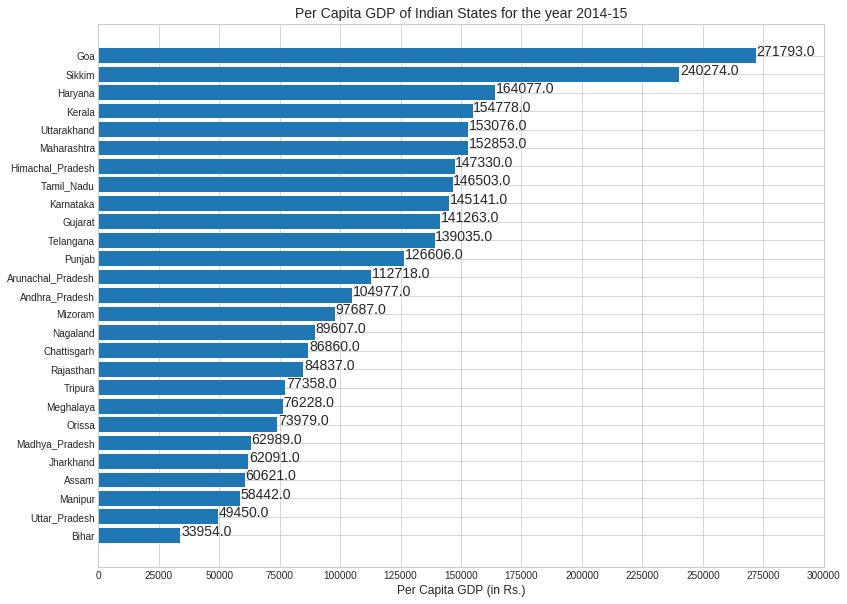

```python
# Setting the Figure Size:
plt.figure(figsize = (13,10))

# Defining the Axes:
x = per_capita_gdp['Per Capita GDP']
y = per_capita_gdp['State']

# We'll make a Horizontal Barchart to accomodate the State Names:
plt.barh(y, x)

# Defining ticks on the X-Axis, these will be used to annotate the graph in the next steps:
plt.xticks([0, 25000, 50000, 75000, 100000, 125000, 150000,
           175000, 200000, 225000, 250000, 275000, 300000])

# Labelling the axes and the plot:
fonts = {'size' : 14}
fonts_1 = {'size' : 12}

plt.xlabel('Per Capita GDP (in Rs.)', **fonts_1)
plt.title('Per Capita GDP of Indian States for the year 2014-15', **fonts)

# Annotating the Plot with custom formatting:

for i in per_capita_gdp['Per Capita GDP'].index:
    plt.annotate(str(per_capita_gdp['Per Capita GDP'][i]), (per_capita_gdp['Per Capita GDP'][i] + 300, i),**fonts)
```

The Top 5 states with regards to Per Capita GDP include:

1. Goa (272k)
2. Sikkim (240k)
3. Haryana (164k)
4. Kerala (155k)
5. Uttarakhand (153k)  
   It is surprising to see Goa top the list because it had the lowest growth rate of 6% which is half of the National Average 11.2%. Also Goa features in the bottom 10 states with regards to the Total Volume of GDP which is pegged around at 39k crores whereas for the 11th last state Himachal Pradesh has it around 88k crores which more than double.  
   Goa is the 4th least populous state in the country topped only by Anrunachal Pradesh, Mizoram and Sikkim, so it is not that much of a surprise for it to be the state with the highest Per Capita GDP.  
   The same is the case for Sikkim as well.  
   Kerala however emerges as the real topper of this list since it boasts a growth rate of 12.6% which is higher than the national average and at the same time it also features in the top 5 states by Volume of Total GDP.  
   Haryana and Uttarakhand have similar trajectories when it comes to % Growth which is around 11.8%, again slighlty greater than the national average. Also they have a decent volume of GDP to their credit.

The Bottom 5 states w.r.t Per Capita GDP include:

1. Bihar (34k)
2. Uttar Pradesh (49k)
3. Manipur (59k)
4. Assam (60.5k)
5. Jharkhand(62k)

Bihar and Uttar Pradesh top the list with the least Per Capita GDP, followed by Manipur, Assam and Jharkhand.  
As far as Bihar and Uttar Pradesh are concerned, their Total Volume of GDP and % Growth both feature in the top 50 percentile. However they are in the top 3 most populous state in India followed by Maharashtra at the second spot. This might be the reason as to why the Per Capita GDP takes a hit even with a decent overall performance.  
Assam and Jharkhand both have % Growth rates higher than the national average, however the Total GDP comes in at below 33 percentile which can be the reason for lower Per Capita GDP.

#### Ratio of Highest Per Capita GDP to the Lowest Per Capita GDP:

As seen from the plot above, the highest per capita GDP is Rs. 272000 for **Goa** and the lowest per capita GDP is around Rs. 34000 for **Bihar**

```python
# Calculating the ratio:
highest_to_lowest = per_capita_gdp['Per Capita GDP'].max() / per_capita_gdp['Per Capita GDP'].min()
highest_to_lowest  # 8.00
```

```
8.004741709371503
```

Considering the fact that India stands at 139th position out of 187 countries in the world w.r.t Per Capita GDP, a highest to lowest ratio of **8** shows that there is huge disparity even within the states of our country.  
It simply means that the average person in Goa seems to generate 8 times more value than a person in Bihar. This will also affect the Per Capita Income of people in the same manner.

### % Contribution of each Sector(Primary, Secondary and Tertiary) in the GDP of the State:

We started off with the DataFrame all_states_GSDP which contains the contribution of each major Sector i.e Prmary, Secondary and Tertiary in the Total GDP of the State

Let us take a look at the DataFrame

```python
all_states_GSDP
```

|  | S.No. | Sector | Andhra_Pradesh | Arunachal_Pradesh | Assam | Bihar | Chattisgarh | Goa | Gujarat | Haryana | ... | Nagaland | Orissa | Punjab | Rajasthan | Sikkim | Tamil_Nadu | Telangana | Tripura | Uttarakhand | Uttar_Pradesh |
| --- | --- | --- | --- | --- | --- | --- | --- | --- | --- | --- | --- | --- | --- | --- | --- | --- | --- | --- | --- | --- | --- |
| 0 | 1 | Agriculture, forestry and fishing | 14819416 | 686117 | 3855548 | 7951890 | 3948847 | 308507 | 13769969.00 | 8015238.0 | ... | 607897 | 6422978 | 9285716 | 15044394 | 137447 | 13064238 | 7591501 | 799825.0 | 1601423.0 | 25097754 |
| 1 | 1.1 | Crops | 7893514 | 415520 | 2890544 | 4688237 | 2613371 | 140421 | 9671086.00 | 4636731.0 | ... | 375825 | 4382636 | 5690972 | 7673441 | 114976 | 7297820 | 4162493 | 397591.0 | 866146.0 | 16215212 |
| 2 | 1.2 | Livestock | 4309078 | 38387 | 173478 | 2060296 | 352208 | 30141 | 2698910.00 | 2916173.0 | ... | 123800 | 788243 | 2638842 | 5356257 | 17338 | 4693361 | 2951299 | 88176.0 | 391188.0 | 7096876 |
| 3 | 1.3 | Forestry and logging | 346160 | 224017 | 261987 | 550132 | 597785 | 15744 | 761616.00 | 352254.0 | ... | 99802 | 791463 | 848245 | 1956660 | 4529 | 392705 | 210741 | 145096.0 | 339293.0 | 1404936 |
| 4 | 1.4 | Fishing and aquaculture | 2270664 | 8193 | 529539 | 653224 | 385483 | 122201 | 638357.00 | 110080.0 | ... | 8470 | 460636 | 107657 | 58036 | 604 | 680352 | 266968 | 168961.0 | 4796.0 | 380730 |
| 5 | 2 | Mining and quarrying | 1484300 | 30842 | 1471149 | 68107 | 2451970 | 3622 | 2117218.00 | 25186.0 | ... | 8280 | 2586328 | 10354 | 4069385 | 1329 | 265536 | 1541853 | 142391.0 | 244549.0 | 901501 |
| 6 | Total | Primary | 16303716 | 716959 | 5326697 | 8019997 | 6400817 | 312129 | 15887187.00 | 8040424.0 | ... | 616178 | 9009306 | 9296070 | 19113780 | 138776 | 13329774 | 9133354 | 942216.0 | 1845972.0 | 25999255 |
| 7 | 3 | Manufacturing | 4672266 | 26120 | 2002936 | 2189965 | 4370593 | 1177608 | 24087538.00 | 7756921.0 | ... | 18346 | 5754229 | 4790341 | 6552580 | 550697 | 18914794 | 6353711 | 228625.0 | 5866252.0 | 12261649 |
| 8 | 4 | Electricity, gas, water supply & other utility... | 1151729 | 113527 | 296587 | 345168 | 1198438 | 204110 | 3409983.00 | 1101919.0 | ... | 37944 | 833067 | 911611 | 1122888 | 212499 | 1710379 | 716266 | 77870.0 | 433880.0 | 2030625 |
| 9 | 5 | Construction | 4664889 | 147842 | 1733568 | 3449763 | 2669855 | 165819 | 5526017.00 | 3702571.0 | ... | 156072 | 2402396 | 2202962 | 5353326 | 82058 | 12216718 | 2854024 | 177899.0 | 1342733.0 | 11256450 |
| 10 | Total | Secondary | 10488884 | 287489 | 4033091 | 5984896 | 8238886 | 1547536 | 33023538.00 | 12561411.0 | ... | 212361 | 8989693 | 7904914 | 13028794 | 845253 | 32841892 | 9924001 | 484393.0 | 7642865.0 | 25548724 |
| 11 | 6 | Trade, repair, hotels and restaurants | 4233400 | 60421 | 2987155 | 7448373 | 1535571 | 380927 | 10178713.00 | 4986319.0 | ... | 140781 | 3149555 | 4419919 | 7297290 | 70568 | 12895842 | 6494607 | 390423.0 | 1743106.0 | 9437243 |
| 12 | 6.1 | Trade & repair services | 3716000 | 56796 | 2876251 | 7081391 | 1414164 | 343492 | 10178713.00 | 4817784.0 | ... | 134174 | 2886789 | 4201252 | 6942748 | 64624 | 11252588 | 5724128 | 390423.0 | 1534073.0 | 8476139 |
| 13 | 6.2 | Hotels & restaurants | 517400 | 3625 | 110904 | 366982 | 121407 | 37434 | NaN | 168535.0 | ... | 6607 | 262766 | 218667 | 354543 | 5945 | 1643253 | 770479 | NaN | 209033.0 | 961104 |
| 14 | 7 | Transport, storage, communication & services r... | 5076984 | 35203 | 1194568 | 3147173 | 871770 | 189656 | 4555910.00 | 2560623.0 | ... | 77521 | 2034016 | 1951809 | 3814461 | 47347 | 7188320 | 3604741 | 155956.0 | 1066693.0 | 7404509 |
| 15 | 7.1 | Railways | 424228 | 59 | 252509 | 462413 | 159176 | 15649 | 511593.00 | 423873.0 | ... | 336 | 341494 | 233389 | 464638 | 0 | 468553 | 199686 | 305.0 | 21295.0 | 1618742 |
| 16 | 7.2 | Road transport | 2816000 | 15467 | 507668 | 1572288 | 386628 | 46171 | NaN | 1452364.0 | ... | 34548 | 973144 | 928575 | 2121206 | 35283 | 3660994 | 2055658 | NaN | 307147.0 | 3645747 |
| 17 | 7.3 | Water transport | 94200 | 0 | 4502 | 2228 | 0 | 17820 | NaN | NaN | ... | 600 | 50349 | 0 | 0 | 0 | 70414 | 0 | NaN | NaN | 681 |
| 18 | 7.4 | Air transport | 14900 | 0 | 26223 | 13599 | 9507 | 46359 | NaN | NaN | ... | 4153 | 15354 | 4473 | 13469 | 0 | 180836 | 120691 | NaN | 3889.0 | 36582 |
| 19 | 7.5 | Services incidental to transport | 780200 | 109 | 35739 | 166600 | 5232 | 19272 | 2744163.00 | 190269.0 | ... | 0 | 117469 | 48124 | 47609 | 0 | 864407 | 454909 | 88721.0 | -76.0 | 16323 |
| 20 | 7.6 | Storage | 18700 | 0 | 10308 | 10618 | 16675 | 357 | 57634.00 | 14459.0 | ... | 89 | 22675 | 76429 | 16584 | 0 | 39834 | 19805 | 254.0 | 660.0 | 171696 |
| 21 | 7.7 | Communication & services related to broadcasting | 928756 | 19568 | 357619 | 919427 | 294552 | 44028 | 1242520.00 | 479658.0 | ... | 37794 | 513531 | 660819 | 1150955 | 12064 | 1903283 | 753992 | 66676.0 | 733778.0 | 1914737 |
| 22 | 8 | Financial services | 1900863 | 25207 | 543651 | 1178022 | 739057 | 233618 | 4606644.00 | 1671486.0 | ... | 60393 | 1065147 | 2057520 | 1827413 | 21079 | 5598498 | 3023729 | 86094.0 | 385030.0 | 3392275 |
| 23 | 9 | Real estate, ownership of dwelling & professio... | 4405409 | 48418 | 1412466 | 3740641 | 2462166 | 407099 | 5179502.00 | 6970183.0 | ... | 159651 | 2348714 | 3142786 | 6451997 | 75330 | 16830213 | 9478839 | 190704.0 | 831307.0 | 14548185 |
| 24 | 10 | Public administration | 2200897 | 243867 | 1373611 | 2078171 | 867982 | 346486 | 2576195.00 | 1036377.0 | ... | 295424 | 1318221 | 1842730 | 2460364 | 119514 | 3400800 | 1711265 | 338244.0 | 579409.0 | 6152124 |
| 25 | 11 | Other services | 4215389 | 218728 | 1795658 | 4587589 | 1112232 | 180431 | 3123413.00 | 2001581.0 | ... | 259186 | 2340603 | 3303041 | 4164287 | 149265 | 7430115 | 4158229 | 323287.0 | 982430.0 | 5034623 |
| 26 | Total | Tertiary | 22032942 | 631844 | 9307109 | 22179969 | 7588778 | 1738217 | 30220377.00 | 19226568.0 | ... | 992956 | 12256258 | 16717805 | 26015812 | 483103 | 53343788 | 28471410 | 1484709.0 | 5587975.0 | 45968959 |
| 27 | 12 | TOTAL GSVA at basic prices | 48825542 | 1636292 | 18666897 | 36184863 | 22228481 | 3597882 | 79131102.00 | 39828404.0 | ... | 1821495 | 30255256 | 33918789 | 58158386 | 1467133 | 99515453 | 47528765 | 2911319.0 | 15076812.0 | 97516938 |
| 28 | 13 | Taxes on Products | 5512100 | 70099 | 1725309 | 3213546 | 2601791 | 527279 | 12353171.04 | 4985670.0 | ... | 57674 | 3151184 | 3794100 | 5394503 | 72200 | 12507325 | 4425700 | 149345.0 | 1434856.0 | 10107396 |
| 29 | 14 | Subsidies on products | 1690800 | 30272 | 582406 | 2006421 | 1332092 | 61854 | 1981546.00 | 1067867.0 | ... | 37745 | 1209349 | 911800 | 2333442 | 18400 | 2766405 | 836700 | 94002.0 | 313139.0 | 3287219 |
| 30 | 15 | Gross State Domestic Product | 52646842 | 1676119 | 19809800 | 37391988 | 23498180 | 4063307 | 89502727.00 | 43746207.0 | ... | 1841424 | 32197092 | 36801089 | 61219447 | 1520933 | 109256373 | 51117765 | 2966662.0 | 16198529.0 | 104337115 |
| 31 | 16 | Population ('00) | 501510 | 14870 | 326780 | 1101240 | 270530 | 14950 | 633590.00 | 266620.0 | ... | 20550 | 435220 | 290673 | 721610 | 6330 | 745760 | 367660 | 38350.0 | 105820.0 | 2109940 |
| 32 | 17 | Per Capita GSDP (Rs.) | 104977 | 112718 | 60621 | 33954 | 86860 | 271793 | 141263.00 | 164077.0 | ... | 89607 | 73979 | 126606 | 84837 | 240274 | 146503 | 139035 | 77358.0 | 153076.0 | 49450 |

33 rows × 29 columns

Since we are only concerned with the three major Sectors and their contribution in the State's GDP, let us filter out the relevant rows into a new dataframe.

```python
major_sectors = all_states_GSDP[all_states_GSDP['Sector'].isin(['Primary','Secondary','Tertiary'])]
major_sectors
```

|  | S.No. | Sector | Andhra_Pradesh | Arunachal_Pradesh | Assam | Bihar | Chattisgarh | Goa | Gujarat | Haryana | ... | Nagaland | Orissa | Punjab | Rajasthan | Sikkim | Tamil_Nadu | Telangana | Tripura | Uttarakhand | Uttar_Pradesh |
| --- | --- | --- | --- | --- | --- | --- | --- | --- | --- | --- | --- | --- | --- | --- | --- | --- | --- | --- | --- | --- | --- |
| 6 | Total | Primary | 16303716 | 716959 | 5326697 | 8019997 | 6400817 | 312129 | 15887187.0 | 8040424.0 | ... | 616178 | 9009306 | 9296070 | 19113780 | 138776 | 13329774 | 9133354 | 942216.0 | 1845972.0 | 25999255 |
| 10 | Total | Secondary | 10488884 | 287489 | 4033091 | 5984896 | 8238886 | 1547536 | 33023538.0 | 12561411.0 | ... | 212361 | 8989693 | 7904914 | 13028794 | 845253 | 32841892 | 9924001 | 484393.0 | 7642865.0 | 25548724 |
| 26 | Total | Tertiary | 22032942 | 631844 | 9307109 | 22179969 | 7588778 | 1738217 | 30220377.0 | 19226568.0 | ... | 992956 | 12256258 | 16717805 | 26015812 | 483103 | 53343788 | 28471410 | 1484709.0 | 5587975.0 | 45968959 |

3 rows × 29 columns

Now we'll proceed with the same procedure for converting the Data to Long Format that will make it easier for us to slice and dice

```python
major_sectors = pd.melt(major_sectors, id_vars = ['S.No.', 'Sector'],
                        var_name = 'State', value_name = 'Amount')
major_sectors
```

|  | S.No. | Sector | State | Amount |
| --- | --- | --- | --- | --- |
| 0 | Total | Primary | Andhra_Pradesh | 16303716.0 |
| 1 | Total | Secondary | Andhra_Pradesh | 10488884.0 |
| 2 | Total | Tertiary | Andhra_Pradesh | 22032942.0 |
| 3 | Total | Primary | Arunachal_Pradesh | 716959.0 |
| 4 | Total | Secondary | Arunachal_Pradesh | 287489.0 |
| 5 | Total | Tertiary | Arunachal_Pradesh | 631844.0 |
| 6 | Total | Primary | Assam | 5326697.0 |
| 7 | Total | Secondary | Assam | 4033091.0 |
| 8 | Total | Tertiary | Assam | 9307109.0 |
| 9 | Total | Primary | Bihar | 8019997.0 |
| 10 | Total | Secondary | Bihar | 5984896.0 |
| 11 | Total | Tertiary | Bihar | 22179969.0 |
| 12 | Total | Primary | Chattisgarh | 6400817.0 |
| 13 | Total | Secondary | Chattisgarh | 8238886.0 |
| 14 | Total | Tertiary | Chattisgarh | 7588778.0 |
| 15 | Total | Primary | Goa | 312129.0 |
| 16 | Total | Secondary | Goa | 1547536.0 |
| 17 | Total | Tertiary | Goa | 1738217.0 |
| 18 | Total | Primary | Gujarat | 15887187.0 |
| 19 | Total | Secondary | Gujarat | 33023538.0 |
| 20 | Total | Tertiary | Gujarat | 30220377.0 |
| 21 | Total | Primary | Haryana | 8040424.0 |
| 22 | Total | Secondary | Haryana | 12561411.0 |
| 23 | Total | Tertiary | Haryana | 19226568.0 |
| 24 | Total | Primary | Himachal_Pradesh | 1548366.0 |
| 25 | Total | Secondary | Himachal_Pradesh | 4119162.0 |
| 26 | Total | Tertiary | Himachal_Pradesh | 4133326.0 |
| 27 | Total | Primary | Jharkhand | 5248354.0 |
| 28 | Total | Secondary | Jharkhand | 6241471.0 |
| 29 | Total | Tertiary | Jharkhand | 8133341.0 |
| ... | ... | ... | ... | ... |
| 51 | Total | Primary | Nagaland | 616178.0 |
| 52 | Total | Secondary | Nagaland | 212361.0 |
| 53 | Total | Tertiary | Nagaland | 992956.0 |
| 54 | Total | Primary | Orissa | 9009306.0 |
| 55 | Total | Secondary | Orissa | 8989693.0 |
| 56 | Total | Tertiary | Orissa | 12256258.0 |
| 57 | Total | Primary | Punjab | 9296070.0 |
| 58 | Total | Secondary | Punjab | 7904914.0 |
| 59 | Total | Tertiary | Punjab | 16717805.0 |
| 60 | Total | Primary | Rajasthan | 19113780.0 |
| 61 | Total | Secondary | Rajasthan | 13028794.0 |
| 62 | Total | Tertiary | Rajasthan | 26015812.0 |
| 63 | Total | Primary | Sikkim | 138776.0 |
| 64 | Total | Secondary | Sikkim | 845253.0 |
| 65 | Total | Tertiary | Sikkim | 483103.0 |
| 66 | Total | Primary | Tamil_Nadu | 13329774.0 |
| 67 | Total | Secondary | Tamil_Nadu | 32841892.0 |
| 68 | Total | Tertiary | Tamil_Nadu | 53343788.0 |
| 69 | Total | Primary | Telangana | 9133354.0 |
| 70 | Total | Secondary | Telangana | 9924001.0 |
| 71 | Total | Tertiary | Telangana | 28471410.0 |
| 72 | Total | Primary | Tripura | 942216.0 |
| 73 | Total | Secondary | Tripura | 484393.0 |
| 74 | Total | Tertiary | Tripura | 1484709.0 |
| 75 | Total | Primary | Uttarakhand | 1845972.0 |
| 76 | Total | Secondary | Uttarakhand | 7642865.0 |
| 77 | Total | Tertiary | Uttarakhand | 5587975.0 |
| 78 | Total | Primary | Uttar_Pradesh | 25999255.0 |
| 79 | Total | Secondary | Uttar_Pradesh | 25548724.0 |
| 80 | Total | Tertiary | Uttar_Pradesh | 45968959.0 |

81 rows × 4 columns

The ultimate goal is to have a DataFrame that contains the % Contribution for each of the Sectors, therefore we'll need to divide the 'Amount' contributed by each Sector with the Total GDP of that State and then mulitply it by 100 to get the % Contribution.  
Let us create a new DataFrame which contains only the Total GDP of each State and then join it with the above mentioned 'major_sectors' DataFrame. Then we can easily add a calculated field/column for the '% Contribution'

```python
GDSP_14_15 = all_states_GSDP[all_states_GSDP['Sector']=='Gross State Domestic Product']
GDSP_14_15
```

|  | S.No. | Sector | Andhra_Pradesh | Arunachal_Pradesh | Assam | Bihar | Chattisgarh | Goa | Gujarat | Haryana | ... | Nagaland | Orissa | Punjab | Rajasthan | Sikkim | Tamil_Nadu | Telangana | Tripura | Uttarakhand | Uttar_Pradesh |
| --- | --- | --- | --- | --- | --- | --- | --- | --- | --- | --- | --- | --- | --- | --- | --- | --- | --- | --- | --- | --- | --- |
| 30 | 15 | Gross State Domestic Product | 52646842 | 1676119 | 19809800 | 37391988 | 23498180 | 4063307 | 89502727.0 | 43746207.0 | ... | 1841424 | 32197092 | 36801089 | 61219447 | 1520933 | 109256373 | 51117765 | 2966662.0 | 16198529.0 | 104337115 |

1 rows × 29 columns

```python
# Converting the Data to Long-Format:
GDSP_14_15 = pd.melt(GDSP_14_15, id_vars = ['S.No.', 'Sector'], var_name = 'State', value_name = 'Value')
GDSP_14_15
```

|  | S.No. | Sector | State | Value |
| --- | --- | --- | --- | --- |
| 0 | 15 | Gross State Domestic Product | Andhra_Pradesh | 52646842.0 |
| 1 | 15 | Gross State Domestic Product | Arunachal_Pradesh | 1676119.0 |
| 2 | 15 | Gross State Domestic Product | Assam | 19809800.0 |
| 3 | 15 | Gross State Domestic Product | Bihar | 37391988.0 |
| 4 | 15 | Gross State Domestic Product | Chattisgarh | 23498180.0 |
| 5 | 15 | Gross State Domestic Product | Goa | 4063307.0 |
| 6 | 15 | Gross State Domestic Product | Gujarat | 89502727.0 |
| 7 | 15 | Gross State Domestic Product | Haryana | 43746207.0 |
| 8 | 15 | Gross State Domestic Product | Himachal_Pradesh | 10436879.0 |
| 9 | 15 | Gross State Domestic Product | Jharkhand | 21710718.0 |
| 10 | 15 | Gross State Domestic Product | Karnataka | 92178806.0 |
| 11 | 15 | Gross State Domestic Product | Kerala | 52600230.0 |
| 12 | 15 | Gross State Domestic Product | Madhya_Pradesh | 48198169.0 |
| 13 | 15 | Gross State Domestic Product | Maharashtra | 179212165.0 |
| 14 | 15 | Gross State Domestic Product | Meghalaya | 2440807.0 |
| 15 | 15 | Gross State Domestic Product | Mizoram | 1155933.0 |
| 16 | 15 | Gross State Domestic Product | Manipur | 1804276.0 |
| 17 | 15 | Gross State Domestic Product | Nagaland | 1841424.0 |
| 18 | 15 | Gross State Domestic Product | Orissa | 32197092.0 |
| 19 | 15 | Gross State Domestic Product | Punjab | 36801089.0 |
| 20 | 15 | Gross State Domestic Product | Rajasthan | 61219447.0 |
| 21 | 15 | Gross State Domestic Product | Sikkim | 1520933.0 |
| 22 | 15 | Gross State Domestic Product | Tamil_Nadu | 109256373.0 |
| 23 | 15 | Gross State Domestic Product | Telangana | 51117765.0 |
| 24 | 15 | Gross State Domestic Product | Tripura | 2966662.0 |
| 25 | 15 | Gross State Domestic Product | Uttarakhand | 16198529.0 |
| 26 | 15 | Gross State Domestic Product | Uttar_Pradesh | 104337115.0 |

Let us now Merge the Two DataFrames 'major_sectors' and 'GDSP_14_15'

```python
major_sectors = major_sectors.merge(GDSP_14_15, on = 'State', how = 'inner')
major_sectors
```

|  | S.No._x | Sector_x | State | Amount | S.No._y | Sector_y | Value |
| --- | --- | --- | --- | --- | --- | --- | --- |
| 0 | Total | Primary | Andhra_Pradesh | 16303716.0 | 15 | Gross State Domestic Product | 52646842.0 |
| 1 | Total | Secondary | Andhra_Pradesh | 10488884.0 | 15 | Gross State Domestic Product | 52646842.0 |
| 2 | Total | Tertiary | Andhra_Pradesh | 22032942.0 | 15 | Gross State Domestic Product | 52646842.0 |
| 3 | Total | Primary | Arunachal_Pradesh | 716959.0 | 15 | Gross State Domestic Product | 1676119.0 |
| 4 | Total | Secondary | Arunachal_Pradesh | 287489.0 | 15 | Gross State Domestic Product | 1676119.0 |
| 5 | Total | Tertiary | Arunachal_Pradesh | 631844.0 | 15 | Gross State Domestic Product | 1676119.0 |
| 6 | Total | Primary | Assam | 5326697.0 | 15 | Gross State Domestic Product | 19809800.0 |
| 7 | Total | Secondary | Assam | 4033091.0 | 15 | Gross State Domestic Product | 19809800.0 |
| 8 | Total | Tertiary | Assam | 9307109.0 | 15 | Gross State Domestic Product | 19809800.0 |
| 9 | Total | Primary | Bihar | 8019997.0 | 15 | Gross State Domestic Product | 37391988.0 |
| 10 | Total | Secondary | Bihar | 5984896.0 | 15 | Gross State Domestic Product | 37391988.0 |
| 11 | Total | Tertiary | Bihar | 22179969.0 | 15 | Gross State Domestic Product | 37391988.0 |
| 12 | Total | Primary | Chattisgarh | 6400817.0 | 15 | Gross State Domestic Product | 23498180.0 |
| 13 | Total | Secondary | Chattisgarh | 8238886.0 | 15 | Gross State Domestic Product | 23498180.0 |
| 14 | Total | Tertiary | Chattisgarh | 7588778.0 | 15 | Gross State Domestic Product | 23498180.0 |
| 15 | Total | Primary | Goa | 312129.0 | 15 | Gross State Domestic Product | 4063307.0 |
| 16 | Total | Secondary | Goa | 1547536.0 | 15 | Gross State Domestic Product | 4063307.0 |
| 17 | Total | Tertiary | Goa | 1738217.0 | 15 | Gross State Domestic Product | 4063307.0 |
| 18 | Total | Primary | Gujarat | 15887187.0 | 15 | Gross State Domestic Product | 89502727.0 |
| 19 | Total | Secondary | Gujarat | 33023538.0 | 15 | Gross State Domestic Product | 89502727.0 |
| 20 | Total | Tertiary | Gujarat | 30220377.0 | 15 | Gross State Domestic Product | 89502727.0 |
| 21 | Total | Primary | Haryana | 8040424.0 | 15 | Gross State Domestic Product | 43746207.0 |
| 22 | Total | Secondary | Haryana | 12561411.0 | 15 | Gross State Domestic Product | 43746207.0 |
| 23 | Total | Tertiary | Haryana | 19226568.0 | 15 | Gross State Domestic Product | 43746207.0 |
| 24 | Total | Primary | Himachal_Pradesh | 1548366.0 | 15 | Gross State Domestic Product | 10436879.0 |
| 25 | Total | Secondary | Himachal_Pradesh | 4119162.0 | 15 | Gross State Domestic Product | 10436879.0 |
| 26 | Total | Tertiary | Himachal_Pradesh | 4133326.0 | 15 | Gross State Domestic Product | 10436879.0 |
| 27 | Total | Primary | Jharkhand | 5248354.0 | 15 | Gross State Domestic Product | 21710718.0 |
| 28 | Total | Secondary | Jharkhand | 6241471.0 | 15 | Gross State Domestic Product | 21710718.0 |
| 29 | Total | Tertiary | Jharkhand | 8133341.0 | 15 | Gross State Domestic Product | 21710718.0 |
| ... | ... | ... | ... | ... | ... | ... | ... |
| 51 | Total | Primary | Nagaland | 616178.0 | 15 | Gross State Domestic Product | 1841424.0 |
| 52 | Total | Secondary | Nagaland | 212361.0 | 15 | Gross State Domestic Product | 1841424.0 |
| 53 | Total | Tertiary | Nagaland | 992956.0 | 15 | Gross State Domestic Product | 1841424.0 |
| 54 | Total | Primary | Orissa | 9009306.0 | 15 | Gross State Domestic Product | 32197092.0 |
| 55 | Total | Secondary | Orissa | 8989693.0 | 15 | Gross State Domestic Product | 32197092.0 |
| 56 | Total | Tertiary | Orissa | 12256258.0 | 15 | Gross State Domestic Product | 32197092.0 |
| 57 | Total | Primary | Punjab | 9296070.0 | 15 | Gross State Domestic Product | 36801089.0 |
| 58 | Total | Secondary | Punjab | 7904914.0 | 15 | Gross State Domestic Product | 36801089.0 |
| 59 | Total | Tertiary | Punjab | 16717805.0 | 15 | Gross State Domestic Product | 36801089.0 |
| 60 | Total | Primary | Rajasthan | 19113780.0 | 15 | Gross State Domestic Product | 61219447.0 |
| 61 | Total | Secondary | Rajasthan | 13028794.0 | 15 | Gross State Domestic Product | 61219447.0 |
| 62 | Total | Tertiary | Rajasthan | 26015812.0 | 15 | Gross State Domestic Product | 61219447.0 |
| 63 | Total | Primary | Sikkim | 138776.0 | 15 | Gross State Domestic Product | 1520933.0 |
| 64 | Total | Secondary | Sikkim | 845253.0 | 15 | Gross State Domestic Product | 1520933.0 |
| 65 | Total | Tertiary | Sikkim | 483103.0 | 15 | Gross State Domestic Product | 1520933.0 |
| 66 | Total | Primary | Tamil_Nadu | 13329774.0 | 15 | Gross State Domestic Product | 109256373.0 |
| 67 | Total | Secondary | Tamil_Nadu | 32841892.0 | 15 | Gross State Domestic Product | 109256373.0 |
| 68 | Total | Tertiary | Tamil_Nadu | 53343788.0 | 15 | Gross State Domestic Product | 109256373.0 |
| 69 | Total | Primary | Telangana | 9133354.0 | 15 | Gross State Domestic Product | 51117765.0 |
| 70 | Total | Secondary | Telangana | 9924001.0 | 15 | Gross State Domestic Product | 51117765.0 |
| 71 | Total | Tertiary | Telangana | 28471410.0 | 15 | Gross State Domestic Product | 51117765.0 |
| 72 | Total | Primary | Tripura | 942216.0 | 15 | Gross State Domestic Product | 2966662.0 |
| 73 | Total | Secondary | Tripura | 484393.0 | 15 | Gross State Domestic Product | 2966662.0 |
| 74 | Total | Tertiary | Tripura | 1484709.0 | 15 | Gross State Domestic Product | 2966662.0 |
| 75 | Total | Primary | Uttarakhand | 1845972.0 | 15 | Gross State Domestic Product | 16198529.0 |
| 76 | Total | Secondary | Uttarakhand | 7642865.0 | 15 | Gross State Domestic Product | 16198529.0 |
| 77 | Total | Tertiary | Uttarakhand | 5587975.0 | 15 | Gross State Domestic Product | 16198529.0 |
| 78 | Total | Primary | Uttar_Pradesh | 25999255.0 | 15 | Gross State Domestic Product | 104337115.0 |
| 79 | Total | Secondary | Uttar_Pradesh | 25548724.0 | 15 | Gross State Domestic Product | 104337115.0 |
| 80 | Total | Tertiary | Uttar_Pradesh | 45968959.0 | 15 | Gross State Domestic Product | 104337115.0 |

81 rows × 7 columns

One glance at the new DataFrame and we can easily see that there are columns which do not add any value and hence can safely be dropped. Also some columns can be renamed so that the Data becomes easy to read.

```python
# Dropping the S.No and Sector_y columns:
cols = ['S.No._x', 'S.No._y', 'Sector_y']
major_sectors.drop(cols, axis = 'columns', inplace = True)
major_sectors
```

|  | Sector_x | State | Amount | Value |
| --- | --- | --- | --- | --- |
| 0 | Primary | Andhra_Pradesh | 16303716.0 | 52646842.0 |
| 1 | Secondary | Andhra_Pradesh | 10488884.0 | 52646842.0 |
| 2 | Tertiary | Andhra_Pradesh | 22032942.0 | 52646842.0 |
| 3 | Primary | Arunachal_Pradesh | 716959.0 | 1676119.0 |
| 4 | Secondary | Arunachal_Pradesh | 287489.0 | 1676119.0 |
| 5 | Tertiary | Arunachal_Pradesh | 631844.0 | 1676119.0 |
| 6 | Primary | Assam | 5326697.0 | 19809800.0 |
| 7 | Secondary | Assam | 4033091.0 | 19809800.0 |
| 8 | Tertiary | Assam | 9307109.0 | 19809800.0 |
| 9 | Primary | Bihar | 8019997.0 | 37391988.0 |
| 10 | Secondary | Bihar | 5984896.0 | 37391988.0 |
| 11 | Tertiary | Bihar | 22179969.0 | 37391988.0 |
| 12 | Primary | Chattisgarh | 6400817.0 | 23498180.0 |
| 13 | Secondary | Chattisgarh | 8238886.0 | 23498180.0 |
| 14 | Tertiary | Chattisgarh | 7588778.0 | 23498180.0 |
| 15 | Primary | Goa | 312129.0 | 4063307.0 |
| 16 | Secondary | Goa | 1547536.0 | 4063307.0 |
| 17 | Tertiary | Goa | 1738217.0 | 4063307.0 |
| 18 | Primary | Gujarat | 15887187.0 | 89502727.0 |
| 19 | Secondary | Gujarat | 33023538.0 | 89502727.0 |
| 20 | Tertiary | Gujarat | 30220377.0 | 89502727.0 |
| 21 | Primary | Haryana | 8040424.0 | 43746207.0 |
| 22 | Secondary | Haryana | 12561411.0 | 43746207.0 |
| 23 | Tertiary | Haryana | 19226568.0 | 43746207.0 |
| 24 | Primary | Himachal_Pradesh | 1548366.0 | 10436879.0 |
| 25 | Secondary | Himachal_Pradesh | 4119162.0 | 10436879.0 |
| 26 | Tertiary | Himachal_Pradesh | 4133326.0 | 10436879.0 |
| 27 | Primary | Jharkhand | 5248354.0 | 21710718.0 |
| 28 | Secondary | Jharkhand | 6241471.0 | 21710718.0 |
| 29 | Tertiary | Jharkhand | 8133341.0 | 21710718.0 |
| ... | ... | ... | ... | ... |
| 51 | Primary | Nagaland | 616178.0 | 1841424.0 |
| 52 | Secondary | Nagaland | 212361.0 | 1841424.0 |
| 53 | Tertiary | Nagaland | 992956.0 | 1841424.0 |
| 54 | Primary | Orissa | 9009306.0 | 32197092.0 |
| 55 | Secondary | Orissa | 8989693.0 | 32197092.0 |
| 56 | Tertiary | Orissa | 12256258.0 | 32197092.0 |
| 57 | Primary | Punjab | 9296070.0 | 36801089.0 |
| 58 | Secondary | Punjab | 7904914.0 | 36801089.0 |
| 59 | Tertiary | Punjab | 16717805.0 | 36801089.0 |
| 60 | Primary | Rajasthan | 19113780.0 | 61219447.0 |
| 61 | Secondary | Rajasthan | 13028794.0 | 61219447.0 |
| 62 | Tertiary | Rajasthan | 26015812.0 | 61219447.0 |
| 63 | Primary | Sikkim | 138776.0 | 1520933.0 |
| 64 | Secondary | Sikkim | 845253.0 | 1520933.0 |
| 65 | Tertiary | Sikkim | 483103.0 | 1520933.0 |
| 66 | Primary | Tamil_Nadu | 13329774.0 | 109256373.0 |
| 67 | Secondary | Tamil_Nadu | 32841892.0 | 109256373.0 |
| 68 | Tertiary | Tamil_Nadu | 53343788.0 | 109256373.0 |
| 69 | Primary | Telangana | 9133354.0 | 51117765.0 |
| 70 | Secondary | Telangana | 9924001.0 | 51117765.0 |
| 71 | Tertiary | Telangana | 28471410.0 | 51117765.0 |
| 72 | Primary | Tripura | 942216.0 | 2966662.0 |
| 73 | Secondary | Tripura | 484393.0 | 2966662.0 |
| 74 | Tertiary | Tripura | 1484709.0 | 2966662.0 |
| 75 | Primary | Uttarakhand | 1845972.0 | 16198529.0 |
| 76 | Secondary | Uttarakhand | 7642865.0 | 16198529.0 |
| 77 | Tertiary | Uttarakhand | 5587975.0 | 16198529.0 |
| 78 | Primary | Uttar_Pradesh | 25999255.0 | 104337115.0 |
| 79 | Secondary | Uttar_Pradesh | 25548724.0 | 104337115.0 |
| 80 | Tertiary | Uttar_Pradesh | 45968959.0 | 104337115.0 |

81 rows × 4 columns

```python
# Renaming the columns:
major_sectors.rename(columns = {'Sector_x' : 'Sector',
                                'Amount' : 'Sector_Amount',
                                'Value' : 'Total GDP'}, inplace = True)
major_sectors
```

|  | Sector | State | Sector_Amount | Total GDP |
| --- | --- | --- | --- | --- |
| 0 | Primary | Andhra_Pradesh | 16303716.0 | 52646842.0 |
| 1 | Secondary | Andhra_Pradesh | 10488884.0 | 52646842.0 |
| 2 | Tertiary | Andhra_Pradesh | 22032942.0 | 52646842.0 |
| 3 | Primary | Arunachal_Pradesh | 716959.0 | 1676119.0 |
| 4 | Secondary | Arunachal_Pradesh | 287489.0 | 1676119.0 |
| 5 | Tertiary | Arunachal_Pradesh | 631844.0 | 1676119.0 |
| 6 | Primary | Assam | 5326697.0 | 19809800.0 |
| 7 | Secondary | Assam | 4033091.0 | 19809800.0 |
| 8 | Tertiary | Assam | 9307109.0 | 19809800.0 |
| 9 | Primary | Bihar | 8019997.0 | 37391988.0 |
| 10 | Secondary | Bihar | 5984896.0 | 37391988.0 |
| 11 | Tertiary | Bihar | 22179969.0 | 37391988.0 |
| 12 | Primary | Chattisgarh | 6400817.0 | 23498180.0 |
| 13 | Secondary | Chattisgarh | 8238886.0 | 23498180.0 |
| 14 | Tertiary | Chattisgarh | 7588778.0 | 23498180.0 |
| 15 | Primary | Goa | 312129.0 | 4063307.0 |
| 16 | Secondary | Goa | 1547536.0 | 4063307.0 |
| 17 | Tertiary | Goa | 1738217.0 | 4063307.0 |
| 18 | Primary | Gujarat | 15887187.0 | 89502727.0 |
| 19 | Secondary | Gujarat | 33023538.0 | 89502727.0 |
| 20 | Tertiary | Gujarat | 30220377.0 | 89502727.0 |
| 21 | Primary | Haryana | 8040424.0 | 43746207.0 |
| 22 | Secondary | Haryana | 12561411.0 | 43746207.0 |
| 23 | Tertiary | Haryana | 19226568.0 | 43746207.0 |
| 24 | Primary | Himachal_Pradesh | 1548366.0 | 10436879.0 |
| 25 | Secondary | Himachal_Pradesh | 4119162.0 | 10436879.0 |
| 26 | Tertiary | Himachal_Pradesh | 4133326.0 | 10436879.0 |
| 27 | Primary | Jharkhand | 5248354.0 | 21710718.0 |
| 28 | Secondary | Jharkhand | 6241471.0 | 21710718.0 |
| 29 | Tertiary | Jharkhand | 8133341.0 | 21710718.0 |
| ... | ... | ... | ... | ... |
| 51 | Primary | Nagaland | 616178.0 | 1841424.0 |
| 52 | Secondary | Nagaland | 212361.0 | 1841424.0 |
| 53 | Tertiary | Nagaland | 992956.0 | 1841424.0 |
| 54 | Primary | Orissa | 9009306.0 | 32197092.0 |
| 55 | Secondary | Orissa | 8989693.0 | 32197092.0 |
| 56 | Tertiary | Orissa | 12256258.0 | 32197092.0 |
| 57 | Primary | Punjab | 9296070.0 | 36801089.0 |
| 58 | Secondary | Punjab | 7904914.0 | 36801089.0 |
| 59 | Tertiary | Punjab | 16717805.0 | 36801089.0 |
| 60 | Primary | Rajasthan | 19113780.0 | 61219447.0 |
| 61 | Secondary | Rajasthan | 13028794.0 | 61219447.0 |
| 62 | Tertiary | Rajasthan | 26015812.0 | 61219447.0 |
| 63 | Primary | Sikkim | 138776.0 | 1520933.0 |
| 64 | Secondary | Sikkim | 845253.0 | 1520933.0 |
| 65 | Tertiary | Sikkim | 483103.0 | 1520933.0 |
| 66 | Primary | Tamil_Nadu | 13329774.0 | 109256373.0 |
| 67 | Secondary | Tamil_Nadu | 32841892.0 | 109256373.0 |
| 68 | Tertiary | Tamil_Nadu | 53343788.0 | 109256373.0 |
| 69 | Primary | Telangana | 9133354.0 | 51117765.0 |
| 70 | Secondary | Telangana | 9924001.0 | 51117765.0 |
| 71 | Tertiary | Telangana | 28471410.0 | 51117765.0 |
| 72 | Primary | Tripura | 942216.0 | 2966662.0 |
| 73 | Secondary | Tripura | 484393.0 | 2966662.0 |
| 74 | Tertiary | Tripura | 1484709.0 | 2966662.0 |
| 75 | Primary | Uttarakhand | 1845972.0 | 16198529.0 |
| 76 | Secondary | Uttarakhand | 7642865.0 | 16198529.0 |
| 77 | Tertiary | Uttarakhand | 5587975.0 | 16198529.0 |
| 78 | Primary | Uttar_Pradesh | 25999255.0 | 104337115.0 |
| 79 | Secondary | Uttar_Pradesh | 25548724.0 | 104337115.0 |
| 80 | Tertiary | Uttar_Pradesh | 45968959.0 | 104337115.0 |

81 rows × 4 columns

Now all that's left is to add a new column '% Contribution' that will be calculated as:  
('Sector_Amount' / 'Total_GDP') * 100

```python
major_sectors['% Contribution'] = major_sectors['Sector_Amount'] / major_sectors['Total GDP'] * 100
major_sectors
```

|  | Sector | State | Sector_Amount | Total GDP | % Contribution |
| --- | --- | --- | --- | --- | --- |
| 0 | Primary | Andhra_Pradesh | 16303716.0 | 52646842.0 | 30.968080 |
| 1 | Secondary | Andhra_Pradesh | 10488884.0 | 52646842.0 | 19.923102 |
| 2 | Tertiary | Andhra_Pradesh | 22032942.0 | 52646842.0 | 41.850453 |
| 3 | Primary | Arunachal_Pradesh | 716959.0 | 1676119.0 | 42.774946 |
| 4 | Secondary | Arunachal_Pradesh | 287489.0 | 1676119.0 | 17.152064 |
| 5 | Tertiary | Arunachal_Pradesh | 631844.0 | 1676119.0 | 37.696846 |
| 6 | Primary | Assam | 5326697.0 | 19809800.0 | 26.889201 |
| 7 | Secondary | Assam | 4033091.0 | 19809800.0 | 20.359070 |
| 8 | Tertiary | Assam | 9307109.0 | 19809800.0 | 46.982347 |
| 9 | Primary | Bihar | 8019997.0 | 37391988.0 | 21.448437 |
| 10 | Secondary | Bihar | 5984896.0 | 37391988.0 | 16.005825 |
| 11 | Tertiary | Bihar | 22179969.0 | 37391988.0 | 59.317437 |
| 12 | Primary | Chattisgarh | 6400817.0 | 23498180.0 | 27.239629 |
| 13 | Secondary | Chattisgarh | 8238886.0 | 23498180.0 | 35.061805 |
| 14 | Tertiary | Chattisgarh | 7588778.0 | 23498180.0 | 32.295173 |
| 15 | Primary | Goa | 312129.0 | 4063307.0 | 7.681649 |
| 16 | Secondary | Goa | 1547536.0 | 4063307.0 | 38.085628 |
| 17 | Tertiary | Goa | 1738217.0 | 4063307.0 | 42.778382 |
| 18 | Primary | Gujarat | 15887187.0 | 89502727.0 | 17.750506 |
| 19 | Secondary | Gujarat | 33023538.0 | 89502727.0 | 36.896684 |
| 20 | Tertiary | Gujarat | 30220377.0 | 89502727.0 | 33.764756 |
| 21 | Primary | Haryana | 8040424.0 | 43746207.0 | 18.379705 |
| 22 | Secondary | Haryana | 12561411.0 | 43746207.0 | 28.714286 |
| 23 | Tertiary | Haryana | 19226568.0 | 43746207.0 | 43.950252 |
| 24 | Primary | Himachal_Pradesh | 1548366.0 | 10436879.0 | 14.835527 |
| 25 | Secondary | Himachal_Pradesh | 4119162.0 | 10436879.0 | 39.467373 |
| 26 | Tertiary | Himachal_Pradesh | 4133326.0 | 10436879.0 | 39.603084 |
| 27 | Primary | Jharkhand | 5248354.0 | 21710718.0 | 24.174023 |
| 28 | Secondary | Jharkhand | 6241471.0 | 21710718.0 | 28.748340 |
| 29 | Tertiary | Jharkhand | 8133341.0 | 21710718.0 | 37.462331 |
| ... | ... | ... | ... | ... | ... |
| 51 | Primary | Nagaland | 616178.0 | 1841424.0 | 33.462038 |
| 52 | Secondary | Nagaland | 212361.0 | 1841424.0 | 11.532434 |
| 53 | Tertiary | Nagaland | 992956.0 | 1841424.0 | 53.923268 |
| 54 | Primary | Orissa | 9009306.0 | 32197092.0 | 27.981738 |
| 55 | Secondary | Orissa | 8989693.0 | 32197092.0 | 27.920823 |
| 56 | Tertiary | Orissa | 12256258.0 | 32197092.0 | 38.066351 |
| 57 | Primary | Punjab | 9296070.0 | 36801089.0 | 25.260312 |
| 58 | Secondary | Punjab | 7904914.0 | 36801089.0 | 21.480109 |
| 59 | Tertiary | Punjab | 16717805.0 | 36801089.0 | 45.427474 |
| 60 | Primary | Rajasthan | 19113780.0 | 61219447.0 | 31.221746 |
| 61 | Secondary | Rajasthan | 13028794.0 | 61219447.0 | 21.282116 |
| 62 | Tertiary | Rajasthan | 26015812.0 | 61219447.0 | 42.495993 |
| 63 | Primary | Sikkim | 138776.0 | 1520933.0 | 9.124399 |
| 64 | Secondary | Sikkim | 845253.0 | 1520933.0 | 55.574637 |
| 65 | Tertiary | Sikkim | 483103.0 | 1520933.0 | 31.763595 |
| 66 | Primary | Tamil_Nadu | 13329774.0 | 109256373.0 | 12.200454 |
| 67 | Secondary | Tamil_Nadu | 32841892.0 | 109256373.0 | 30.059475 |
| 68 | Tertiary | Tamil_Nadu | 53343788.0 | 109256373.0 | 48.824418 |
| 69 | Primary | Telangana | 9133354.0 | 51117765.0 | 17.867280 |
| 70 | Secondary | Telangana | 9924001.0 | 51117765.0 | 19.413996 |
| 71 | Tertiary | Telangana | 28471410.0 | 51117765.0 | 55.697682 |
| 72 | Primary | Tripura | 942216.0 | 2966662.0 | 31.760140 |
| 73 | Secondary | Tripura | 484393.0 | 2966662.0 | 16.327880 |
| 74 | Tertiary | Tripura | 1484709.0 | 2966662.0 | 50.046450 |
| 75 | Primary | Uttarakhand | 1845972.0 | 16198529.0 | 11.395924 |
| 76 | Secondary | Uttarakhand | 7642865.0 | 16198529.0 | 47.182463 |
| 77 | Tertiary | Uttarakhand | 5587975.0 | 16198529.0 | 34.496805 |
| 78 | Primary | Uttar_Pradesh | 25999255.0 | 104337115.0 | 24.918511 |
| 79 | Secondary | Uttar_Pradesh | 25548724.0 | 104337115.0 | 24.486707 |
| 80 | Tertiary | Uttar_Pradesh | 45968959.0 | 104337115.0 | 44.058108 |

81 rows × 5 columns

Plotting for the above data can be done in 2 ways:

1. Complete picture in which we have the % contribution off all the States in a single plot.
2. Making 3 different subplots for each of the sectors.

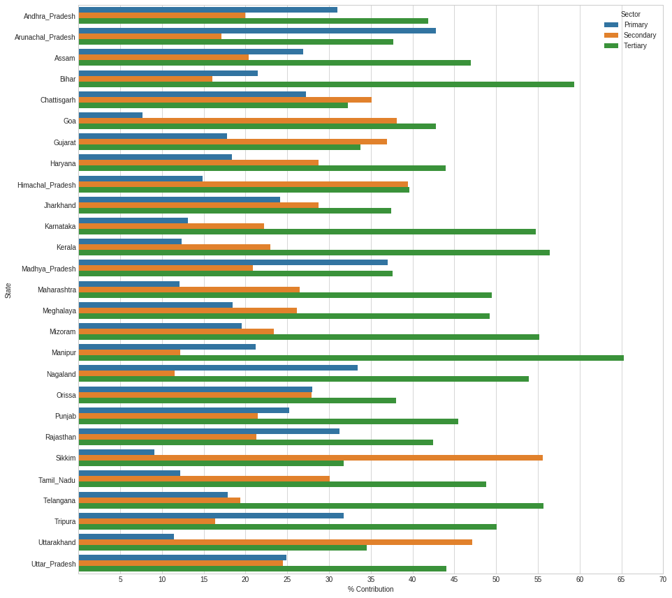

```python
# Complete overview:

# Defining the figure size and the styling:
plt.figure(figsize = (15,15))
plt.style.use('seaborn-whitegrid')

# Defining the plot to be used:
sns.barplot('% Contribution', 'State', hue = 'Sector', data = major_sectors)

# Defining the ticks on both the axes so that the plot is easy to read.
plt.xticks([5,10,15,20,25,30,35,40,45,50,55,60,65,70])
plt.yticks([0,1,2,3,4,5,6,7,8,9,10,11,12,13,14,15,16,17,18,19,20,21,22,23,24,25,26])
plt.show()
```

The above plot is useful when you need to compare multiple States without toggling through the plots, however it looks congested and is hard to consume.  
Let us now make 3 different subplots for each of the Sectors:

```
Text(0.5,1,'% Contribution of Tertiary Sector in GSDP')
```

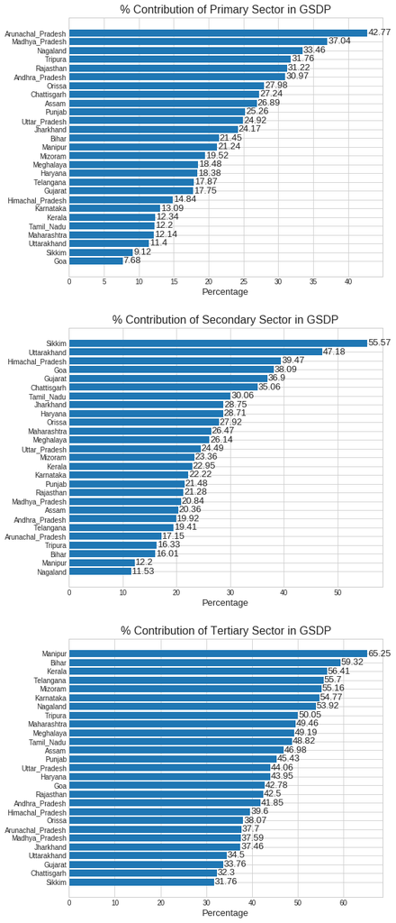

```python
# Primary Sector:

# Defining a new DataFrame that only contains data pertaining to the Primary sector:
primary = major_sectors[major_sectors['Sector'] == 'Primary']
primary = primary.sort_values('% Contribution')
primary = primary.reset_index(drop = True)

# Defining the Figure size and the plot axes:
plt.figure(figsize = (8,23))
plt.subplot(311)
x_1 = primary['% Contribution']
y_1 = primary['State']
plt.barh(y_1,x_1)
plt.yticks([0,1,2,3,4,5,6,7,8,9,10,11,12,13,14,15,16,17,18,19,20,21,22,23,24,25,26])

# Annotating the plot:
fonts_1 = {'size' : 13}

for i in primary['% Contribution'].index:
    plt.annotate(str(primary['% Contribution'][i].round(2)), (primary['% Contribution'][i] + 0.10, i - 0.25),
                 **fonts_1 )

plt.xlabel('Percentage', **fonts_1)
fonts_2 = {'size' : 16}
plt.title('% Contribution of Primary Sector in GSDP', **fonts_2)



# Secondary Sector:
secondary = major_sectors[major_sectors['Sector'] == 'Secondary']
secondary = secondary.sort_values('% Contribution')
secondary = secondary.reset_index(drop = True)

plt.subplot(312)
x_2 = secondary['% Contribution']
y_2 = secondary['State']
plt.barh(y_2,x_2)
plt.yticks([0,1,2,3,4,5,6,7,8,9,10,11,12,13,14,15,16,17,18,19,20,21,22,23,24,25,26])

for i in secondary['% Contribution'].index:
    plt.annotate(str(secondary['% Contribution'][i].round(2)), (secondary['% Contribution'][i] + 0.10, i - 0.25),
                 **fonts_1 )

plt.xlabel('Percentage', **fonts_1)
plt.title('% Contribution of Secondary Sector in GSDP', **fonts_2)

# Tertiary Sector:
tertiary = major_sectors[major_sectors['Sector'] == 'Tertiary']
tertiary = tertiary.sort_values('% Contribution')
tertiary = tertiary.reset_index(drop = True)

plt.subplot(313)
x_3 = tertiary['% Contribution']
y_3 = tertiary['State']
plt.barh(y_3,x_3)
plt.yticks([0,1,2,3,4,5,6,7,8,9,10,11,12,13,14,15,16,17,18,19,20,21,22,23,24,25,26])


for i in tertiary['% Contribution'].index:
    plt.annotate(str(tertiary['% Contribution'][i].round(2)), (tertiary['% Contribution'][i] + 0.10, i - 0.25),
                 **fonts_1 )

plt.xlabel('Percentage', **fonts_1)
plt.title('% Contribution of Tertiary Sector in GSDP', **fonts_2)
```

Top 5 states where % Contribution of Primary Sector is the highest:

1. Arunachal Pradesh
2. Madhya Pradesh
3. Nagaland
4. Tripura
5. Rajasthan

Top 5 states where % Contribution of Secondary Sector is the highest:

1. Sikkim
2. Uttarakhand
3. Himachal Pradesh
4. Goa
5. Gujarat

Top 5 states where % Contribution of Tertiary Sector is the highest:

1. Manipur
2. Bihar
3. Kerala
4. Telangana
5. Mizoram

### Categorising States into 4 buckets based on GDP per Capita and finding the % Contribution of each Sub-Sector

Since we have a large number of States, the analysis for each and every single one of them would become a lengthy exercise. It would be better if we were to group it into some buckets on the basis of a parameter.  
GDP per Capita seems fine for this task.

Let us take a look at the combined DataFrame that we created for all the States

```python
all_states_GSDP
```

|  | S.No. | Sector | Andhra_Pradesh | Arunachal_Pradesh | Assam | Bihar | Chattisgarh | Goa | Gujarat | Haryana | ... | Nagaland | Orissa | Punjab | Rajasthan | Sikkim | Tamil_Nadu | Telangana | Tripura | Uttarakhand | Uttar_Pradesh |
| --- | --- | --- | --- | --- | --- | --- | --- | --- | --- | --- | --- | --- | --- | --- | --- | --- | --- | --- | --- | --- | --- |
| 0 | 1 | Agriculture, forestry and fishing | 14819416 | 686117 | 3855548 | 7951890 | 3948847 | 308507 | 13769969.00 | 8015238.0 | ... | 607897 | 6422978 | 9285716 | 15044394 | 137447 | 13064238 | 7591501 | 799825.0 | 1601423.0 | 25097754 |
| 1 | 1.1 | Crops | 7893514 | 415520 | 2890544 | 4688237 | 2613371 | 140421 | 9671086.00 | 4636731.0 | ... | 375825 | 4382636 | 5690972 | 7673441 | 114976 | 7297820 | 4162493 | 397591.0 | 866146.0 | 16215212 |
| 2 | 1.2 | Livestock | 4309078 | 38387 | 173478 | 2060296 | 352208 | 30141 | 2698910.00 | 2916173.0 | ... | 123800 | 788243 | 2638842 | 5356257 | 17338 | 4693361 | 2951299 | 88176.0 | 391188.0 | 7096876 |
| 3 | 1.3 | Forestry and logging | 346160 | 224017 | 261987 | 550132 | 597785 | 15744 | 761616.00 | 352254.0 | ... | 99802 | 791463 | 848245 | 1956660 | 4529 | 392705 | 210741 | 145096.0 | 339293.0 | 1404936 |
| 4 | 1.4 | Fishing and aquaculture | 2270664 | 8193 | 529539 | 653224 | 385483 | 122201 | 638357.00 | 110080.0 | ... | 8470 | 460636 | 107657 | 58036 | 604 | 680352 | 266968 | 168961.0 | 4796.0 | 380730 |
| 5 | 2 | Mining and quarrying | 1484300 | 30842 | 1471149 | 68107 | 2451970 | 3622 | 2117218.00 | 25186.0 | ... | 8280 | 2586328 | 10354 | 4069385 | 1329 | 265536 | 1541853 | 142391.0 | 244549.0 | 901501 |
| 6 | Total | Primary | 16303716 | 716959 | 5326697 | 8019997 | 6400817 | 312129 | 15887187.00 | 8040424.0 | ... | 616178 | 9009306 | 9296070 | 19113780 | 138776 | 13329774 | 9133354 | 942216.0 | 1845972.0 | 25999255 |
| 7 | 3 | Manufacturing | 4672266 | 26120 | 2002936 | 2189965 | 4370593 | 1177608 | 24087538.00 | 7756921.0 | ... | 18346 | 5754229 | 4790341 | 6552580 | 550697 | 18914794 | 6353711 | 228625.0 | 5866252.0 | 12261649 |
| 8 | 4 | Electricity, gas, water supply & other utility... | 1151729 | 113527 | 296587 | 345168 | 1198438 | 204110 | 3409983.00 | 1101919.0 | ... | 37944 | 833067 | 911611 | 1122888 | 212499 | 1710379 | 716266 | 77870.0 | 433880.0 | 2030625 |
| 9 | 5 | Construction | 4664889 | 147842 | 1733568 | 3449763 | 2669855 | 165819 | 5526017.00 | 3702571.0 | ... | 156072 | 2402396 | 2202962 | 5353326 | 82058 | 12216718 | 2854024 | 177899.0 | 1342733.0 | 11256450 |
| 10 | Total | Secondary | 10488884 | 287489 | 4033091 | 5984896 | 8238886 | 1547536 | 33023538.00 | 12561411.0 | ... | 212361 | 8989693 | 7904914 | 13028794 | 845253 | 32841892 | 9924001 | 484393.0 | 7642865.0 | 25548724 |
| 11 | 6 | Trade, repair, hotels and restaurants | 4233400 | 60421 | 2987155 | 7448373 | 1535571 | 380927 | 10178713.00 | 4986319.0 | ... | 140781 | 3149555 | 4419919 | 7297290 | 70568 | 12895842 | 6494607 | 390423.0 | 1743106.0 | 9437243 |
| 12 | 6.1 | Trade & repair services | 3716000 | 56796 | 2876251 | 7081391 | 1414164 | 343492 | 10178713.00 | 4817784.0 | ... | 134174 | 2886789 | 4201252 | 6942748 | 64624 | 11252588 | 5724128 | 390423.0 | 1534073.0 | 8476139 |
| 13 | 6.2 | Hotels & restaurants | 517400 | 3625 | 110904 | 366982 | 121407 | 37434 | NaN | 168535.0 | ... | 6607 | 262766 | 218667 | 354543 | 5945 | 1643253 | 770479 | NaN | 209033.0 | 961104 |
| 14 | 7 | Transport, storage, communication & services r... | 5076984 | 35203 | 1194568 | 3147173 | 871770 | 189656 | 4555910.00 | 2560623.0 | ... | 77521 | 2034016 | 1951809 | 3814461 | 47347 | 7188320 | 3604741 | 155956.0 | 1066693.0 | 7404509 |
| 15 | 7.1 | Railways | 424228 | 59 | 252509 | 462413 | 159176 | 15649 | 511593.00 | 423873.0 | ... | 336 | 341494 | 233389 | 464638 | 0 | 468553 | 199686 | 305.0 | 21295.0 | 1618742 |
| 16 | 7.2 | Road transport | 2816000 | 15467 | 507668 | 1572288 | 386628 | 46171 | NaN | 1452364.0 | ... | 34548 | 973144 | 928575 | 2121206 | 35283 | 3660994 | 2055658 | NaN | 307147.0 | 3645747 |
| 17 | 7.3 | Water transport | 94200 | 0 | 4502 | 2228 | 0 | 17820 | NaN | NaN | ... | 600 | 50349 | 0 | 0 | 0 | 70414 | 0 | NaN | NaN | 681 |
| 18 | 7.4 | Air transport | 14900 | 0 | 26223 | 13599 | 9507 | 46359 | NaN | NaN | ... | 4153 | 15354 | 4473 | 13469 | 0 | 180836 | 120691 | NaN | 3889.0 | 36582 |
| 19 | 7.5 | Services incidental to transport | 780200 | 109 | 35739 | 166600 | 5232 | 19272 | 2744163.00 | 190269.0 | ... | 0 | 117469 | 48124 | 47609 | 0 | 864407 | 454909 | 88721.0 | -76.0 | 16323 |
| 20 | 7.6 | Storage | 18700 | 0 | 10308 | 10618 | 16675 | 357 | 57634.00 | 14459.0 | ... | 89 | 22675 | 76429 | 16584 | 0 | 39834 | 19805 | 254.0 | 660.0 | 171696 |
| 21 | 7.7 | Communication & services related to broadcasting | 928756 | 19568 | 357619 | 919427 | 294552 | 44028 | 1242520.00 | 479658.0 | ... | 37794 | 513531 | 660819 | 1150955 | 12064 | 1903283 | 753992 | 66676.0 | 733778.0 | 1914737 |
| 22 | 8 | Financial services | 1900863 | 25207 | 543651 | 1178022 | 739057 | 233618 | 4606644.00 | 1671486.0 | ... | 60393 | 1065147 | 2057520 | 1827413 | 21079 | 5598498 | 3023729 | 86094.0 | 385030.0 | 3392275 |
| 23 | 9 | Real estate, ownership of dwelling & professio... | 4405409 | 48418 | 1412466 | 3740641 | 2462166 | 407099 | 5179502.00 | 6970183.0 | ... | 159651 | 2348714 | 3142786 | 6451997 | 75330 | 16830213 | 9478839 | 190704.0 | 831307.0 | 14548185 |
| 24 | 10 | Public administration | 2200897 | 243867 | 1373611 | 2078171 | 867982 | 346486 | 2576195.00 | 1036377.0 | ... | 295424 | 1318221 | 1842730 | 2460364 | 119514 | 3400800 | 1711265 | 338244.0 | 579409.0 | 6152124 |
| 25 | 11 | Other services | 4215389 | 218728 | 1795658 | 4587589 | 1112232 | 180431 | 3123413.00 | 2001581.0 | ... | 259186 | 2340603 | 3303041 | 4164287 | 149265 | 7430115 | 4158229 | 323287.0 | 982430.0 | 5034623 |
| 26 | Total | Tertiary | 22032942 | 631844 | 9307109 | 22179969 | 7588778 | 1738217 | 30220377.00 | 19226568.0 | ... | 992956 | 12256258 | 16717805 | 26015812 | 483103 | 53343788 | 28471410 | 1484709.0 | 5587975.0 | 45968959 |
| 27 | 12 | TOTAL GSVA at basic prices | 48825542 | 1636292 | 18666897 | 36184863 | 22228481 | 3597882 | 79131102.00 | 39828404.0 | ... | 1821495 | 30255256 | 33918789 | 58158386 | 1467133 | 99515453 | 47528765 | 2911319.0 | 15076812.0 | 97516938 |
| 28 | 13 | Taxes on Products | 5512100 | 70099 | 1725309 | 3213546 | 2601791 | 527279 | 12353171.04 | 4985670.0 | ... | 57674 | 3151184 | 3794100 | 5394503 | 72200 | 12507325 | 4425700 | 149345.0 | 1434856.0 | 10107396 |
| 29 | 14 | Subsidies on products | 1690800 | 30272 | 582406 | 2006421 | 1332092 | 61854 | 1981546.00 | 1067867.0 | ... | 37745 | 1209349 | 911800 | 2333442 | 18400 | 2766405 | 836700 | 94002.0 | 313139.0 | 3287219 |
| 30 | 15 | Gross State Domestic Product | 52646842 | 1676119 | 19809800 | 37391988 | 23498180 | 4063307 | 89502727.00 | 43746207.0 | ... | 1841424 | 32197092 | 36801089 | 61219447 | 1520933 | 109256373 | 51117765 | 2966662.0 | 16198529.0 | 104337115 |
| 31 | 16 | Population ('00) | 501510 | 14870 | 326780 | 1101240 | 270530 | 14950 | 633590.00 | 266620.0 | ... | 20550 | 435220 | 290673 | 721610 | 6330 | 745760 | 367660 | 38350.0 | 105820.0 | 2109940 |
| 32 | 17 | Per Capita GSDP (Rs.) | 104977 | 112718 | 60621 | 33954 | 86860 | 271793 | 141263.00 | 164077.0 | ... | 89607 | 73979 | 126606 | 84837 | 240274 | 146503 | 139035 | 77358.0 | 153076.0 | 49450 |

33 rows × 29 columns

The way we are gonna proceed is that from the above DataFrame we'll filter out relevant rows (sub-sectors) corresponding to each State.  
Once we have that, we'll find the % Contribution of each sector by dividing it by the total GDP for each State.  
After that we'll classify the States into 4 buckets using Per Capita GDP

```python
# Filtering the rows corresponding to sub-sectors for each state:
sub_sectors = all_states_GSDP[~all_states_GSDP['S.No.'].isin(['Total','12','13','14','15','16','17'])]
sub_sectors
```

|  | S.No. | Sector | Andhra_Pradesh | Arunachal_Pradesh | Assam | Bihar | Chattisgarh | Goa | Gujarat | Haryana | ... | Nagaland | Orissa | Punjab | Rajasthan | Sikkim | Tamil_Nadu | Telangana | Tripura | Uttarakhand | Uttar_Pradesh |
| --- | --- | --- | --- | --- | --- | --- | --- | --- | --- | --- | --- | --- | --- | --- | --- | --- | --- | --- | --- | --- | --- |
| 0 | 1 | Agriculture, forestry and fishing | 14819416 | 686117 | 3855548 | 7951890 | 3948847 | 308507 | 13769969.0 | 8015238.0 | ... | 607897 | 6422978 | 9285716 | 15044394 | 137447 | 13064238 | 7591501 | 799825.0 | 1601423.0 | 25097754 |
| 1 | 1.1 | Crops | 7893514 | 415520 | 2890544 | 4688237 | 2613371 | 140421 | 9671086.0 | 4636731.0 | ... | 375825 | 4382636 | 5690972 | 7673441 | 114976 | 7297820 | 4162493 | 397591.0 | 866146.0 | 16215212 |
| 2 | 1.2 | Livestock | 4309078 | 38387 | 173478 | 2060296 | 352208 | 30141 | 2698910.0 | 2916173.0 | ... | 123800 | 788243 | 2638842 | 5356257 | 17338 | 4693361 | 2951299 | 88176.0 | 391188.0 | 7096876 |
| 3 | 1.3 | Forestry and logging | 346160 | 224017 | 261987 | 550132 | 597785 | 15744 | 761616.0 | 352254.0 | ... | 99802 | 791463 | 848245 | 1956660 | 4529 | 392705 | 210741 | 145096.0 | 339293.0 | 1404936 |
| 4 | 1.4 | Fishing and aquaculture | 2270664 | 8193 | 529539 | 653224 | 385483 | 122201 | 638357.0 | 110080.0 | ... | 8470 | 460636 | 107657 | 58036 | 604 | 680352 | 266968 | 168961.0 | 4796.0 | 380730 |
| 5 | 2 | Mining and quarrying | 1484300 | 30842 | 1471149 | 68107 | 2451970 | 3622 | 2117218.0 | 25186.0 | ... | 8280 | 2586328 | 10354 | 4069385 | 1329 | 265536 | 1541853 | 142391.0 | 244549.0 | 901501 |
| 7 | 3 | Manufacturing | 4672266 | 26120 | 2002936 | 2189965 | 4370593 | 1177608 | 24087538.0 | 7756921.0 | ... | 18346 | 5754229 | 4790341 | 6552580 | 550697 | 18914794 | 6353711 | 228625.0 | 5866252.0 | 12261649 |
| 8 | 4 | Electricity, gas, water supply & other utility... | 1151729 | 113527 | 296587 | 345168 | 1198438 | 204110 | 3409983.0 | 1101919.0 | ... | 37944 | 833067 | 911611 | 1122888 | 212499 | 1710379 | 716266 | 77870.0 | 433880.0 | 2030625 |
| 9 | 5 | Construction | 4664889 | 147842 | 1733568 | 3449763 | 2669855 | 165819 | 5526017.0 | 3702571.0 | ... | 156072 | 2402396 | 2202962 | 5353326 | 82058 | 12216718 | 2854024 | 177899.0 | 1342733.0 | 11256450 |
| 11 | 6 | Trade, repair, hotels and restaurants | 4233400 | 60421 | 2987155 | 7448373 | 1535571 | 380927 | 10178713.0 | 4986319.0 | ... | 140781 | 3149555 | 4419919 | 7297290 | 70568 | 12895842 | 6494607 | 390423.0 | 1743106.0 | 9437243 |
| 12 | 6.1 | Trade & repair services | 3716000 | 56796 | 2876251 | 7081391 | 1414164 | 343492 | 10178713.0 | 4817784.0 | ... | 134174 | 2886789 | 4201252 | 6942748 | 64624 | 11252588 | 5724128 | 390423.0 | 1534073.0 | 8476139 |
| 13 | 6.2 | Hotels & restaurants | 517400 | 3625 | 110904 | 366982 | 121407 | 37434 | NaN | 168535.0 | ... | 6607 | 262766 | 218667 | 354543 | 5945 | 1643253 | 770479 | NaN | 209033.0 | 961104 |
| 14 | 7 | Transport, storage, communication & services r... | 5076984 | 35203 | 1194568 | 3147173 | 871770 | 189656 | 4555910.0 | 2560623.0 | ... | 77521 | 2034016 | 1951809 | 3814461 | 47347 | 7188320 | 3604741 | 155956.0 | 1066693.0 | 7404509 |
| 15 | 7.1 | Railways | 424228 | 59 | 252509 | 462413 | 159176 | 15649 | 511593.0 | 423873.0 | ... | 336 | 341494 | 233389 | 464638 | 0 | 468553 | 199686 | 305.0 | 21295.0 | 1618742 |
| 16 | 7.2 | Road transport | 2816000 | 15467 | 507668 | 1572288 | 386628 | 46171 | NaN | 1452364.0 | ... | 34548 | 973144 | 928575 | 2121206 | 35283 | 3660994 | 2055658 | NaN | 307147.0 | 3645747 |
| 17 | 7.3 | Water transport | 94200 | 0 | 4502 | 2228 | 0 | 17820 | NaN | NaN | ... | 600 | 50349 | 0 | 0 | 0 | 70414 | 0 | NaN | NaN | 681 |
| 18 | 7.4 | Air transport | 14900 | 0 | 26223 | 13599 | 9507 | 46359 | NaN | NaN | ... | 4153 | 15354 | 4473 | 13469 | 0 | 180836 | 120691 | NaN | 3889.0 | 36582 |
| 19 | 7.5 | Services incidental to transport | 780200 | 109 | 35739 | 166600 | 5232 | 19272 | 2744163.0 | 190269.0 | ... | 0 | 117469 | 48124 | 47609 | 0 | 864407 | 454909 | 88721.0 | -76.0 | 16323 |
| 20 | 7.6 | Storage | 18700 | 0 | 10308 | 10618 | 16675 | 357 | 57634.0 | 14459.0 | ... | 89 | 22675 | 76429 | 16584 | 0 | 39834 | 19805 | 254.0 | 660.0 | 171696 |
| 21 | 7.7 | Communication & services related to broadcasting | 928756 | 19568 | 357619 | 919427 | 294552 | 44028 | 1242520.0 | 479658.0 | ... | 37794 | 513531 | 660819 | 1150955 | 12064 | 1903283 | 753992 | 66676.0 | 733778.0 | 1914737 |
| 22 | 8 | Financial services | 1900863 | 25207 | 543651 | 1178022 | 739057 | 233618 | 4606644.0 | 1671486.0 | ... | 60393 | 1065147 | 2057520 | 1827413 | 21079 | 5598498 | 3023729 | 86094.0 | 385030.0 | 3392275 |
| 23 | 9 | Real estate, ownership of dwelling & professio... | 4405409 | 48418 | 1412466 | 3740641 | 2462166 | 407099 | 5179502.0 | 6970183.0 | ... | 159651 | 2348714 | 3142786 | 6451997 | 75330 | 16830213 | 9478839 | 190704.0 | 831307.0 | 14548185 |
| 24 | 10 | Public administration | 2200897 | 243867 | 1373611 | 2078171 | 867982 | 346486 | 2576195.0 | 1036377.0 | ... | 295424 | 1318221 | 1842730 | 2460364 | 119514 | 3400800 | 1711265 | 338244.0 | 579409.0 | 6152124 |
| 25 | 11 | Other services | 4215389 | 218728 | 1795658 | 4587589 | 1112232 | 180431 | 3123413.0 | 2001581.0 | ... | 259186 | 2340603 | 3303041 | 4164287 | 149265 | 7430115 | 4158229 | 323287.0 | 982430.0 | 5034623 |

24 rows × 29 columns

```python
# Converting the DataFrame to long-format:
sub_sectors = pd.melt(sub_sectors, id_vars = ['S.No.', 'Sector'],
                      var_name = 'State', value_name = 'Value')

sub_sectors
```

|  | S.No. | Sector | State | Value |
| --- | --- | --- | --- | --- |
| 0 | 1 | Agriculture, forestry and fishing | Andhra_Pradesh | 14819416.0 |
| 1 | 1.1 | Crops | Andhra_Pradesh | 7893514.0 |
| 2 | 1.2 | Livestock | Andhra_Pradesh | 4309078.0 |
| 3 | 1.3 | Forestry and logging | Andhra_Pradesh | 346160.0 |
| 4 | 1.4 | Fishing and aquaculture | Andhra_Pradesh | 2270664.0 |
| 5 | 2 | Mining and quarrying | Andhra_Pradesh | 1484300.0 |
| 6 | 3 | Manufacturing | Andhra_Pradesh | 4672266.0 |
| 7 | 4 | Electricity, gas, water supply & other utility... | Andhra_Pradesh | 1151729.0 |
| 8 | 5 | Construction | Andhra_Pradesh | 4664889.0 |
| 9 | 6 | Trade, repair, hotels and restaurants | Andhra_Pradesh | 4233400.0 |
| 10 | 6.1 | Trade & repair services | Andhra_Pradesh | 3716000.0 |
| 11 | 6.2 | Hotels & restaurants | Andhra_Pradesh | 517400.0 |
| 12 | 7 | Transport, storage, communication & services r... | Andhra_Pradesh | 5076984.0 |
| 13 | 7.1 | Railways | Andhra_Pradesh | 424228.0 |
| 14 | 7.2 | Road transport | Andhra_Pradesh | 2816000.0 |
| 15 | 7.3 | Water transport | Andhra_Pradesh | 94200.0 |
| 16 | 7.4 | Air transport | Andhra_Pradesh | 14900.0 |
| 17 | 7.5 | Services incidental to transport | Andhra_Pradesh | 780200.0 |
| 18 | 7.6 | Storage | Andhra_Pradesh | 18700.0 |
| 19 | 7.7 | Communication & services related to broadcasting | Andhra_Pradesh | 928756.0 |
| 20 | 8 | Financial services | Andhra_Pradesh | 1900863.0 |
| 21 | 9 | Real estate, ownership of dwelling & professio... | Andhra_Pradesh | 4405409.0 |
| 22 | 10 | Public administration | Andhra_Pradesh | 2200897.0 |
| 23 | 11 | Other services | Andhra_Pradesh | 4215389.0 |
| 24 | 1 | Agriculture, forestry and fishing | Arunachal_Pradesh | 686117.0 |
| 25 | 1.1 | Crops | Arunachal_Pradesh | 415520.0 |
| 26 | 1.2 | Livestock | Arunachal_Pradesh | 38387.0 |
| 27 | 1.3 | Forestry and logging | Arunachal_Pradesh | 224017.0 |
| 28 | 1.4 | Fishing and aquaculture | Arunachal_Pradesh | 8193.0 |
| 29 | 2 | Mining and quarrying | Arunachal_Pradesh | 30842.0 |
| ... | ... | ... | ... | ... |
| 618 | 7.6 | Storage | Uttarakhand | 660.0 |
| 619 | 7.7 | Communication & services related to broadcasting | Uttarakhand | 733778.0 |
| 620 | 8 | Financial services | Uttarakhand | 385030.0 |
| 621 | 9 | Real estate, ownership of dwelling & professio... | Uttarakhand | 831307.0 |
| 622 | 10 | Public administration | Uttarakhand | 579409.0 |
| 623 | 11 | Other services | Uttarakhand | 982430.0 |
| 624 | 1 | Agriculture, forestry and fishing | Uttar_Pradesh | 25097754.0 |
| 625 | 1.1 | Crops | Uttar_Pradesh | 16215212.0 |
| 626 | 1.2 | Livestock | Uttar_Pradesh | 7096876.0 |
| 627 | 1.3 | Forestry and logging | Uttar_Pradesh | 1404936.0 |
| 628 | 1.4 | Fishing and aquaculture | Uttar_Pradesh | 380730.0 |
| 629 | 2 | Mining and quarrying | Uttar_Pradesh | 901501.0 |
| 630 | 3 | Manufacturing | Uttar_Pradesh | 12261649.0 |
| 631 | 4 | Electricity, gas, water supply & other utility... | Uttar_Pradesh | 2030625.0 |
| 632 | 5 | Construction | Uttar_Pradesh | 11256450.0 |
| 633 | 6 | Trade, repair, hotels and restaurants | Uttar_Pradesh | 9437243.0 |
| 634 | 6.1 | Trade & repair services | Uttar_Pradesh | 8476139.0 |
| 635 | 6.2 | Hotels & restaurants | Uttar_Pradesh | 961104.0 |
| 636 | 7 | Transport, storage, communication & services r... | Uttar_Pradesh | 7404509.0 |
| 637 | 7.1 | Railways | Uttar_Pradesh | 1618742.0 |
| 638 | 7.2 | Road transport | Uttar_Pradesh | 3645747.0 |
| 639 | 7.3 | Water transport | Uttar_Pradesh | 681.0 |
| 640 | 7.4 | Air transport | Uttar_Pradesh | 36582.0 |
| 641 | 7.5 | Services incidental to transport | Uttar_Pradesh | 16323.0 |
| 642 | 7.6 | Storage | Uttar_Pradesh | 171696.0 |
| 643 | 7.7 | Communication & services related to broadcasting | Uttar_Pradesh | 1914737.0 |
| 644 | 8 | Financial services | Uttar_Pradesh | 3392275.0 |
| 645 | 9 | Real estate, ownership of dwelling & professio... | Uttar_Pradesh | 14548185.0 |
| 646 | 10 | Public administration | Uttar_Pradesh | 6152124.0 |
| 647 | 11 | Other services | Uttar_Pradesh | 5034623.0 |

648 rows × 4 columns

Remember that we created a dataframe for the total GDP for each state called "GDSP_14_15". Let us join the two dataframes to get the % Contribution of each Sub-Sector

```python
sub_sectors = sub_sectors.merge(GDSP_14_15, on = 'State', how = 'inner')

# Dropping irrelevant and redundant columns:
sub_sectors.drop(['S.No._y', 'Sector_y'], axis = 'columns', inplace = True)

# Renaming the columns of the DataFrame:
sub_sectors.rename(columns = {'S.No._x' : 'S.No',
                             'Sector_x' : 'Sector',
                             'Value_x' : 'Amount Contributed',
                             'Value_y' : 'Total GDP of State'}, inplace = True)

sub_sectors
```

|  | S.No | Sector | State | Amount Contributed | Total GDP of State |
| --- | --- | --- | --- | --- | --- |
| 0 | 1 | Agriculture, forestry and fishing | Andhra_Pradesh | 14819416.0 | 52646842.0 |
| 1 | 1.1 | Crops | Andhra_Pradesh | 7893514.0 | 52646842.0 |
| 2 | 1.2 | Livestock | Andhra_Pradesh | 4309078.0 | 52646842.0 |
| 3 | 1.3 | Forestry and logging | Andhra_Pradesh | 346160.0 | 52646842.0 |
| 4 | 1.4 | Fishing and aquaculture | Andhra_Pradesh | 2270664.0 | 52646842.0 |
| 5 | 2 | Mining and quarrying | Andhra_Pradesh | 1484300.0 | 52646842.0 |
| 6 | 3 | Manufacturing | Andhra_Pradesh | 4672266.0 | 52646842.0 |
| 7 | 4 | Electricity, gas, water supply & other utility... | Andhra_Pradesh | 1151729.0 | 52646842.0 |
| 8 | 5 | Construction | Andhra_Pradesh | 4664889.0 | 52646842.0 |
| 9 | 6 | Trade, repair, hotels and restaurants | Andhra_Pradesh | 4233400.0 | 52646842.0 |
| 10 | 6.1 | Trade & repair services | Andhra_Pradesh | 3716000.0 | 52646842.0 |
| 11 | 6.2 | Hotels & restaurants | Andhra_Pradesh | 517400.0 | 52646842.0 |
| 12 | 7 | Transport, storage, communication & services r... | Andhra_Pradesh | 5076984.0 | 52646842.0 |
| 13 | 7.1 | Railways | Andhra_Pradesh | 424228.0 | 52646842.0 |
| 14 | 7.2 | Road transport | Andhra_Pradesh | 2816000.0 | 52646842.0 |
| 15 | 7.3 | Water transport | Andhra_Pradesh | 94200.0 | 52646842.0 |
| 16 | 7.4 | Air transport | Andhra_Pradesh | 14900.0 | 52646842.0 |
| 17 | 7.5 | Services incidental to transport | Andhra_Pradesh | 780200.0 | 52646842.0 |
| 18 | 7.6 | Storage | Andhra_Pradesh | 18700.0 | 52646842.0 |
| 19 | 7.7 | Communication & services related to broadcasting | Andhra_Pradesh | 928756.0 | 52646842.0 |
| 20 | 8 | Financial services | Andhra_Pradesh | 1900863.0 | 52646842.0 |
| 21 | 9 | Real estate, ownership of dwelling & professio... | Andhra_Pradesh | 4405409.0 | 52646842.0 |
| 22 | 10 | Public administration | Andhra_Pradesh | 2200897.0 | 52646842.0 |
| 23 | 11 | Other services | Andhra_Pradesh | 4215389.0 | 52646842.0 |
| 24 | 1 | Agriculture, forestry and fishing | Arunachal_Pradesh | 686117.0 | 1676119.0 |
| 25 | 1.1 | Crops | Arunachal_Pradesh | 415520.0 | 1676119.0 |
| 26 | 1.2 | Livestock | Arunachal_Pradesh | 38387.0 | 1676119.0 |
| 27 | 1.3 | Forestry and logging | Arunachal_Pradesh | 224017.0 | 1676119.0 |
| 28 | 1.4 | Fishing and aquaculture | Arunachal_Pradesh | 8193.0 | 1676119.0 |
| 29 | 2 | Mining and quarrying | Arunachal_Pradesh | 30842.0 | 1676119.0 |
| ... | ... | ... | ... | ... | ... |
| 618 | 7.6 | Storage | Uttarakhand | 660.0 | 16198529.0 |
| 619 | 7.7 | Communication & services related to broadcasting | Uttarakhand | 733778.0 | 16198529.0 |
| 620 | 8 | Financial services | Uttarakhand | 385030.0 | 16198529.0 |
| 621 | 9 | Real estate, ownership of dwelling & professio... | Uttarakhand | 831307.0 | 16198529.0 |
| 622 | 10 | Public administration | Uttarakhand | 579409.0 | 16198529.0 |
| 623 | 11 | Other services | Uttarakhand | 982430.0 | 16198529.0 |
| 624 | 1 | Agriculture, forestry and fishing | Uttar_Pradesh | 25097754.0 | 104337115.0 |
| 625 | 1.1 | Crops | Uttar_Pradesh | 16215212.0 | 104337115.0 |
| 626 | 1.2 | Livestock | Uttar_Pradesh | 7096876.0 | 104337115.0 |
| 627 | 1.3 | Forestry and logging | Uttar_Pradesh | 1404936.0 | 104337115.0 |
| 628 | 1.4 | Fishing and aquaculture | Uttar_Pradesh | 380730.0 | 104337115.0 |
| 629 | 2 | Mining and quarrying | Uttar_Pradesh | 901501.0 | 104337115.0 |
| 630 | 3 | Manufacturing | Uttar_Pradesh | 12261649.0 | 104337115.0 |
| 631 | 4 | Electricity, gas, water supply & other utility... | Uttar_Pradesh | 2030625.0 | 104337115.0 |
| 632 | 5 | Construction | Uttar_Pradesh | 11256450.0 | 104337115.0 |
| 633 | 6 | Trade, repair, hotels and restaurants | Uttar_Pradesh | 9437243.0 | 104337115.0 |
| 634 | 6.1 | Trade & repair services | Uttar_Pradesh | 8476139.0 | 104337115.0 |
| 635 | 6.2 | Hotels & restaurants | Uttar_Pradesh | 961104.0 | 104337115.0 |
| 636 | 7 | Transport, storage, communication & services r... | Uttar_Pradesh | 7404509.0 | 104337115.0 |
| 637 | 7.1 | Railways | Uttar_Pradesh | 1618742.0 | 104337115.0 |
| 638 | 7.2 | Road transport | Uttar_Pradesh | 3645747.0 | 104337115.0 |
| 639 | 7.3 | Water transport | Uttar_Pradesh | 681.0 | 104337115.0 |
| 640 | 7.4 | Air transport | Uttar_Pradesh | 36582.0 | 104337115.0 |
| 641 | 7.5 | Services incidental to transport | Uttar_Pradesh | 16323.0 | 104337115.0 |
| 642 | 7.6 | Storage | Uttar_Pradesh | 171696.0 | 104337115.0 |
| 643 | 7.7 | Communication & services related to broadcasting | Uttar_Pradesh | 1914737.0 | 104337115.0 |
| 644 | 8 | Financial services | Uttar_Pradesh | 3392275.0 | 104337115.0 |
| 645 | 9 | Real estate, ownership of dwelling & professio... | Uttar_Pradesh | 14548185.0 | 104337115.0 |
| 646 | 10 | Public administration | Uttar_Pradesh | 6152124.0 | 104337115.0 |
| 647 | 11 | Other services | Uttar_Pradesh | 5034623.0 | 104337115.0 |

648 rows × 5 columns

```python
# Adding a new column '% Contribution':
sub_sectors['% Contribution'] = sub_sectors['Amount Contributed'] / sub_sectors['Total GDP of State'] * 100
sub_sectors['% Contribution'] = sub_sectors['% Contribution'].round(2)
sub_sectors
```

|  | S.No | Sector | State | Amount Contributed | Total GDP of State | % Contribution |
| --- | --- | --- | --- | --- | --- | --- |
| 0 | 1 | Agriculture, forestry and fishing | Andhra_Pradesh | 14819416.0 | 52646842.0 | 28.15 |
| 1 | 1.1 | Crops | Andhra_Pradesh | 7893514.0 | 52646842.0 | 14.99 |
| 2 | 1.2 | Livestock | Andhra_Pradesh | 4309078.0 | 52646842.0 | 8.18 |
| 3 | 1.3 | Forestry and logging | Andhra_Pradesh | 346160.0 | 52646842.0 | 0.66 |
| 4 | 1.4 | Fishing and aquaculture | Andhra_Pradesh | 2270664.0 | 52646842.0 | 4.31 |
| 5 | 2 | Mining and quarrying | Andhra_Pradesh | 1484300.0 | 52646842.0 | 2.82 |
| 6 | 3 | Manufacturing | Andhra_Pradesh | 4672266.0 | 52646842.0 | 8.87 |
| 7 | 4 | Electricity, gas, water supply & other utility... | Andhra_Pradesh | 1151729.0 | 52646842.0 | 2.19 |
| 8 | 5 | Construction | Andhra_Pradesh | 4664889.0 | 52646842.0 | 8.86 |
| 9 | 6 | Trade, repair, hotels and restaurants | Andhra_Pradesh | 4233400.0 | 52646842.0 | 8.04 |
| 10 | 6.1 | Trade & repair services | Andhra_Pradesh | 3716000.0 | 52646842.0 | 7.06 |
| 11 | 6.2 | Hotels & restaurants | Andhra_Pradesh | 517400.0 | 52646842.0 | 0.98 |
| 12 | 7 | Transport, storage, communication & services r... | Andhra_Pradesh | 5076984.0 | 52646842.0 | 9.64 |
| 13 | 7.1 | Railways | Andhra_Pradesh | 424228.0 | 52646842.0 | 0.81 |
| 14 | 7.2 | Road transport | Andhra_Pradesh | 2816000.0 | 52646842.0 | 5.35 |
| 15 | 7.3 | Water transport | Andhra_Pradesh | 94200.0 | 52646842.0 | 0.18 |
| 16 | 7.4 | Air transport | Andhra_Pradesh | 14900.0 | 52646842.0 | 0.03 |
| 17 | 7.5 | Services incidental to transport | Andhra_Pradesh | 780200.0 | 52646842.0 | 1.48 |
| 18 | 7.6 | Storage | Andhra_Pradesh | 18700.0 | 52646842.0 | 0.04 |
| 19 | 7.7 | Communication & services related to broadcasting | Andhra_Pradesh | 928756.0 | 52646842.0 | 1.76 |
| 20 | 8 | Financial services | Andhra_Pradesh | 1900863.0 | 52646842.0 | 3.61 |
| 21 | 9 | Real estate, ownership of dwelling & professio... | Andhra_Pradesh | 4405409.0 | 52646842.0 | 8.37 |
| 22 | 10 | Public administration | Andhra_Pradesh | 2200897.0 | 52646842.0 | 4.18 |
| 23 | 11 | Other services | Andhra_Pradesh | 4215389.0 | 52646842.0 | 8.01 |
| 24 | 1 | Agriculture, forestry and fishing | Arunachal_Pradesh | 686117.0 | 1676119.0 | 40.93 |
| 25 | 1.1 | Crops | Arunachal_Pradesh | 415520.0 | 1676119.0 | 24.79 |
| 26 | 1.2 | Livestock | Arunachal_Pradesh | 38387.0 | 1676119.0 | 2.29 |
| 27 | 1.3 | Forestry and logging | Arunachal_Pradesh | 224017.0 | 1676119.0 | 13.37 |
| 28 | 1.4 | Fishing and aquaculture | Arunachal_Pradesh | 8193.0 | 1676119.0 | 0.49 |
| 29 | 2 | Mining and quarrying | Arunachal_Pradesh | 30842.0 | 1676119.0 | 1.84 |
| ... | ... | ... | ... | ... | ... | ... |
| 618 | 7.6 | Storage | Uttarakhand | 660.0 | 16198529.0 | 0.00 |
| 619 | 7.7 | Communication & services related to broadcasting | Uttarakhand | 733778.0 | 16198529.0 | 4.53 |
| 620 | 8 | Financial services | Uttarakhand | 385030.0 | 16198529.0 | 2.38 |
| 621 | 9 | Real estate, ownership of dwelling & professio... | Uttarakhand | 831307.0 | 16198529.0 | 5.13 |
| 622 | 10 | Public administration | Uttarakhand | 579409.0 | 16198529.0 | 3.58 |
| 623 | 11 | Other services | Uttarakhand | 982430.0 | 16198529.0 | 6.06 |
| 624 | 1 | Agriculture, forestry and fishing | Uttar_Pradesh | 25097754.0 | 104337115.0 | 24.05 |
| 625 | 1.1 | Crops | Uttar_Pradesh | 16215212.0 | 104337115.0 | 15.54 |
| 626 | 1.2 | Livestock | Uttar_Pradesh | 7096876.0 | 104337115.0 | 6.80 |
| 627 | 1.3 | Forestry and logging | Uttar_Pradesh | 1404936.0 | 104337115.0 | 1.35 |
| 628 | 1.4 | Fishing and aquaculture | Uttar_Pradesh | 380730.0 | 104337115.0 | 0.36 |
| 629 | 2 | Mining and quarrying | Uttar_Pradesh | 901501.0 | 104337115.0 | 0.86 |
| 630 | 3 | Manufacturing | Uttar_Pradesh | 12261649.0 | 104337115.0 | 11.75 |
| 631 | 4 | Electricity, gas, water supply & other utility... | Uttar_Pradesh | 2030625.0 | 104337115.0 | 1.95 |
| 632 | 5 | Construction | Uttar_Pradesh | 11256450.0 | 104337115.0 | 10.79 |
| 633 | 6 | Trade, repair, hotels and restaurants | Uttar_Pradesh | 9437243.0 | 104337115.0 | 9.04 |
| 634 | 6.1 | Trade & repair services | Uttar_Pradesh | 8476139.0 | 104337115.0 | 8.12 |
| 635 | 6.2 | Hotels & restaurants | Uttar_Pradesh | 961104.0 | 104337115.0 | 0.92 |
| 636 | 7 | Transport, storage, communication & services r... | Uttar_Pradesh | 7404509.0 | 104337115.0 | 7.10 |
| 637 | 7.1 | Railways | Uttar_Pradesh | 1618742.0 | 104337115.0 | 1.55 |
| 638 | 7.2 | Road transport | Uttar_Pradesh | 3645747.0 | 104337115.0 | 3.49 |
| 639 | 7.3 | Water transport | Uttar_Pradesh | 681.0 | 104337115.0 | 0.00 |
| 640 | 7.4 | Air transport | Uttar_Pradesh | 36582.0 | 104337115.0 | 0.04 |
| 641 | 7.5 | Services incidental to transport | Uttar_Pradesh | 16323.0 | 104337115.0 | 0.02 |
| 642 | 7.6 | Storage | Uttar_Pradesh | 171696.0 | 104337115.0 | 0.16 |
| 643 | 7.7 | Communication & services related to broadcasting | Uttar_Pradesh | 1914737.0 | 104337115.0 | 1.84 |
| 644 | 8 | Financial services | Uttar_Pradesh | 3392275.0 | 104337115.0 | 3.25 |
| 645 | 9 | Real estate, ownership of dwelling & professio... | Uttar_Pradesh | 14548185.0 | 104337115.0 | 13.94 |
| 646 | 10 | Public administration | Uttar_Pradesh | 6152124.0 | 104337115.0 | 5.90 |
| 647 | 11 | Other services | Uttar_Pradesh | 5034623.0 | 104337115.0 | 4.83 |

648 rows × 6 columns

#### Now that we have the % Contribution of each sector, let us categorise the States based on Per Capita GDP

The approach will be to have a seperate dataframe which contains only the state names and their corresponding Category.  
Once we have it, we can simply join it with the "sub_sectors" dataframe created above.

```python
# Making a dataframe that contains only the Per Capita GDP of all the States:
per_cap_GDP = all_states_GSDP[all_states_GSDP['Sector'] == 'Per Capita GSDP (Rs.)']
per_cap_GDP
```

|  | S.No. | Sector | Andhra_Pradesh | Arunachal_Pradesh | Assam | Bihar | Chattisgarh | Goa | Gujarat | Haryana | ... | Nagaland | Orissa | Punjab | Rajasthan | Sikkim | Tamil_Nadu | Telangana | Tripura | Uttarakhand | Uttar_Pradesh |
| --- | --- | --- | --- | --- | --- | --- | --- | --- | --- | --- | --- | --- | --- | --- | --- | --- | --- | --- | --- | --- | --- |
| 32 | 17 | Per Capita GSDP (Rs.) | 104977 | 112718 | 60621 | 33954 | 86860 | 271793 | 141263.0 | 164077.0 | ... | 89607 | 73979 | 126606 | 84837 | 240274 | 146503 | 139035 | 77358.0 | 153076.0 | 49450 |

1 rows × 29 columns

Let us now find the Quantile values for Per Capita GDP. Let us take the quantiles as 0, 0.20, 0.50 and 0.85

```python
# Categorising the States into different categories:
# First we need to find the values corresponding to each of the quantiles:
quantile = per_cap_GDP.quantile([0,0.2,0.5,0.85,1], axis = 'columns')
quantile
```

|  | 32 |
| --- | --- |
| 0.00 | 33954.0 |
| 0.20 | 65187.0 |
| 0.50 | 104977.0 |
| 0.85 | 153246.2 |
| 1.00 | 271793.0 |

```python
# Creating a per_capita List that contains all the values for per_capita_GDP:
per_cap_list = list(per_cap_GDP.iloc[0][2:])
per_cap_list
```

```
[104977,
 112718,
 60621,
 33954,
 86860,
 271793,
 141263.0,
 164077.0,
 147330,
 62091,
 145141,
 154778,
 62989,
 152853,
 76228.0,
 97687,
 58442.0,
 89607,
 73979,
 126606,
 84837,
 240274,
 146503,
 139035,
 77358.0,
 153076.0,
 49450]
```

```python
# Creating a new list called Category_list which will be used to store the category of each state
category_list = []


for i in per_cap_list:
    if i>= quantile.iloc[0,0] and i < quantile.iloc[1,0]:
        category_list.append('C4')
    elif i>= quantile.iloc[1,0] and i < quantile.iloc[2,0]:
        category_list.append('C3')
    elif i>= quantile.iloc[2,0] and i < quantile.iloc[3,0]:
        category_list.append('C2')
    elif i>= quantile.iloc[3,0] and i <= quantile.iloc[4,0]:
        category_list.append('C1')

category_list
```

```
['C2',
 'C2',
 'C4',
 'C4',
 'C3',
 'C1',
 'C2',
 'C1',
 'C2',
 'C4',
 'C2',
 'C1',
 'C4',
 'C2',
 'C3',
 'C3',
 'C4',
 'C3',
 'C3',
 'C2',
 'C3',
 'C1',
 'C2',
 'C2',
 'C3',
 'C2',
 'C4']
```

Now that we have a list of the Categories, let us append it to the DataFrame, however in order to do this we must convert the list to a Pandas Series and also rename its indices so that they can match with those of the DataFrame.

```python
# Converting List to a Pandas Series:
category_ser = pd.Series(category_list)

# Changing the index of Series so that it matches with that of DataFrame:
category_ser.index = per_cap_GDP.columns[2:]
category_ser

# Appending the Series:
per_cap_GDP = per_cap_GDP.append(category_ser, ignore_index = True)
per_cap_GDP
```

|  | S.No. | Sector | Andhra_Pradesh | Arunachal_Pradesh | Assam | Bihar | Chattisgarh | Goa | Gujarat | Haryana | ... | Nagaland | Orissa | Punjab | Rajasthan | Sikkim | Tamil_Nadu | Telangana | Tripura | Uttarakhand | Uttar_Pradesh |
| --- | --- | --- | --- | --- | --- | --- | --- | --- | --- | --- | --- | --- | --- | --- | --- | --- | --- | --- | --- | --- | --- |
| 0 | 17 | Per Capita GSDP (Rs.) | 104977 | 112718 | 60621 | 33954 | 86860 | 271793 | 141263 | 164077 | ... | 89607 | 73979 | 126606 | 84837 | 240274 | 146503 | 139035 | 77358 | 153076 | 49450 |
| 1 | NaN | NaN | C2 | C2 | C4 | C4 | C3 | C1 | C2 | C1 | ... | C3 | C3 | C2 | C3 | C1 | C2 | C2 | C3 | C2 | C4 |

2 rows × 29 columns

```python
# Now we can see that the DataFrame has some NaN values, let us replace them with something useful:
per_cap_GDP.iloc[1,0] = '18'
per_cap_GDP.iloc[1,1] = 'Category'
per_cap_GDP
```

|  | S.No. | Sector | Andhra_Pradesh | Arunachal_Pradesh | Assam | Bihar | Chattisgarh | Goa | Gujarat | Haryana | ... | Nagaland | Orissa | Punjab | Rajasthan | Sikkim | Tamil_Nadu | Telangana | Tripura | Uttarakhand | Uttar_Pradesh |
| --- | --- | --- | --- | --- | --- | --- | --- | --- | --- | --- | --- | --- | --- | --- | --- | --- | --- | --- | --- | --- | --- |
| 0 | 17 | Per Capita GSDP (Rs.) | 104977 | 112718 | 60621 | 33954 | 86860 | 271793 | 141263 | 164077 | ... | 89607 | 73979 | 126606 | 84837 | 240274 | 146503 | 139035 | 77358 | 153076 | 49450 |
| 1 | 18 | Category | C2 | C2 | C4 | C4 | C3 | C1 | C2 | C1 | ... | C3 | C3 | C2 | C3 | C1 | C2 | C2 | C3 | C2 | C4 |

2 rows × 29 columns

The next step would be to create a DataFrame that contains only the Categories corresponding to each State.  
Something like:  
State_Name -----> Category

```python
# Now we can create a new DataFrame that only contains the Categories corresponding to each state:
state_category = per_cap_GDP[per_cap_GDP['Sector'] == 'Category']

# Converting the above DataFrame to long format so that it can be joined with sub_sectors DataFrame:
state_category = pd.melt(state_category, id_vars=['S.No.', 'Sector'], var_name='State', value_name = 'Category')
state_category
```

|  | S.No. | Sector | State | Category |
| --- | --- | --- | --- | --- |
| 0 | 18 | Category | Andhra_Pradesh | C2 |
| 1 | 18 | Category | Arunachal_Pradesh | C2 |
| 2 | 18 | Category | Assam | C4 |
| 3 | 18 | Category | Bihar | C4 |
| 4 | 18 | Category | Chattisgarh | C3 |
| 5 | 18 | Category | Goa | C1 |
| 6 | 18 | Category | Gujarat | C2 |
| 7 | 18 | Category | Haryana | C1 |
| 8 | 18 | Category | Himachal_Pradesh | C2 |
| 9 | 18 | Category | Jharkhand | C4 |
| 10 | 18 | Category | Karnataka | C2 |
| 11 | 18 | Category | Kerala | C1 |
| 12 | 18 | Category | Madhya_Pradesh | C4 |
| 13 | 18 | Category | Maharashtra | C2 |
| 14 | 18 | Category | Meghalaya | C3 |
| 15 | 18 | Category | Mizoram | C3 |
| 16 | 18 | Category | Manipur | C4 |
| 17 | 18 | Category | Nagaland | C3 |
| 18 | 18 | Category | Orissa | C3 |
| 19 | 18 | Category | Punjab | C2 |
| 20 | 18 | Category | Rajasthan | C3 |
| 21 | 18 | Category | Sikkim | C1 |
| 22 | 18 | Category | Tamil_Nadu | C2 |
| 23 | 18 | Category | Telangana | C2 |
| 24 | 18 | Category | Tripura | C3 |
| 25 | 18 | Category | Uttarakhand | C2 |
| 26 | 18 | Category | Uttar_Pradesh | C4 |

```python
# Merging the two dataframes:
sub_sectors = sub_sectors.merge(state_category, on='State', how='inner' )

# Dropping irrelevant columns:
sub_sectors.drop(['S.No.', 'Sector_y'], axis = 'columns', inplace = True)

sub_sectors
```

|  | S.No | Sector_x | State | Amount Contributed | Total GDP of State | % Contribution | Category |
| --- | --- | --- | --- | --- | --- | --- | --- |
| 0 | 1 | Agriculture, forestry and fishing | Andhra_Pradesh | 14819416.0 | 52646842.0 | 28.15 | C2 |
| 1 | 1.1 | Crops | Andhra_Pradesh | 7893514.0 | 52646842.0 | 14.99 | C2 |
| 2 | 1.2 | Livestock | Andhra_Pradesh | 4309078.0 | 52646842.0 | 8.18 | C2 |
| 3 | 1.3 | Forestry and logging | Andhra_Pradesh | 346160.0 | 52646842.0 | 0.66 | C2 |
| 4 | 1.4 | Fishing and aquaculture | Andhra_Pradesh | 2270664.0 | 52646842.0 | 4.31 | C2 |
| 5 | 2 | Mining and quarrying | Andhra_Pradesh | 1484300.0 | 52646842.0 | 2.82 | C2 |
| 6 | 3 | Manufacturing | Andhra_Pradesh | 4672266.0 | 52646842.0 | 8.87 | C2 |
| 7 | 4 | Electricity, gas, water supply & other utility... | Andhra_Pradesh | 1151729.0 | 52646842.0 | 2.19 | C2 |
| 8 | 5 | Construction | Andhra_Pradesh | 4664889.0 | 52646842.0 | 8.86 | C2 |
| 9 | 6 | Trade, repair, hotels and restaurants | Andhra_Pradesh | 4233400.0 | 52646842.0 | 8.04 | C2 |
| 10 | 6.1 | Trade & repair services | Andhra_Pradesh | 3716000.0 | 52646842.0 | 7.06 | C2 |
| 11 | 6.2 | Hotels & restaurants | Andhra_Pradesh | 517400.0 | 52646842.0 | 0.98 | C2 |
| 12 | 7 | Transport, storage, communication & services r... | Andhra_Pradesh | 5076984.0 | 52646842.0 | 9.64 | C2 |
| 13 | 7.1 | Railways | Andhra_Pradesh | 424228.0 | 52646842.0 | 0.81 | C2 |
| 14 | 7.2 | Road transport | Andhra_Pradesh | 2816000.0 | 52646842.0 | 5.35 | C2 |
| 15 | 7.3 | Water transport | Andhra_Pradesh | 94200.0 | 52646842.0 | 0.18 | C2 |
| 16 | 7.4 | Air transport | Andhra_Pradesh | 14900.0 | 52646842.0 | 0.03 | C2 |
| 17 | 7.5 | Services incidental to transport | Andhra_Pradesh | 780200.0 | 52646842.0 | 1.48 | C2 |
| 18 | 7.6 | Storage | Andhra_Pradesh | 18700.0 | 52646842.0 | 0.04 | C2 |
| 19 | 7.7 | Communication & services related to broadcasting | Andhra_Pradesh | 928756.0 | 52646842.0 | 1.76 | C2 |
| 20 | 8 | Financial services | Andhra_Pradesh | 1900863.0 | 52646842.0 | 3.61 | C2 |
| 21 | 9 | Real estate, ownership of dwelling & professio... | Andhra_Pradesh | 4405409.0 | 52646842.0 | 8.37 | C2 |
| 22 | 10 | Public administration | Andhra_Pradesh | 2200897.0 | 52646842.0 | 4.18 | C2 |
| 23 | 11 | Other services | Andhra_Pradesh | 4215389.0 | 52646842.0 | 8.01 | C2 |
| 24 | 1 | Agriculture, forestry and fishing | Arunachal_Pradesh | 686117.0 | 1676119.0 | 40.93 | C2 |
| 25 | 1.1 | Crops | Arunachal_Pradesh | 415520.0 | 1676119.0 | 24.79 | C2 |
| 26 | 1.2 | Livestock | Arunachal_Pradesh | 38387.0 | 1676119.0 | 2.29 | C2 |
| 27 | 1.3 | Forestry and logging | Arunachal_Pradesh | 224017.0 | 1676119.0 | 13.37 | C2 |
| 28 | 1.4 | Fishing and aquaculture | Arunachal_Pradesh | 8193.0 | 1676119.0 | 0.49 | C2 |
| 29 | 2 | Mining and quarrying | Arunachal_Pradesh | 30842.0 | 1676119.0 | 1.84 | C2 |
| ... | ... | ... | ... | ... | ... | ... | ... |
| 618 | 7.6 | Storage | Uttarakhand | 660.0 | 16198529.0 | 0.00 | C2 |
| 619 | 7.7 | Communication & services related to broadcasting | Uttarakhand | 733778.0 | 16198529.0 | 4.53 | C2 |
| 620 | 8 | Financial services | Uttarakhand | 385030.0 | 16198529.0 | 2.38 | C2 |
| 621 | 9 | Real estate, ownership of dwelling & professio... | Uttarakhand | 831307.0 | 16198529.0 | 5.13 | C2 |
| 622 | 10 | Public administration | Uttarakhand | 579409.0 | 16198529.0 | 3.58 | C2 |
| 623 | 11 | Other services | Uttarakhand | 982430.0 | 16198529.0 | 6.06 | C2 |
| 624 | 1 | Agriculture, forestry and fishing | Uttar_Pradesh | 25097754.0 | 104337115.0 | 24.05 | C4 |
| 625 | 1.1 | Crops | Uttar_Pradesh | 16215212.0 | 104337115.0 | 15.54 | C4 |
| 626 | 1.2 | Livestock | Uttar_Pradesh | 7096876.0 | 104337115.0 | 6.80 | C4 |
| 627 | 1.3 | Forestry and logging | Uttar_Pradesh | 1404936.0 | 104337115.0 | 1.35 | C4 |
| 628 | 1.4 | Fishing and aquaculture | Uttar_Pradesh | 380730.0 | 104337115.0 | 0.36 | C4 |
| 629 | 2 | Mining and quarrying | Uttar_Pradesh | 901501.0 | 104337115.0 | 0.86 | C4 |
| 630 | 3 | Manufacturing | Uttar_Pradesh | 12261649.0 | 104337115.0 | 11.75 | C4 |
| 631 | 4 | Electricity, gas, water supply & other utility... | Uttar_Pradesh | 2030625.0 | 104337115.0 | 1.95 | C4 |
| 632 | 5 | Construction | Uttar_Pradesh | 11256450.0 | 104337115.0 | 10.79 | C4 |
| 633 | 6 | Trade, repair, hotels and restaurants | Uttar_Pradesh | 9437243.0 | 104337115.0 | 9.04 | C4 |
| 634 | 6.1 | Trade & repair services | Uttar_Pradesh | 8476139.0 | 104337115.0 | 8.12 | C4 |
| 635 | 6.2 | Hotels & restaurants | Uttar_Pradesh | 961104.0 | 104337115.0 | 0.92 | C4 |
| 636 | 7 | Transport, storage, communication & services r... | Uttar_Pradesh | 7404509.0 | 104337115.0 | 7.10 | C4 |
| 637 | 7.1 | Railways | Uttar_Pradesh | 1618742.0 | 104337115.0 | 1.55 | C4 |
| 638 | 7.2 | Road transport | Uttar_Pradesh | 3645747.0 | 104337115.0 | 3.49 | C4 |
| 639 | 7.3 | Water transport | Uttar_Pradesh | 681.0 | 104337115.0 | 0.00 | C4 |
| 640 | 7.4 | Air transport | Uttar_Pradesh | 36582.0 | 104337115.0 | 0.04 | C4 |
| 641 | 7.5 | Services incidental to transport | Uttar_Pradesh | 16323.0 | 104337115.0 | 0.02 | C4 |
| 642 | 7.6 | Storage | Uttar_Pradesh | 171696.0 | 104337115.0 | 0.16 | C4 |
| 643 | 7.7 | Communication & services related to broadcasting | Uttar_Pradesh | 1914737.0 | 104337115.0 | 1.84 | C4 |
| 644 | 8 | Financial services | Uttar_Pradesh | 3392275.0 | 104337115.0 | 3.25 | C4 |
| 645 | 9 | Real estate, ownership of dwelling & professio... | Uttar_Pradesh | 14548185.0 | 104337115.0 | 13.94 | C4 |
| 646 | 10 | Public administration | Uttar_Pradesh | 6152124.0 | 104337115.0 | 5.90 | C4 |
| 647 | 11 | Other services | Uttar_Pradesh | 5034623.0 | 104337115.0 | 4.83 | C4 |

648 rows × 7 columns

We finally have a DataFrame with all the information we need to begin plotting.

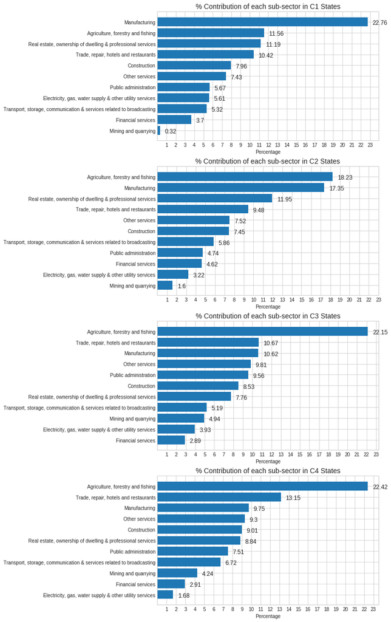

```python
# Plotting subplots for each category:
plt.figure(figsize = (8,22))
plt.style.use('seaborn-whitegrid')

# Category = C1:
plt.subplot(411)
C1 = sub_sectors[(sub_sectors['Category']=='C1') & (sub_sectors['S.No'].isin(['1','2','3','4','5','6',
                                                                              '7','8','9','10','11']))]

C1 = C1.groupby('Sector_x').mean()
C1 = C1.sort_values('% Contribution')
C1 = C1.reset_index()
x_1 = C1['% Contribution']
y_1 = C1['Sector_x']
plt.barh(y_1, x_1)
plt.xticks([1,2,3,4,5,6,7,8,9,10,11,12,13,14,15,16,17,18,19,20,21,22,23])
fonts_1 = {'size' : 12}
fonts = {'size' : 14}
plt.xlabel('Percentage')
plt.title('% Contribution of each sub-sector in C1 States', **fonts)
# Annotate the graph

for i in C1['% Contribution'].index:
    plt.annotate(str(C1['% Contribution'][i].round(2)), (C1['% Contribution'][i] + 0.50, i - 0.25), **fonts_1)




# Category = C2:
plt.subplot(412)
C2 = sub_sectors[(sub_sectors['Category']=='C2') & (sub_sectors['S.No'].isin(['1','2','3','4','5','6',
                                                                              '7','8','9','10','11']))]
C2 = C2.groupby('Sector_x').mean()
C2 = C2.sort_values('% Contribution')
C2 = C2.reset_index()
x_2 = C2['% Contribution']
y_2 = C2['Sector_x']
plt.barh(y_2, x_2)
plt.xticks([1,2,3,4,5,6,7,8,9,10,11,12,13,14,15,16,17,18,19,20,21,22,23])
plt.xlabel('Percentage')
plt.title('% Contribution of each sub-sector in C2 States', **fonts)
# Annotate the graph
for i in C2['% Contribution'].index:
    plt.annotate(str(C2['% Contribution'][i].round(2)), (C2['% Contribution'][i] + 0.50, i - 0.25), **fonts_1)


# Category = C3:
plt.subplot(413)
C3 = sub_sectors[(sub_sectors['Category']=='C3') & (sub_sectors['S.No'].isin(['1','2','3','4','5','6',
                                                                              '7','8','9','10','11']))]
C3 = C3.groupby('Sector_x').mean()
C3 = C3.sort_values('% Contribution')
C3 = C3.reset_index()
x_3 = C3['% Contribution']
y_3 = C3['Sector_x']
plt.barh(y_3, x_3)
plt.xticks([1,2,3,4,5,6,7,8,9,10,11,12,13,14,15,16,17,18,19,20,21,22,23])
plt.xlabel('Percentage')
plt.title('% Contribution of each sub-sector in C3 States', **fonts)
# Annotate the graph
for i in C3['% Contribution'].index:
    plt.annotate(str(C3['% Contribution'][i].round(2)), (C3['% Contribution'][i] + 0.50, i - 0.25), **fonts_1)


# Category = C4:
plt.subplot(414)
C4 = sub_sectors[(sub_sectors['Category']=='C4') & (sub_sectors['S.No'].isin(['1','2','3','4','5','6',
                                                                              '7','8','9','10','11']))]
C4 = C4.groupby('Sector_x').mean()
C4 = C4.sort_values('% Contribution')
C4 = C4.reset_index()
x_4 = C4['% Contribution']
y_4 = C4['Sector_x']
plt.barh(y_4, x_4)
plt.xticks([1,2,3,4,5,6,7,8,9,10,11,12,13,14,15,16,17,18,19,20,21,22,23])
plt.xlabel('Percentage')
plt.title('% Contribution of each sub-sector in C4 States', **fonts)
# Annotate the graph
for i in C4['% Contribution'].index:
    plt.annotate(str(C4['% Contribution'][i].round(2)), (C4['% Contribution'][i] + 0.50, i - 0.25), **fonts_1)
```

#### Top Sub-Sectors that make up for about 80% of the GDP:

[output not shown]

| Category | Sub-Sector | Contribution |  |  | Category | Sub-Sector | Contribution |
| --- | --- | --- | --- | --- | --- | --- | --- |
| C3 | Agriculture | 22.15 |  |  | C4 | Agriculture | 22.42 |
| C3 | Trade | 10.67 |  |  | C4 | Trade | 13.15 |
| C3 | Manufacturing | 10.62 |  |  | C4 | Manufacturing | 9.75 |
| C3 | Other Services | 9.81 |  |  | C4 | Other Services | 9.3 |
| C3 | Public Administration | 9.56 |  |  | C4 | Construction | 9.01 |
| C3 | Construction | 8.53 |  |  | C4 | Real Estate | 8.84 |
| C3 | Real Estate | 7.76 |  |  | C4 | Public Administration | 7.51 |
| **C3** | **Total** | **79%** |  |  | **C4** | **Total** | **80%** |

From the above tables, it is evident that the top sectors remain more or less the same for each category, however their % Contribution differs.  
Manufacuring takes the lead in C1 states whereas Agriculture for the remaining categories. Agriculture and Manufacturing have almost the same contribution for C2 states which shows that the dependency of the population is shifting from agro-based works to blue and white collar jobs.  
Real Estate retains the 3rd spot for both C1 and C2 states since the purchasing power of the population is high.  
It can also be seen that Trade remains one of the main source of income for the poorer states as it is the second highest contributor to the state's GDP in both C3 and C4 states.

The above plot gives a clean picture of how things vary in each of the sectors, but it is really hard to compare the values between each Category. In order to rectify that, let us create a plot which will give us an overview of how each sub-sector varies for each category.

```
Text(3.8,9.75,'3.69')
```

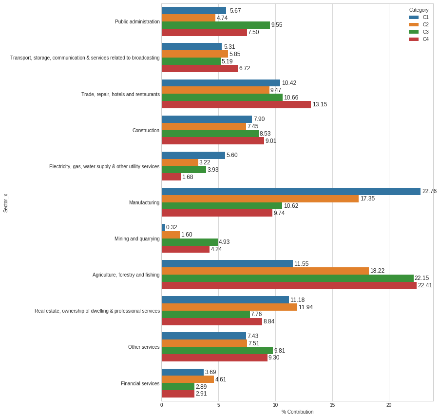

```python
# Since the DataFrame "sub_sectors" contains data for all sub-sectors and within them sub sub-sectors, let
# us filter out only the sub-sectors in the DataFrame:

sub_sectors_only = sub_sectors[sub_sectors['S.No'].isin(['1','2','3','4','5','6','7','8','9','10','11'])]
sub_sectors_only = sub_sectors_only.sort_values('Category')

# Defining the figure size:
plt.figure(figsize = (10,15))

# Making the Barplot:
sns.barplot(sub_sectors_only['% Contribution'], sub_sectors_only['Sector_x'],
            hue = sub_sectors_only['Category'], estimator = np.mean, ci = None)


# Annotating the plot:
fonts = {'size' : 12}

# C4:
plt.annotate('7.50', (7.60, 0.35), **fonts)
plt.annotate('6.72', (6.82, 1.35), **fonts)
plt.annotate('13.15', (13.25, 2.35), **fonts)
plt.annotate('9.01', (9.11, 3.35), **fonts)
plt.annotate('1.68', (1.78, 4.35), **fonts)
plt.annotate('9.74', (9.84, 5.35), **fonts)
plt.annotate('4.24', (4.34, 6.35), **fonts)
plt.annotate('22.41', (22.51, 7.35), **fonts)
plt.annotate('8.84', (8.94, 8.35), **fonts)
plt.annotate('9.30', (9.40, 9.35), **fonts)
plt.annotate('2.91', (3.01, 10.35), **fonts)

# C3:
plt.annotate('9.55', (9.65, 0.15), **fonts)
plt.annotate('5.19', (5.29, 1.15), **fonts)
plt.annotate('10.66', (10.76, 2.15), **fonts)
plt.annotate('8.53', (8.63, 3.15), **fonts)
plt.annotate('3.93', (4.03, 4.15), **fonts)
plt.annotate('10.62', (10.72, 5.15), **fonts)
plt.annotate('4.93', (5.03, 6.15), **fonts)
plt.annotate('22.15', (22.25, 7.15), **fonts)
plt.annotate('7.76', (7.86, 8.15), **fonts)
plt.annotate('9.81', (9.91, 9.15), **fonts)
plt.annotate('2.89', (2.99, 10.15), **fonts)

# C2:
plt.annotate('4.74', (4.84, -0.05), **fonts)
plt.annotate('5.85', (5.95, 0.95), **fonts)
plt.annotate('9.47', (9.57, 1.95), **fonts)
plt.annotate('7.45', (7.55, 2.95), **fonts)
plt.annotate('3.22', (3.32, 3.95), **fonts)
plt.annotate('17.35', (17.45, 4.95), **fonts)
plt.annotate('1.60', (1.70, 5.95), **fonts)
plt.annotate('18.22', (18.32, 6.95), **fonts)
plt.annotate('11.94', (12.04, 7.95), **fonts)
plt.annotate('7.51', (7.61, 8.95), **fonts)
plt.annotate('4.61', (4.71, 9.95), **fonts)


# C1:
plt.annotate('5.67', (6,-0.25), **fonts)
plt.annotate('5.31', (5.5, 0.75), **fonts)
plt.annotate('10.42', (10.55, 1.75), **fonts)
plt.annotate('7.90', (8.1, 2.75), **fonts)
plt.annotate('5.60', (5.70, 3.75), **fonts)
plt.annotate('22.76', (22.90, 4.75), **fonts)
plt.annotate('0.32', (0.40, 5.75), **fonts)
plt.annotate('11.55', (11.65, 6.75), **fonts)
plt.annotate('11.18', (11.30, 7.75), **fonts)
plt.annotate('7.43', (7.53, 8.75), **fonts)
plt.annotate('3.69', (3.80, 9.75), **fonts)
```

### Sectors that the various categories need to focus on:

#### C1:

1. C1 states need to focus on **Transportation and Storage** sector, since transportation acts as the back bone of all the trades that happen in the state. A stronger connectivity would mean that high volumes of trade could occur in much lesser time which will boost the **Trading** sector of not only the C1 states but also the nearby states who could use the enhanced transporation network for their trades. An increase in the storage houses could mean less fluctuation in the prices of agriculture produce (crops), which will help stabilise the states economy and even increase the percentage contribution of the Agricultural sector. Storage houses could help in storing the surplus crops from various nearby states which will be beneficial to the country as a whole.
2. **Financial sevices** need to be focused on by the C1 states. Since they already have a base of population with a decent income, these services could make people invest their savings in the market and help them with their financial planning, which in long term would benefit the country.

**C2:**

1. The contribution for **Trade, Repairs, Hotels and Restaurants** sector is the lowest for C2 than any other category. Policies that favour tourism could help boost the buisness of hotels and resturants. Steps such as ease of doing business will also help immensely in the setting up of new hotels and making Trades. Since Trade depends significantly on the connectivity, construction of roads, rails and airports should be made a priority.
1. **Electricity, Gas, Water Supply and Other Utility Services** :The contribution of this sector is a meagre 3.2% which shows that even in states with comparitively high Per Capita GDP, these basic utilities are still not available to the vast majority.

**C3:**

1. **Manufacturing**: The contibution is around 10.6% which is less than half that of Agriculture (22%). Companies need to be brought in with lucrative deals to set up their businesses in these States. A growth in the Manufacturing sector could mean low rates of unemployment, higher Per Capita GDP, healthier population, good status of living and high purchasing power of the people.
1. **Real Estate, Ownership of Dwelling and Professional Services:** C3 states have the least contribution from this sector. It comes as no surprise because C3 states have a higher population living in Urban areas as compared to Rural. With a lower per capita GDP, this sector will take a hit as people cannot afford to buy their own houses.

**C4:**

1. **Manufacturing:** The contribution in the economy is less than 10% which is less than the percentage contribution made by Trade, Repairs, Hotels and Restaurants sector(13%). These states need to invite companies to set their businesses there, also presenting them with lower tax rates and other benefits could increase the share of this sector dramatically, considering the fact that these are highy populous states with the majority being youth (workforce).
1. **Electricity, Gas, Water Supply and Other Utility Services:** With a contribution less than 2%, this sector needs immediate redressal of the bottlenecks in the schemes introduced by the government.

### Sectors correlated with High GDP:

As seen from the plot above, the *Manufacturing* sector is highly correlated with the GDP of the state. This is because of it being a labour intensive sector.

*Utility services* such as Electricity, Gas and Water are also correlated with higher GDP. This is an indicator of prosperity in the people.

*Real Estate, Ownership of Dwelling and Professional Services* also indicate a higher GDP. This reflects the purchasing power of the state's population.

## Dropout Rates for each State for the year 2014-15

```python
# Loading the dataset:
Dropout_Rates = pd.read_csv('Dropout Rates.csv')
Dropout_Rates
```

|  | Sl. No. | Level of Education - State | Primary - 2012-2013 | Primary - 2014-2015 | Primary - 2014-2015.1 | Upper Primary - 2012-2013 | Upper Primary - 2013-2014 | Upper Primary - 2014-2015 | Secondary - 2012-2013 | Secondary - 2013-2014 | Secondary - 2014-2015 | Senior Secondary - 2012-2013 | Senior Secondary - 2013-2014 | Senior Secondary - 2014-2015 |
| --- | --- | --- | --- | --- | --- | --- | --- | --- | --- | --- | --- | --- | --- | --- |
| 0 | 1 | A & N Islands | 0.68 | 1.21 | 0.51 | 1.23 | 0.51 | 1.69 | 5.56 | 7.20 | 9.870 | 14.14 | 15.87 | 16.93 |
| 1 | 2 | Andhra Pradesh | 3.18 | 4.35 | 6.72 | 3.36 | 3.78 | 5.20 | 12.72 | 12.65 | 15.710 | 0.35 | 11.79 | NaN |
| 2 | 3 | Arunachal Pradesh | 15.16 | 10.89 | 10.82 | 7.47 | 5.59 | 6.71 | 12.93 | 14.49 | 17.110 | 5.11 | 17.07 | 18.42 |
| 3 | 4 | Assam | 6.24 | 7.44 | 15.36 | 7.20 | 7.05 | 10.51 | 26.77 | 30.43 | 27.060 | 4.69 | 7.24 | NaN |
| 4 | 5 | Bihar | NaN | 2.09 | NaN | NaN | 2.98 | 4.08 | 30.14 | 25.33 | 25.900 | NaN | NaN | NaN |
| 5 | 6 | Chandigarh | NaN | NaN | NaN | 0.10 | 1.08 | 0.44 | NaN | NaN | NaN | 13.65 | 11.28 | 10.55 |
| 6 | 7 | Chhatisgarh | 4.14 | 1.42 | 2.91 | 5.42 | 3.80 | 5.85 | 14.86 | 23.41 | 21.260 | NaN | NaN | 2.76 |
| 7 | 8 | Dadra & Nagar Haveli | NaN | 1.57 | 1.47 | 3.38 | 4.13 | 4.02 | 24.41 | 28.59 | 16.770 | 9.65 | 6.24 | 9.47 |
| 8 | 9 | Daman & Diu | NaN | 0.85 | 1.11 | NaN | 3.58 | 3.11 | 11.52 | 19.86 | 32.270 | 1.26 | 9.86 | 40.48 |
| 9 | 10 | Delhi | NaN | NaN | NaN | NaN | 2.78 | 0.76 | 5.32 | 8.90 | 11.810 | 14.47 | 16.25 | 17.32 |
| 10 | 11 | Goa | NaN | 0.20 | 0.73 | NaN | NaN | 0.07 | 7.96 | 9.58 | 11.150 | 11.26 | 13.36 | 13.91 |
| 11 | 12 | Gujarat | 0.74 | 0.76 | 0.89 | 5.20 | 5.55 | 6.41 | 13.55 | 21.61 | 25.040 | 0.46 | 7.83 | 7.04 |
| 12 | 13 | Haryana | 1.29 | 0.41 | 5.61 | 0.46 | 2.55 | 5.81 | 8.98 | 12.51 | 15.890 | NaN | 2.18 | 5.75 |
| 13 | 14 | Himachal Pradesh | 0.45 | 0.46 | 0.64 | 0.51 | 0.78 | 0.87 | 8.37 | 9.09 | 6.070 | 9.02 | 7.07 | 7.41 |
| 14 | 15 | Jammu and Kashmir | 6.30 | 5.46 | 6.79 | 5.52 | 4.30 | 5.44 | 17.33 | 15.36 | 17.280 | 10.66 | 7.64 | 12.65 |
| 15 | 16 | Jharkhand | 7.21 | 6.41 | 5.48 | 5.47 | 7.42 | 8.99 | 18.50 | 23.15 | 24.000 | NaN | NaN | 3.41 |
| 16 | 17 | Karnataka | 2.97 | 2.32 | 2.02 | 5.05 | 2.51 | 3.85 | 39.92 | 27.57 | 26.180 | 15.33 | NaN | 1.96 |
| 17 | 18 | Kerala | NaN | NaN | NaN | NaN | NaN | NaN | 9.45 | 14.46 | 12.320 | NaN | 6.40 | 0.47 |
| 18 | 19 | Lakshadweep | 2.50 | NaN | NaN | 0.29 | 1.86 | 2.78 | 7.68 | 8.03 | 6.763 | 6.59 | 2.82 | 3.12 |
| 19 | 20 | Madhya Pradesh | 6.11 | 10.14 | 6.59 | 8.53 | 11.70 | 9.20 | 13.63 | 26.47 | 24.770 | NaN | 1.55 | NaN |
| 20 | 21 | Maharashtra | 0.97 | 0.55 | 1.26 | 1.74 | 0.61 | 1.79 | 16.20 | 14.47 | 12.870 | 3.20 | 3.34 | 1.83 |
| 21 | 22 | Manipur | 9.86 | 18.00 | 9.66 | 6.06 | 7.02 | 4.20 | 9.75 | 13.81 | 14.380 | 7.93 | 3.20 | NaN |
| 22 | 23 | Meghalaya | 10.14 | 10.34 | 9.46 | 7.85 | 6.84 | 6.52 | 26.03 | 24.75 | 20.520 | NaN | NaN | NaN |
| 23 | 24 | Mizoram | 24.11 | 12.96 | 10.10 | 19.28 | 6.02 | 4.78 | 21.42 | 18.70 | 21.880 | NaN | NaN | 6.91 |
| 24 | 25 | Nagaland | 7.07 | 19.41 | 5.61 | 9.83 | 17.86 | 7.92 | 26.51 | 35.11 | 18.230 | 18.29 | 14.19 | 6.97 |
| 25 | 26 | Odisha | 3.56 | 2.94 | 2.86 | 3.81 | 2.80 | 3.81 | 49.86 | 49.48 | 29.560 | NaN | NaN | NaN |
| 26 | 27 | Puducherry | 0.34 | 0.66 | 0.37 | 0.68 | 0.60 | 0.56 | 15.21 | 14.24 | 12.190 | 5.25 | 11.16 | 4.50 |
| 27 | 28 | Punjab | 1.99 | 1.29 | 3.05 | 2.78 | 2.85 | 3.22 | 9.80 | 8.83 | 8.860 | 8.28 | 5.81 | 5.83 |
| 28 | 29 | Rajasthan | 7.97 | 8.39 | 5.02 | 4.42 | 6.03 | 3.07 | 13.65 | 18.77 | 13.480 | NaN | NaN | NaN |
| 29 | 30 | Sikkim | 3.60 | 4.57 | 2.27 | 3.15 | 5.14 | 1.57 | 9.23 | 12.89 | 15.890 | 8.10 | 12.91 | 11.76 |
| 30 | 31 | Tamil Nadu | 4.06 | 0.46 | NaN | 1.24 | 4.52 | NaN | 10.20 | 12.20 | 8.100 | 1.87 | 4.44 | 3.41 |
| 31 | 32 | Telangana | NaN | 5.81 | 2.08 | NaN | 4.71 | 2.30 | NaN | 17.43 | 15.530 | NaN | 13.43 | 0.77 |
| 32 | 33 | Tripura | 2.22 | 3.58 | 1.28 | 3.08 | 2.72 | 1.99 | 25.50 | 25.09 | 28.420 | 8.87 | 9.11 | 8.93 |
| 33 | 34 | Uttar Pradesh | 10.28 | 7.08 | 8.58 | 1.06 | 0.53 | 2.70 | NaN | 7.30 | 10.220 | NaN | NaN | 2.10 |
| 34 | 35 | Uttrakhand | 1.16 | 3.07 | 4.04 | 0.13 | 1.68 | 1.19 | 9.68 | 8.70 | 10.400 | 1.59 | NaN | 3.01 |
| 35 | 36 | West Bengal | 6.30 | 2.91 | 1.47 | 5.18 | 4.31 | 4.30 | 17.30 | 18.34 | 17.800 | 8.13 | 7.90 | 8.11 |
| 36 | All India | All India | 4.67 | 4.34 | 4.13 | 3.13 | 3.77 | 4.03 | 14.54 | 17.86 | 17.060 | NaN | 1.54 | NaN |

The data contains the level of education for various years as the columns and the stats for each state are recorded in the rows. Since we have conducted the analysis for the year 2014-15 for the GSDP of various states, let us continue with the same years' dropout rates to see if there is any correlation between the two.

```python
# Dropping the columns other than for the year 2014-15:
cols = ['Primary - 2012-2013','Upper Primary - 2012-2013', 'Upper Primary - 2013-2014','Secondary - 2012-2013',
        'Secondary - 2013-2014', 'Senior Secondary - 2012-2013', 'Senior Secondary - 2013-2014']

Dropout_Rates.drop(cols, axis = 'columns', inplace = True)
Dropout_Rates.head()
```

|  | Sl. No. | Level of Education - State | Primary - 2014-2015 | Primary - 2014-2015.1 | Upper Primary - 2014-2015 | Secondary - 2014-2015 | Senior Secondary - 2014-2015 |
| --- | --- | --- | --- | --- | --- | --- | --- |
| 0 | 1 | A & N Islands | 1.21 | 0.51 | 1.69 | 9.87 | 16.93 |
| 1 | 2 | Andhra Pradesh | 4.35 | 6.72 | 5.20 | 15.71 | NaN |
| 2 | 3 | Arunachal Pradesh | 10.89 | 10.82 | 6.71 | 17.11 | 18.42 |
| 3 | 4 | Assam | 7.44 | 15.36 | 10.51 | 27.06 | NaN |
| 4 | 5 | Bihar | 2.09 | NaN | 4.08 | 25.90 | NaN |

As we can see that we have 2 columns for 2014-15 for Primary education. We only need one of them.  
One way to decide that is on the basis of NaN values, the column with the least NaN values will be chosen.

```python
# % of NaN values in each column:
Dropout_Rates.isnull().sum(axis = 0)/len(Dropout_Rates.index) * 100
```

```
Sl. No.                          0.000000
Level of Education - State       0.000000
Primary - 2014-2015             10.810811
Primary - 2014-2015.1           16.216216
Upper Primary - 2014-2015        5.405405
Secondary - 2014-2015            2.702703
Senior Secondary - 2014-2015    24.324324
dtype: float64
```

We can see that the column 'Primary - 2014-2015.1' has a higher %, but let us also see the corresponding States for which the Data is missing. If these are only UT's then we need not be concerned.

```python
Dropout_Rates[Dropout_Rates['Primary - 2014-2015.1'].isnull()]
# 3 of the 6 missing values belong to the UT's
```

|  | Sl. No. | Level of Education - State | Primary - 2014-2015 | Primary - 2014-2015.1 | Upper Primary - 2014-2015 | Secondary - 2014-2015 | Senior Secondary - 2014-2015 |
| --- | --- | --- | --- | --- | --- | --- | --- |
| 4 | 5 | Bihar | 2.09 | NaN | 4.08 | 25.900 | NaN |
| 5 | 6 | Chandigarh | NaN | NaN | 0.44 | NaN | 10.55 |
| 9 | 10 | Delhi | NaN | NaN | 0.76 | 11.810 | 17.32 |
| 17 | 18 | Kerala | NaN | NaN | NaN | 12.320 | 0.47 |
| 18 | 19 | Lakshadweep | NaN | NaN | 2.78 | 6.763 | 3.12 |
| 30 | 31 | Tamil Nadu | 0.46 | NaN | NaN | 8.100 | 3.41 |

```python
# Let us do the same analysis for the other column as well:
Dropout_Rates[Dropout_Rates['Primary - 2014-2015'].isnull()]
# 3 of the 4 missing values are UT's, so we'll go with this one.
```

|  | Sl. No. | Level of Education - State | Primary - 2014-2015 | Primary - 2014-2015.1 | Upper Primary - 2014-2015 | Secondary - 2014-2015 | Senior Secondary - 2014-2015 |
| --- | --- | --- | --- | --- | --- | --- | --- |
| 5 | 6 | Chandigarh | NaN | NaN | 0.44 | NaN | 10.55 |
| 9 | 10 | Delhi | NaN | NaN | 0.76 | 11.810 | 17.32 |
| 17 | 18 | Kerala | NaN | NaN | NaN | 12.320 | 0.47 |
| 18 | 19 | Lakshadweep | NaN | NaN | 2.78 | 6.763 | 3.12 |

As we can see that on further analysis, the column 'Primary - 2014-15' is more suitable because only the Data for the state of Kerala will be lost.

```python
# Dropping the column 'Primary 2014-15.1':
Dropout_Rates.drop('Primary - 2014-2015.1', axis = 'columns', inplace = True)
Dropout_Rates.columns
```

```
Index(['Sl. No.', 'Level of Education - State', 'Primary - 2014-2015',
       'Upper Primary - 2014-2015', 'Secondary - 2014-2015',
       'Senior Secondary - 2014-2015'],
      dtype='object')
```

The dataframe now contains only those columns that we'll need for analysis. However their names are not so appealing. Let us change the column names so something more general and easy to remember.

```python
Dropout_Rates.rename(columns = {'Sl. No.' : 'S.No.',
                               'Level of Education - State' : 'State',
                                'Primary - 2014-2015' : 'Primary',
                               'Upper Primary - 2014-2015' : 'Upper Primary',
                                'Secondary - 2014-2015' : 'Secondary',
                               'Senior Secondary - 2014-2015' : 'Senior Secondary'}, inplace = True)
Dropout_Rates.columns
```

```
Index(['S.No.', 'State', 'Primary', 'Upper Primary', 'Secondary',
       'Senior Secondary'],
      dtype='object')
```

Let us convert the DataFrame to long-format which will make it easy to use.

```python
dropout_rates = pd.melt(Dropout_Rates, id_vars = ['S.No.', 'State'], var_name = 'Education', value_name = 'Dropout Rate')
dropout_rates.head()
```

|  | S.No. | State | Education | Dropout Rate |
| --- | --- | --- | --- | --- |
| 0 | 1 | A & N Islands | Primary | 1.21 |
| 1 | 2 | Andhra Pradesh | Primary | 4.35 |
| 2 | 3 | Arunachal Pradesh | Primary | 10.89 |
| 3 | 4 | Assam | Primary | 7.44 |
| 4 | 5 | Bihar | Primary | 2.09 |

```python
sub_sectors.head()
```

|  | S.No | Sector_x | State | Amount Contributed | Total GDP of State | % Contribution | Category |
| --- | --- | --- | --- | --- | --- | --- | --- |
| 0 | 1 | Agriculture, forestry and fishing | Andhra_Pradesh | 14819416.0 | 52646842.0 | 28.15 | C2 |
| 1 | 1.1 | Crops | Andhra_Pradesh | 7893514.0 | 52646842.0 | 14.99 | C2 |
| 2 | 1.2 | Livestock | Andhra_Pradesh | 4309078.0 | 52646842.0 | 8.18 | C2 |
| 3 | 1.3 | Forestry and logging | Andhra_Pradesh | 346160.0 | 52646842.0 | 0.66 | C2 |
| 4 | 1.4 | Fishing and aquaculture | Andhra_Pradesh | 2270664.0 | 52646842.0 | 4.31 | C2 |

Let us join the above two DataFrames on the column 'State'. This will give us only those states for which we have the GSDP data, also it will filter out all the UT's automatically.

```python
dropout_rates = sub_sectors.merge(dropout_rates, on = 'State', how = 'inner')
dropout_rates.head(10)
```

|  | S.No | Sector_x | State | Amount Contributed | Total GDP of State | % Contribution | Category | S.No. | Education | Dropout Rate |
| --- | --- | --- | --- | --- | --- | --- | --- | --- | --- | --- |
| 0 | 1 | Agriculture, forestry and fishing | Assam | 3855548.0 | 19809800.0 | 19.46 | C4 | 4 | Primary | 7.44 |
| 1 | 1 | Agriculture, forestry and fishing | Assam | 3855548.0 | 19809800.0 | 19.46 | C4 | 4 | Upper Primary | 10.51 |
| 2 | 1 | Agriculture, forestry and fishing | Assam | 3855548.0 | 19809800.0 | 19.46 | C4 | 4 | Secondary | 27.06 |
| 3 | 1 | Agriculture, forestry and fishing | Assam | 3855548.0 | 19809800.0 | 19.46 | C4 | 4 | Senior Secondary | NaN |
| 4 | 1.1 | Crops | Assam | 2890544.0 | 19809800.0 | 14.59 | C4 | 4 | Primary | 7.44 |
| 5 | 1.1 | Crops | Assam | 2890544.0 | 19809800.0 | 14.59 | C4 | 4 | Upper Primary | 10.51 |
| 6 | 1.1 | Crops | Assam | 2890544.0 | 19809800.0 | 14.59 | C4 | 4 | Secondary | 27.06 |
| 7 | 1.1 | Crops | Assam | 2890544.0 | 19809800.0 | 14.59 | C4 | 4 | Senior Secondary | NaN |
| 8 | 1.2 | Livestock | Assam | 173478.0 | 19809800.0 | 0.88 | C4 | 4 | Primary | 7.44 |
| 9 | 1.2 | Livestock | Assam | 173478.0 | 19809800.0 | 0.88 | C4 | 4 | Upper Primary | 10.51 |

The data can now be plotted, but still we can see some irrelevant observations and columns, let us clean it up further before proceeding.

```python
# Dropping unwanted columns:
dropout_rates.drop(['S.No.'], axis = 'columns', inplace = True)

# Renaming column:
dropout_rates.rename(columns = {'Sector_x' : 'Sector'}, inplace = True)

# Filtering out sub sub-sectors (1.1, 1.2 and so on)
dropout_rates = dropout_rates[dropout_rates['S.No'].isin(['1','2','3','4','5','6','7','8','9',
                                                         '10','11'])]
dropout_rates.head()
```

|  | S.No | Sector | State | Amount Contributed | Total GDP of State | % Contribution | Category | Education | Dropout Rate |
| --- | --- | --- | --- | --- | --- | --- | --- | --- | --- |
| 0 | 1 | Agriculture, forestry and fishing | Assam | 3855548.0 | 19809800.0 | 19.46 | C4 | Primary | 7.44 |
| 1 | 1 | Agriculture, forestry and fishing | Assam | 3855548.0 | 19809800.0 | 19.46 | C4 | Upper Primary | 10.51 |
| 2 | 1 | Agriculture, forestry and fishing | Assam | 3855548.0 | 19809800.0 | 19.46 | C4 | Secondary | 27.06 |
| 3 | 1 | Agriculture, forestry and fishing | Assam | 3855548.0 | 19809800.0 | 19.46 | C4 | Senior Secondary | NaN |
| 20 | 2 | Mining and quarrying | Assam | 1471149.0 | 19809800.0 | 7.43 | C4 | Primary | 7.44 |

Let us now proceed with plotting the data:

1. We'll caculate the Average Dropout % for all levels of education across each Category.
2. We'll try to understand the spread of Dropout Rates for each level of education and how it differs across categories.

```python
# Sorting the DataFrame via Category:
dropout_rates = dropout_rates.sort_values('Category')
dropout_rates.head()

# Resetting the index:
dropout_rates = dropout_rates.reset_index(drop = True)
dropout_rates.head()
```

|  | S.No | Sector | State | Amount Contributed | Total GDP of State | % Contribution | Category | Education | Dropout Rate |
| --- | --- | --- | --- | --- | --- | --- | --- | --- | --- |
| 0 | 1 | Agriculture, forestry and fishing | Sikkim | 137447.0 | 1520933.0 | 9.04 | C1 | Primary | 4.57 |
| 1 | 3 | Manufacturing | Kerala | 4273567.0 | 52600230.0 | 8.12 | C1 | Primary | NaN |
| 2 | 2 | Mining and quarrying | Kerala | 558824.0 | 52600230.0 | 1.06 | C1 | Senior Secondary | 0.47 |
| 3 | 2 | Mining and quarrying | Kerala | 558824.0 | 52600230.0 | 1.06 | C1 | Secondary | 12.32 |
| 4 | 2 | Mining and quarrying | Kerala | 558824.0 | 52600230.0 | 1.06 | C1 | Upper Primary | NaN |

```python
# Average Dropout % across categories:
dropout_rates_avg = dropout_rates.groupby(['Category', 'Education']).mean()
dropout_rates_avg
```

| Category | Education | Amount Contributed | Total GDP of State | % Contribution | Dropout Rate |
| --- | --- | --- | --- | --- | --- |
| C1 | Primary | 2.116515e+06 | 25482669.25 | 8.357273 | 1.726667 |
|  | Secondary | 2.116515e+06 | 25482669.25 | 8.357273 | 13.812500 |
|  | Senior Secondary | 2.116515e+06 | 25482669.25 | 8.357273 | 7.972500 |
|  | Upper Primary | 2.116515e+06 | 25482669.25 | 8.357273 | 2.483333 |
| C2 | Primary | 7.299176e+06 | 89762510.40 | 8.213091 | 2.146000 |
|  | Secondary | 7.299176e+06 | 89762510.40 | 8.213091 | 17.696000 |
|  | Senior Secondary | 7.299176e+06 | 89762510.40 | 8.213091 | 3.486000 |
|  | Upper Primary | 7.299176e+06 | 89762510.40 | 8.213091 | 3.514000 |
| C3 | Primary | 1.205712e+06 | 13924854.60 | 8.798000 | 10.936000 |
|  | Secondary | 1.205712e+06 | 13924854.60 | 8.798000 | 20.506000 |
|  | Senior Secondary | 1.205712e+06 | 13924854.60 | 8.798000 | 7.603333 |
|  | Upper Primary | 1.205712e+06 | 13924854.60 | 8.798000 | 4.856000 |
| C4 | Primary | 1.773385e+06 | 20179195.50 | 8.838605 | 8.485000 |
|  | Secondary | 1.773385e+06 | 20179195.50 | 8.838605 | 22.835000 |
|  | Senior Secondary | 1.773385e+06 | 20179195.50 | 8.838605 | 3.410000 |
|  | Upper Primary | 1.773385e+06 | 20179195.50 | 8.838605 | 6.945000 |

```python
# Resettting the index:
dropout_rates_avg = dropout_rates_avg.reset_index()
```

```python
dropout_rates_avg
```

|  | Category | Education | Amount Contributed | Total GDP of State | % Contribution | Dropout Rate |
| --- | --- | --- | --- | --- | --- | --- |
| 0 | C1 | Primary | 2.116515e+06 | 25482669.25 | 8.357273 | 1.726667 |
| 1 | C1 | Secondary | 2.116515e+06 | 25482669.25 | 8.357273 | 13.812500 |
| 2 | C1 | Senior Secondary | 2.116515e+06 | 25482669.25 | 8.357273 | 7.972500 |
| 3 | C1 | Upper Primary | 2.116515e+06 | 25482669.25 | 8.357273 | 2.483333 |
| 4 | C2 | Primary | 7.299176e+06 | 89762510.40 | 8.213091 | 2.146000 |
| 5 | C2 | Secondary | 7.299176e+06 | 89762510.40 | 8.213091 | 17.696000 |
| 6 | C2 | Senior Secondary | 7.299176e+06 | 89762510.40 | 8.213091 | 3.486000 |
| 7 | C2 | Upper Primary | 7.299176e+06 | 89762510.40 | 8.213091 | 3.514000 |
| 8 | C3 | Primary | 1.205712e+06 | 13924854.60 | 8.798000 | 10.936000 |
| 9 | C3 | Secondary | 1.205712e+06 | 13924854.60 | 8.798000 | 20.506000 |
| 10 | C3 | Senior Secondary | 1.205712e+06 | 13924854.60 | 8.798000 | 7.603333 |
| 11 | C3 | Upper Primary | 1.205712e+06 | 13924854.60 | 8.798000 | 4.856000 |
| 12 | C4 | Primary | 1.773385e+06 | 20179195.50 | 8.838605 | 8.485000 |
| 13 | C4 | Secondary | 1.773385e+06 | 20179195.50 | 8.838605 | 22.835000 |
| 14 | C4 | Senior Secondary | 1.773385e+06 | 20179195.50 | 8.838605 | 3.410000 |
| 15 | C4 | Upper Primary | 1.773385e+06 | 20179195.50 | 8.838605 | 6.945000 |

##### Taking a look at the Average of Total Dropout Rates across each Category:

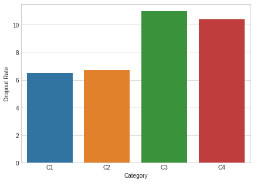

```python
plt.figure(figsize = (7,5))
sns.barplot('Category', 'Dropout Rate', data = dropout_rates_avg, estimator = np.mean, ci = None)
```

Let us now take a look at the Education Level wise Dropout Rates for each Category

```
Text(0.5,1,'Dropout Rates at Various Levels for each Category')
```

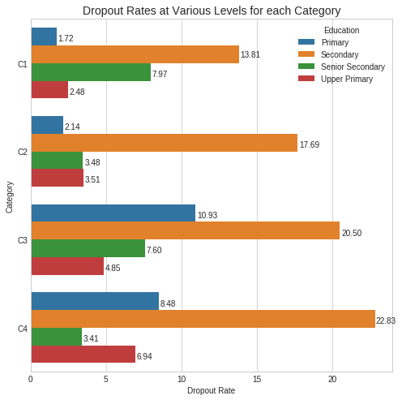

```python
# Let us plot the above data using Barplot:
plt.figure(figsize = (8,8))

sns.barplot('Dropout Rate', 'Category', hue = 'Education', data = dropout_rates_avg,
            estimator = np.mean, ci = None)

# Annotating the plot:
plt.yticks([0,1,2,3])

# C1:
plt.annotate('1.72', (1.82,-0.25))
plt.annotate('13.81', (13.91, -0.07))
plt.annotate('7.97', (8.07, 0.15))
plt.annotate('2.48', (2.58, 0.35))

# C2:
plt.annotate('2.14', (2.24, 0.75))
plt.annotate('17.69', (17.79, 0.95))
plt.annotate('3.48', (3.58, 1.15))
plt.annotate('3.51', (3.61, 1.35))


# C3:
plt.annotate('10.93', (11.03, 1.75))
plt.annotate('20.50', (20.60, 1.95))
plt.annotate('7.60', (7.70, 2.15))
plt.annotate('4.85', (4.95, 2.35))

# C4:
plt.annotate('8.48', (8.58, 2.75))
plt.annotate('22.83', (22.90, 2.95))
plt.annotate('3.41', (3.51, 3.15))
plt.annotate('6.94', (7.04, 3.35))

fonts = {'size' : 14}

plt.title('Dropout Rates at Various Levels for each Category', **fonts)
```

The above plot makes it clear that for each category, the highest percentage of dropouts happen at the **Secondary** level and these rates increase with decreasing Per Capita GDP.

**Primary**: For C3 and C4 states, the % dropout in the Primary schools ranges from 8.5-11%, which means that around 10 out of 100 children belonging to the poorer states do not even get the basic level of education. This severly limits their choice of occupation and their standard of living which further leads to a deadly cycle of poverty and illiteracy.

**Upper Primary**: The increase is steady from C1 to C4 states, but the magnitude is relatively small, which tells us that once the students have made it to the Primary level, they are much less likely to dropout in the Upper Primary level. This further highlights the importance of Primary schooling. Also people dropping out at this level can be considered literate in the sense that they can read and write, which opens up doors for them in terms of job prospects.

**Secondary**: The dropout rates at the secondary level are staggeringly high even in the states with high per capita GDP. With an average of 14 students out of 100 dropping out in the C1 states, the main reason behind this could be the cost of schooling incurred. Although C1 states have a high per capita GDP, the maximum amongst them still figures out around Rs.2.50 lakhs per annum, which is barely sufficient to pay for schooling. The Government schools need to be strengthened and their reputation improved. Lessons should be taken from Delhi where the results of Government schools have improved dramatically, even bypassing the results of the private schools. More money should be alloted to the Education ministry in all states regardless of their category.

### Category wise analysis:

```
Text(0.5,1,'Dropout Rates for Senior Secondary schools')
```

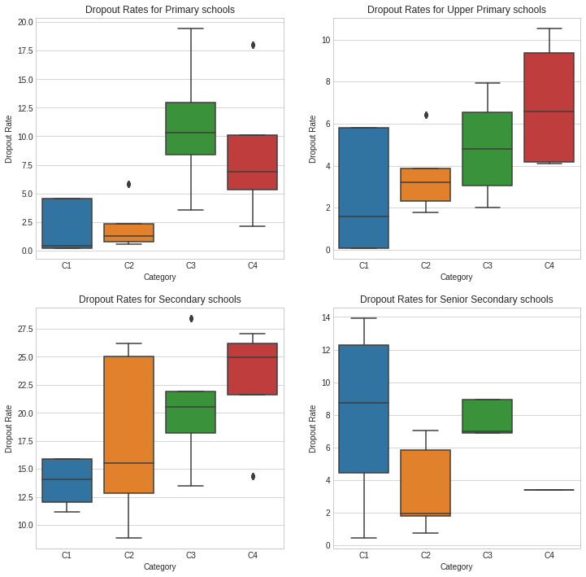

```python
# Spread of Dropout Rates across each level of education:
# For this let us make different DataFrames for each level of education

plt.figure(figsize = (12,12))

# Primary
Primary = dropout_rates[dropout_rates['Education'] == 'Primary']
Primary = Primary.sort_values('Category')

plt.subplot(221)
sns.boxplot('Category','Dropout Rate', data = Primary)
plt.title('Dropout Rates for Primary schools')


# Upper Primary
Upper_Primary = dropout_rates[dropout_rates['Education'] == 'Upper Primary']
Upper_Primary = Upper_Primary.sort_values('Category')

plt.subplot(222)
sns.boxplot('Category','Dropout Rate', data = Upper_Primary)
plt.title('Dropout Rates for Upper Primary schools')


# Secondary
Secondary = dropout_rates[dropout_rates['Education'] == 'Secondary']
Secondary = Secondary.sort_values('Category')

plt.subplot(223)
sns.boxplot('Category','Dropout Rate', data = Secondary)
plt.title('Dropout Rates for Secondary schools')


# Senior Secondary
Senior_Secondary = dropout_rates[dropout_rates['Education'] == 'Senior Secondary']
Senior_Secondary = Senior_Secondary.sort_values('Category')

plt.subplot(224)
sns.boxplot('Category','Dropout Rate', data = Senior_Secondary)
plt.title('Dropout Rates for Senior Secondary schools')
```